# Master Thesis: A Causal Test of the Law of 1/n and its Mechanisms – Analysis: RDD, Normalized Cutoff, Investigating the Heterogeneity

Florian Fox

2022-10-25

# Load data and packages

```r
time <- Sys.time()
library(tidyverse)
library(fixest)
library(rdrobust)
#library(rdmulti)
library(rddensity)
#library(rdd) # For the McCrary (2008) test
#library(xtable)
#library(scales)
#library(janitor)
library(ggpubr)
library(stringr)
source("functions/functions.R")
```

```r
data <-
  readRDS("data/gemeinderatswahlen_alldata.rds") %>%
  filter(year <= 2014) %>%
  mutate(
    year = as.factor(year),
    ags = as.factor(ags)
  ) %>%
  # Repeat (bandwidth) window calculation for data subsets
  mutate(
    closest = base::rank(abs(inhabs_rel_to_cutoff), ties.method = "last"),
    closest = closest/max(closest),
  )
```

Additional functions:

```r
rdrobust_wrapper <- function(ccluster = NULL, ccovs = NULL) {
  rdrobust::rdrobust(
      y = df$ln_gross_expenditure_pc,
      x = df$inhabs_rel_to_cutoff,
      fuzzy = df$total_seats,
      cluster = ccluster,
      covs = ccovs,
      level = (1-p_value_cutoff)*100
  )
}
```

Generating different data sets:

```r
data_by <- data %>% filter(state == 9) %>% # Bavarian data only
  # Repeat (bandwidth) window calculation for data subsets
  mutate(
    closest = base::rank(abs(inhabs_rel_to_cutoff), ties.method = "last"),
    closest = closest/max(closest),
  )
```

# Introduction

Main specification & specification for Bavaria (since some of the data are available for Bavaria only):

```r
df <- data %>%
  select(ln_gross_expenditure_pc, total_seats, inhabs_rel_to_cutoff, above_cutoff, inhabitants_treshold_factor, inhabitants_treshold, year, ags, election_year, state, closest, clean_disc_acc_Höhmann, clean_disc_acc_to_my_research) %>%
  drop_na(ln_gross_expenditure_pc, total_seats, inhabs_rel_to_cutoff)
rdd <-
  rdrobust::rdrobust(
    y = df$ln_gross_expenditure_pc,
    x = df$inhabs_rel_to_cutoff,
    fuzzy = df$total_seats,
    cluster = df$inhabitants_treshold_factor,
    covs = model.matrix( ~ df$inhabitants_treshold_factor + df$year + df$state)
  )
```

```
## [1] "Mass points detected in the running variable."
```

```r
summary(rdd)
```

```
## Covariate-adjusted Fuzzy RD estimates using local polynomial regression.
##
## Number of Obs.               103618
## BW type                       mserd
## Kernel                   Triangular
## VCE method                       NN
##
## Number of Obs.                48578        55040
## Eff. Number of Obs.            7238         7893
## Order est. (p)                    1            1
## Order bias  (q)                   2            2
## BW est. (h)                   0.050        0.050
## BW bias (b)                   0.157        0.157
## rho (h/b)                     0.317        0.317
## Unique Obs.                    3715         4582
##
## First-stage estimates.
##
## =============================================================================
##         Method     Coef. Std. Err.         z     P>|z|      [ 95% C.I. ]
## =============================================================================
##   Conventional     1.242     0.120    10.351     0.000     [1.007 , 1.477]
##         Robust         -         -     9.706     0.000     [0.952 , 1.434]
## =============================================================================
##
## Treatment effect estimates.
##
## =============================================================================
##         Method     Coef. Std. Err.         z     P>|z|      [ 95% C.I. ]
## =============================================================================
##   Conventional     0.014     0.012     1.173     0.241    [-0.010 , 0.038]
##         Robust         -         -     1.222     0.222    [-0.009 , 0.040]
## =============================================================================
```

```r
df <- df %>% filter(state == 9)
rdd <-
  rdrobust::rdrobust(
    y = df$ln_gross_expenditure_pc,
    x = df$inhabs_rel_to_cutoff,
    fuzzy = df$total_seats,
    cluster = df$inhabitants_treshold_factor,
    covs = model.matrix( ~ df$inhabitants_treshold_factor + df$year)
  )
```

```
## [1] "Mass points detected in the running variable."
```

```r
summary(rdd)
```

```
## Covariate-adjusted Fuzzy RD estimates using local polynomial regression.
##
## Number of Obs.                26702
## BW type                       mserd
## Kernel                   Triangular
## VCE method                       NN
##
## Number of Obs.                11475        15227
## Eff. Number of Obs.            1713         1766
## Order est. (p)                    1            1
## Order bias  (q)                   2            2
## BW est. (h)                   0.039        0.039
## BW bias (b)                   0.069        0.069
## rho (h/b)                     0.560        0.560
## Unique Obs.                    1386         1821
##
## First-stage estimates.
##
## =============================================================================
##         Method     Coef. Std. Err.         z     P>|z|      [ 95% C.I. ]
## =============================================================================
##   Conventional     1.992     0.101    19.737     0.000     [1.794 , 2.190]
##         Robust         -         -    17.737     0.000     [1.735 , 2.166]
## =============================================================================
##
## Treatment effect estimates.
##
## =============================================================================
##         Method     Coef. Std. Err.         z     P>|z|      [ 95% C.I. ]
## =============================================================================
##   Conventional    -0.027     0.008    -3.299     0.001    [-0.042 , -0.011]
##         Robust         -         -    -3.126     0.002    [-0.051 , -0.012]
## =============================================================================
```

```r
rm(df, rdd)
```

Unfortunately (for the argumentation), the “Law of 1/n” effect is significantly negative in Bavaria: At the threshold, spending decreases by 2.7 %, significant at $\alpha$ = 0.01.

General remark: I know that lots of the code used here may be improved by wrapper functions and functional programming. However, time constraints led me in some cases to look for the fastest (not the nicest) code idea available.

# Financing the “Law of 1/n”

On to the financing side of the “Law of 1/n”…

Write wrapper function to run `rdrobust` FE RDD model without covariates:

```r
# Not used due to issues with returning values
rdd_bi_fe_model <- function(...) {
  df <- data %>%
    select(..., inhabs_rel_to_cutoff, total_seats, inhabitants_treshold_factor, year, state) %>%
    drop_na()
  rdd <-
    rdrobust::rdrobust(
      y = df %>% pull(y),
      x = df$inhabs_rel_to_cutoff,
      fuzzy = df$total_seats,
      cluster = df$inhabitants_treshold_factor,
      covs = model.matrix( ~ df$inhabitants_treshold_factor + df$year + df$state)
      )
  summary(rdd)
  # out$call <- match.call()
  # class(out) <- "rdrobust"
  # return(out)
}
```

## How is the additional spending financed?

The `gross revenue` variable is coded similarly to the `gross expenditure` variable: In natural logs and per capita.

Taxes at the cutoff:

```r
df <- data %>%
  select(ln_gross_revenue_pc, inhabs_rel_to_cutoff, total_seats, inhabitants_treshold_factor, year, state) %>%
  drop_na()
rdd_h2_taxes <-
  rdrobust::rdrobust(
    y = df$ln_gross_revenue_pc,
    x = df$inhabs_rel_to_cutoff,
    fuzzy = df$total_seats,
    cluster = df$inhabitants_treshold_factor,
    covs = model.matrix( ~ df$inhabitants_treshold_factor + df$year + df$state)
  )
```

```
## [1] "Mass points detected in the running variable."
```

```r
summary(rdd_h2_taxes)
```

```
## Covariate-adjusted Fuzzy RD estimates using local polynomial regression.
##
## Number of Obs.               103613
## BW type                       mserd
## Kernel                   Triangular
## VCE method                       NN
##
## Number of Obs.                48573        55040
## Eff. Number of Obs.            7295         7966
## Order est. (p)                    1            1
## Order bias  (q)                   2            2
## BW est. (h)                   0.050        0.050
## BW bias (b)                   0.159        0.159
## rho (h/b)                     0.315        0.315
## Unique Obs.                    3715         4582
##
## First-stage estimates.
##
## =============================================================================
##         Method     Coef. Std. Err.         z     P>|z|      [ 95% C.I. ]
## =============================================================================
##   Conventional     1.244     0.119    10.443     0.000     [1.010 , 1.477]
##         Robust         -         -     9.790     0.000     [0.956 , 1.434]
## =============================================================================
##
## Treatment effect estimates.
##
## =============================================================================
##         Method     Coef. Std. Err.         z     P>|z|      [ 95% C.I. ]
## =============================================================================
##   Conventional     0.018     0.012     1.404     0.160    [-0.007 , 0.042]
##         Robust         -         -     1.486     0.137    [-0.006 , 0.045]
## =============================================================================
```

```r
rm(df)
```

## If taxes are used to fund the Law, which taxes?

Debt at the cutoff:

```r
df <- data %>%
  select(ln_net_expenditure_pc, inhabs_rel_to_cutoff, total_seats, inhabitants_treshold_factor, year, state) %>%
  drop_na()
rdd_h3_debt <-
  rdrobust::rdrobust(
    y = df$ln_net_expenditure_pc,
    x = df$inhabs_rel_to_cutoff,
    fuzzy = df$total_seats,
    cluster = df$inhabitants_treshold_factor,
    covs = model.matrix( ~ df$inhabitants_treshold_factor + df$year + df$state)
  )
```

```
## [1] "Mass points detected in the running variable."
```

```r
summary(rdd_h3_debt)
```

```
## Covariate-adjusted Fuzzy RD estimates using local polynomial regression.
##
## Number of Obs.               103555
## BW type                       mserd
## Kernel                   Triangular
## VCE method                       NN
##
## Number of Obs.                48532        55023
## Eff. Number of Obs.            7228         7886
## Order est. (p)                    1            1
## Order bias  (q)                   2            2
## BW est. (h)                   0.050        0.050
## BW bias (b)                   0.156        0.156
## rho (h/b)                     0.317        0.317
## Unique Obs.                    3714         4582
##
## First-stage estimates.
##
## =============================================================================
##         Method     Coef. Std. Err.         z     P>|z|      [ 95% C.I. ]
## =============================================================================
##   Conventional     1.242     0.120    10.343     0.000     [1.006 , 1.477]
##         Robust         -         -     9.700     0.000     [0.952 , 1.434]
## =============================================================================
##
## Treatment effect estimates.
##
## =============================================================================
##         Method     Coef. Std. Err.         z     P>|z|      [ 95% C.I. ]
## =============================================================================
##   Conventional     0.019     0.015     1.310     0.190    [-0.010 , 0.048]
##         Robust         -         -     1.369     0.171    [-0.009 , 0.052]
## =============================================================================
```

```r
rm(df)
```

Note that the variable `net_expenditure` is apparently not equal to $gross\_revenue - gross\_expenditure$, correlation is only about 0.34.

## Export table:

```r
rdd_tex_export <- tibble(
  `Dependent variable:` = c("Model", "", "Council size", "", "", "", "Data sample", "Observations", "Bandwidth", "Observations below", "Observations above"),
  `Ln of gross revenue p. c.` = c("FE RDD w/o covariates", "(1)", round(rdd_h2_taxes$Estimate[1], round_decimals), paste0("(", round(rdd_h2_taxes$se[1], round_decimals), ")"), paste0("[", round(rdd_h2_taxes$ci[3,1], 3), ", ", round(rdd_h2_taxes$ci[3,2], 3), "]"), paste0(p_value(rdd_h2_taxes$pv[3]), assign_stars(rdd_h2_taxes$pv[3])), "All data", sum(rdd_h2_taxes$N), round(rdd_h2_taxes$bws[1,1], round_decimals), rdd_h2_taxes$N_h[1], rdd_h2_taxes$N_h[2]),
  `Ln of net expenditure p. c.` = c("FE RDD w/o covariates", "(2)", round(rdd_h3_debt$Estimate[1], round_decimals), paste0("(", round(rdd_h3_debt$se[1], round_decimals), ")"), paste0("[", round(rdd_h3_debt$ci[3,1], 3), ", ", round(rdd_h3_debt$ci[3,2], 3), "]"), paste0(p_value(rdd_h3_debt$pv[3]), assign_stars(rdd_h3_debt$pv[3])), "All data", sum(rdd_h3_debt$N), round(rdd_h3_debt$bws[1,1], round_decimals), rdd_h3_debt$N_h[1], rdd_h3_debt$N_h[2])
  )
rdd_tex_export
```

| Dependent variable: | Ln of gross revenue p. c. | Ln of net expenditure p. c. |
| --- | --- | --- |
| Model | FE RDD w/o covariates | FE RDD w/o covariates |
|  | (1) | (2) |
| Council size | 0.0175 | 0.0194 |
|  | (0.0125) | (0.0148) |
|  | [-0.006, 0.045] | [-0.009, 0.052] |
|  | p=0.14 | p=0.17 |
| Data sample | All data | All data |
| Observations | 103613 | 103555 |
| Bandwidth | 0.0502 | 0.0496 |
| Observations below | 7295 | 7228 |

[output cut: 1 more lines]

```r
print(
  xtable::xtable(
    rdd_tex_export,
    align = "llcc"
    ),
  file = "tables/rdd_rdrobust_financing.tex",
  booktabs = TRUE,
  floating = FALSE,
  hline.after = c(-1, -1, 2, 6, nrow(rdd_tex_export), nrow(rdd_tex_export)),
  include.rownames = FALSE
)
```

```r
rm(rdd_tex_export)
```

## Digression: All revenue categories

Run regressions over all revenue categories:

```r
rev_category <- data %>%
  select(contains("revenue")) %>% # select expenditure categories
  names() # pull their names
rdd_vary_rev_category <- # prepare data set to store the results
  tibble(rev_category = "", point_estimate = "", se = "", se_robust = "",
         ci_lower = "", ci_upper = "", p = "", bw = "", obs_below = "", obs_above = "") %>%
  mutate(across(2:last_col(), as.numeric))
for (i in rev_category) {
  df <- data %>%
    select((!!rlang::sym(i)), inhabs_rel_to_cutoff, total_seats,
           inhabitants_treshold_factor, year, state) %>%
    drop_na()
  rdd <-
    rdrobust::rdrobust(
      y = df %>% pull(i),
      x = df$inhabs_rel_to_cutoff,
      fuzzy = df$total_seats,
      cluster = df$inhabitants_treshold_factor,
      covs = model.matrix(~ df$inhabitants_treshold_factor + df$year + df$state)
    )
  #summary(rdd)
  rdd_vary_rev_category <- rdd_vary_rev_category %>%
    dplyr::add_row(
      rev_category = i,
      point_estimate = rdd$coef[1],
      se = rdd$se[1],
      se_robust = rdd$se[3],
      ci_lower = rdd$ci[3,1],
      ci_upper = rdd$ci[3,2],
      p = rdd$pv[3],
      bw = rdd$bws[1,1],
      obs_below = rdd$N_h[1],
      obs_above = rdd$N_h[2]
  )
}
```

[output not shown]

```r
rdd_vary_rev_category <- rdd_vary_rev_category %>%
  drop_na() %>%
  mutate(
    rev_category2 = c(
      "gross revenue",
      "administrative", "administrative: taxes",
      "administrative: transfers", "administrative: charges & fees",
      "capital", "capital: charges",
      "capital: allocations", "capital: loans",
      "tax: property tax A revenue", "tax: property tax B revenue",
      "tax: business tax", "tax: business tax revenue transfers",
      "tax: business tax revenue net", "tax: wage & income tax"
    )
  )
save(rdd_vary_rev_category, file = "tables_robustness_checks/rdd_vary_rev_category.Rdata")
rm(df)
```

```r
load(file = "tables_robustness_checks/rdd_vary_rev_category.Rdata")
rdd_vary_rev_category
```

| rev_category | point_estimate | se | se_robust | ci_lower | ci_upper | p | bw | obs_below | obs_above | rev_category2 |
| --- | --- | --- | --- | --- | --- | --- | --- | --- | --- | --- |
| ln_gross_revenue_pc | 0.017506122 | 0.012472905 | 0.013020616 | -0.0061751125 | 0.04486477 | 0.1373565218 | 0.05016326 | 7295 | 7966 | gross revenue |
| ln_revenue_administrative_pc | 0.020741746 | 0.011255570 | 0.011841931 | -0.0008805178 | 0.04553900 | 0.0593477906 | 0.04989492 | 7273 | 7933 | administrative |
| ln_revenue_admin_taxes_pc | 0.040913990 | 0.013913879 | 0.014457033 | 0.0162391045 | 0.07290963 | 0.0020476634 | 0.05218133 | 7720 | 8297 | administrative: taxes |
| ln_revenue_admin_transfers_pc | -0.006541298 | 0.026491213 | 0.027300321 | -0.0615440074 | 0.04547129 | 0.7684761694 | 0.05061665 | 7386 | 8013 | administrative: transfers |
| ln_revenue_admin_chargesfees_pc | -0.013237634 | 0.049160075 | 0.051795781 | -0.1191197249 | 0.08391601 | 0.7339831053 | 0.05567041 | 8116 | 8727 | administrative: charges & fees |
| ln_revenue_capital_pc | 0.001775904 | 0.024166906 | 0.025043751 | -0.0467254242 | 0.05144428 | 0.9249406056 | 0.04665437 | 6650 | 7376 | capital |
| ln_revenue_capital_charges_pc | 0.011748372 | 0.009858781 | 0.010638651 | -0.0052430268 | 0.03645972 | 0.1423391094 | 0.17184938 | 20868 | 22041 | capital: charges |
| ln_revenue_capital_allocations_pc | 0.020998123 | 0.030578547 | 0.030908859 | -0.0356608156 | 0.08549969 | 0.4201142406 | 0.05786769 | 7515 | 8243 | capital: allocations |
| ln_revenue_capital_loans_pc | 0.116804898 | 0.038143254 | 0.040611784 | 0.0553360384 | 0.21453130 | 0.0008920663 | 0.07987145 | 4255 | 4741 | capital: loans |
| ln_tax_prop_a_revenue_pc | 0.029268231 | 0.020372920 | 0.021172557 | -0.0096389116 | 0.07335598 | 0.1323989047 | 0.07707744 | 13806 | 14613 | tax: property tax A revenue |

[output cut: 5 more lines]

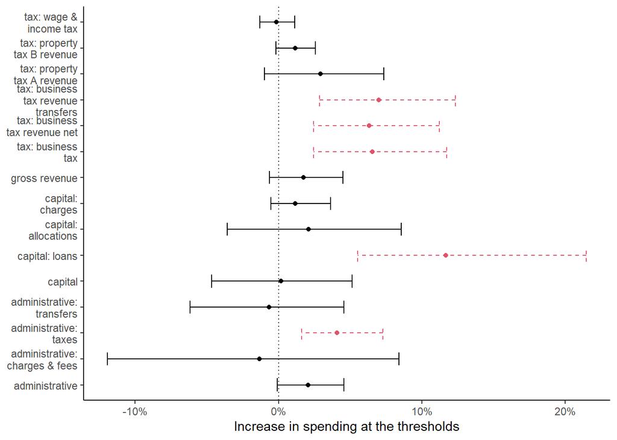

```r
ggplot2::ggplot(data = rdd_vary_rev_category, aes(x = rev_category2, y = point_estimate)) +
  geom_point(size = 1.5, color = ifelse(rdd_vary_rev_category$p <= p_value_cutoff, 2, 1)) +
  geom_errorbar(aes(ymin = ci_lower, ymax = ci_upper),
                color = ifelse(rdd_vary_rev_category$p <= p_value_cutoff, 2, 1),
                linetype = ifelse(rdd_vary_rev_category$p <= p_value_cutoff, 2, 1),
                width = 0.5) +
  geom_hline(aes(yintercept = 0), linetype = "dotted") +
  scale_y_continuous(labels = scales::percent) +
  aes(stringr::str_wrap(rev_category2, 15)) +
  labs(x = NULL, y = y_lab_RDD) +
  coord_flip()
```

```r
ggsave(filename = "plots/rdd_rev_categories.pdf", width = 6, height = 6*9/16)
```

Some suspiciously positive effects for variables related with the local business tax (but probably variables are highly correlated).

IV approach:

```r
df <- data %>%
  filter(closest <= 0.1)
rdd <- fixest::feols(c(ln_gross_revenue_pc, ln_revenue_administrative_pc,
                       ln_revenue_admin_taxes_pc, ln_revenue_admin_transfers_pc,
                       ln_revenue_admin_chargesfees_pc, ln_revenue_capital_pc,
                       ln_revenue_capital_charges_pc, ln_revenue_capital_allocations_pc,
                       ln_revenue_capital_loans_pc, ln_tax_prop_a_revenue_pc,
                       ln_tax_prop_b_revenue_pc, ln_tax_business_revenue_pc,
                       ln_tax_business_revenue_transfers_pc, ln_tax_business_revenue_net_pc,
                       ln_wage__income_tax_revenue_pc) ~
                       1  | # controls
                       inhabitants_treshold_factor + state + year | # fixed-effect controls
                       # First stage regression:
                       inhabs_rel_to_cutoff*total_seats ~ # Instrument our standard RDD...
                       inhabs_rel_to_cutoff*above_cutoff, # ... with being above the cutoff
                     vcov = "threeway",
                     data = df)
summary(rdd)
```

```
## Standard-errors: Clustered (inhabitants_treshold_factor & state & year)
## Dep. var.: ln_gross_revenue_pc
##                                       Estimate Std. Error   t value Pr(>|t|)
## fit_inhabs_rel_to_cutoff              1.006210   4.029090  0.249736  0.80840
## fit_total_seats                       0.013750   0.012441  1.105212  0.29774
## fit_inhabs_rel_to_cutoff:total_seats -0.084012   0.258042 -0.325574  0.75219
## ---
## Dep. var.: ln_revenue_administrative_pc
##                                       Estimate Std. Error   t value Pr(>|t|)
## fit_inhabs_rel_to_cutoff              2.798951   3.293913  0.849734  0.41750
## fit_total_seats                       0.012547   0.008532  1.470670  0.17546
## fit_inhabs_rel_to_cutoff:total_seats -0.198956   0.207729 -0.957765  0.36320
## ---
## Dep. var.: ln_revenue_admin_taxes_pc
##                                       Estimate Std. Error  t value Pr(>|t|)
## fit_inhabs_rel_to_cutoff             -7.568057   4.338140 -1.74454  0.11503
## fit_total_seats                       0.027376   0.020270  1.35058  0.20981
## fit_inhabs_rel_to_cutoff:total_seats  0.399690   0.265936  1.50296  0.16710
## ---
## Dep. var.: ln_revenue_admin_transfers_pc
##                                       Estimate Std. Error   t value Pr(>|t|)
## fit_inhabs_rel_to_cutoff             13.432463  10.146639  1.323834  0.21820
## fit_total_seats                      -0.025282   0.027173 -0.930412  0.37644
## fit_inhabs_rel_to_cutoff:total_seats -0.730311   0.580570 -1.257921  0.24008
## ---
## Dep. var.: ln_revenue_admin_chargesfees_pc
##                                       Estimate Std. Error   t value Pr(>|t|)
## fit_inhabs_rel_to_cutoff              5.889891  15.785561  0.373119  0.71770
## fit_total_seats                       0.010116   0.040402  0.250371  0.80792
## fit_inhabs_rel_to_cutoff:total_seats -0.379238   0.898483 -0.422087  0.68287
## ---
## Dep. var.: ln_revenue_capital_pc
##                                       Estimate Std. Error   t value Pr(>|t|)
## fit_inhabs_rel_to_cutoff              3.565374   9.178929  0.388430  0.70673
## fit_total_seats                       0.009073   0.023648  0.383685  0.71012
## fit_inhabs_rel_to_cutoff:total_seats -0.164185   0.604633 -0.271545  0.79210
## ---
## Dep. var.: ln_revenue_capital_charges_pc
##                                       Estimate Std. Error   t value Pr(>|t|)
## fit_inhabs_rel_to_cutoff              2.744511  16.925756  0.162150  0.87477
```

[output cut: 51 more lines]

```
## Dep. var.: ln_tax_business_revenue_net_pc
##                                        Estimate Std. Error  t value    Pr(>|t|)
## fit_inhabs_rel_to_cutoff             -26.228493   3.337645 -7.85838 0.000013764
## fit_total_seats                        0.080951   0.063416  1.27650 0.230625054
## fit_inhabs_rel_to_cutoff:total_seats   1.418781   0.302777  4.68590 0.000859771
##
## fit_inhabs_rel_to_cutoff             ***
## fit_total_seats
## fit_inhabs_rel_to_cutoff:total_seats ***
## ---
## Dep. var.: ln_wage__income_tax_revenue_pc
##                                        Estimate Std. Error   t value Pr(>|t|)
## fit_inhabs_rel_to_cutoff             -10.181270   7.184374 -1.417141  0.21563
## fit_total_seats                        0.007555   0.010148  0.744472  0.49008
## fit_inhabs_rel_to_cutoff:total_seats   0.603274   0.465589  1.295724  0.25166
```

```r
rm(df, rev_category)
```

Similar conclusions: No effect is singificant at commonly used significance levels, lowest p value: 0.2.

# Testing the Hsu & Shen (2019) heterogeneity test for `inhabitants_treshold`

Functions retrieved from the [authors dropbox](https://www.dropbox.com/sh/hacenzqpop3o15s/AAA-vdgQtgxwkBbundCkL_0Sa) (Hsu & Shen, 2019).

```r
## load in robust bandwidth selection functions from CCT(2014)##
#source("functions/Hsu_Shen_functions/rdbwselect.R")
#source("functions/Hsu_Shen_functions/functions.R")
# load in RD test functions
source("functions/Hsu_Shen_functions/RDHetero_Functions.R")
```

Choose general parameters (for details, see paper):

```r
#nwgrid <- 30
#nbs <- 1000 # = number of bootstraps?
smooth <- 4.5
```

```r
sh_test_df <-
  tibble(regression = "", data_set = "", H0 = "", p = "", bw = "") %>%
  mutate(across(4:last_col(), as.numeric)) %>%
  drop_na
```

Second-stage test (neither reduced-form nor first stage):

```r
df <- data %>% # prepare data set used for analysis
  select(
    ln_gross_expenditure_pc, inhabs_rel_to_cutoff, total_seats,
    inhabitants_treshold, state, year,
    inh_tot, pop_over65, unempl_rate, total_area_ha
    ) %>%
  drop_na()
y <- df %>% pull(ln_gross_expenditure_pc)
x <- df %>% pull(inhabs_rel_to_cutoff)
t <- df %>% pull(total_seats)
w <- df %>% pull(inhabitants_treshold)
n <- length(y)
mrdbw.out <- rdbwselect(y, x, fuzzy = t) # Use standard bw selector, not the IK one as in the paper
```

```
## [1] "Mass points detected in the running variable."
```

```r
bw <- mrdbw.out$bws[1,1]*n^(1/5-1/smooth)
set.seed(123) # to do: remove
results<-RDHeteroTest(y=y,x=x,w=w,bw=bw,t=t)#,nwgrid=nwgrid,nbs=nbs)
# Save results in df
## Generate p values
bscdf_neg <- ecdf(results$stat_neg_bs)
bscdf_pos <- ecdf(results$stat_pos_bs)
bscdf_hetero <- ecdf(results$stat_hetero_bs)
sh_test_df <- sh_test_df %>%
    dplyr::add_row(
      regression = "Full",
      data_set = "All available",
      H0 = c("Uniformly Nonpositive Effect", "Uniformly Nonnegative Effect", "Homogeneous Effect"),
      p = c(1-bscdf_neg(results$stat_neg),
            bscdf_pos(results$stat_pos),
            1-bscdf_hetero(results$stat_hetero)),
      bw = bw
  )
sh_test_df
```

| regression | data_set | H0 | p | bw |
| --- | --- | --- | --- | --- |
| Full | All available | Uniformly Nonpositive Effect | 0.02 | 0.03810797 |
| Full | All available | Uniformly Nonnegative Effect | 1.00 | 0.03810797 |
| Full | All available | Homogeneous Effect | 0.20 | 0.03810797 |

```r
save(sh_test_df, file = "tables_robustness_checks/hsu_shen_het_test.RData")
rm(df, y, x, t, w, n)
```

```r
load(file = "tables_robustness_checks/hsu_shen_het_test.RData")
sh_test_df
```

| regression | data_set | H0 | p | bw |
| --- | --- | --- | --- | --- |
| Full | All available | Uniformly Nonpositive Effect | 0.02 | 0.03810797 |
| Full | All available | Uniformly Nonnegative Effect | 1.00 | 0.03810797 |
| Full | All available | Homogeneous Effect | 0.20 | 0.03810797 |

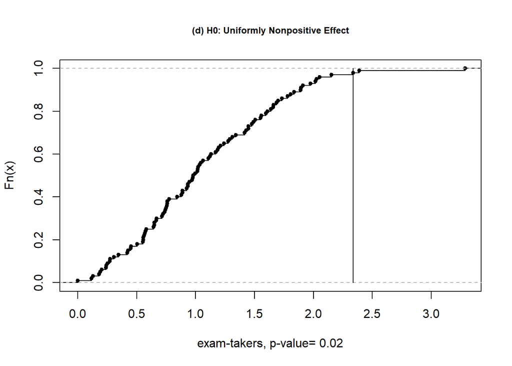

```r
bscdf_neg=ecdf(results$stat_neg_bs)
plot(bscdf_neg, main="(d) H0: Uniformly Nonpositive Effect",xlab=paste("exam-takers, p-value=",as.character(format(1-bscdf_neg(results$stat_neg),sep=""),digits=2)),xlim=c(min(cbind(knots(bscdf_neg),results$stat_neg))-0.02,max(cbind(knots(bscdf_neg),results$stat_neg))+0.002),pch=20,cex.main=0.75)
lines(seq(0,1,0.001)*0+results$stat_neg,seq(0,1,0.001))
```

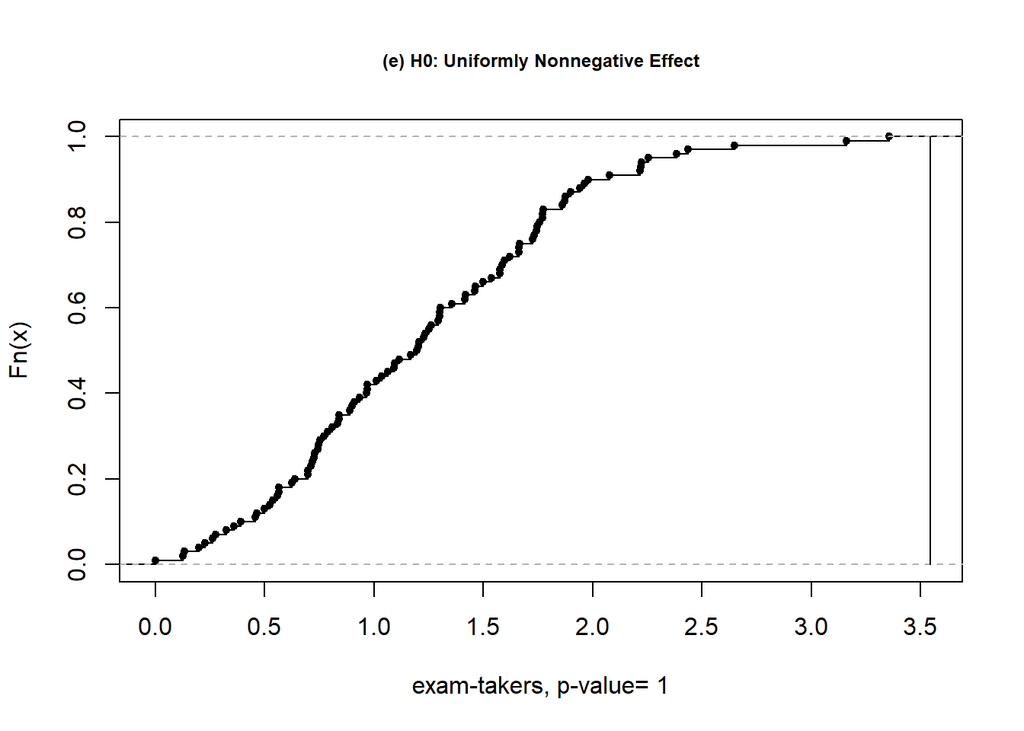

```r
bscdf_pos=ecdf(results$stat_pos_bs)
plot(bscdf_pos, main="(e) H0: Uniformly Nonnegative Effect",xlab=paste("exam-takers, p-value=",as.character(format(bscdf_pos(results$stat_pos),sep=""),digits=2)),xlim=c(min(cbind(knots(bscdf_pos),results$stat_pos))-0.02,max(cbind(knots(bscdf_pos),results$stat_pos))+0.002),pch=20,cex.main=0.75)
lines(seq(0,1,0.001)*0+results$stat_pos,seq(0,1,0.001))
```

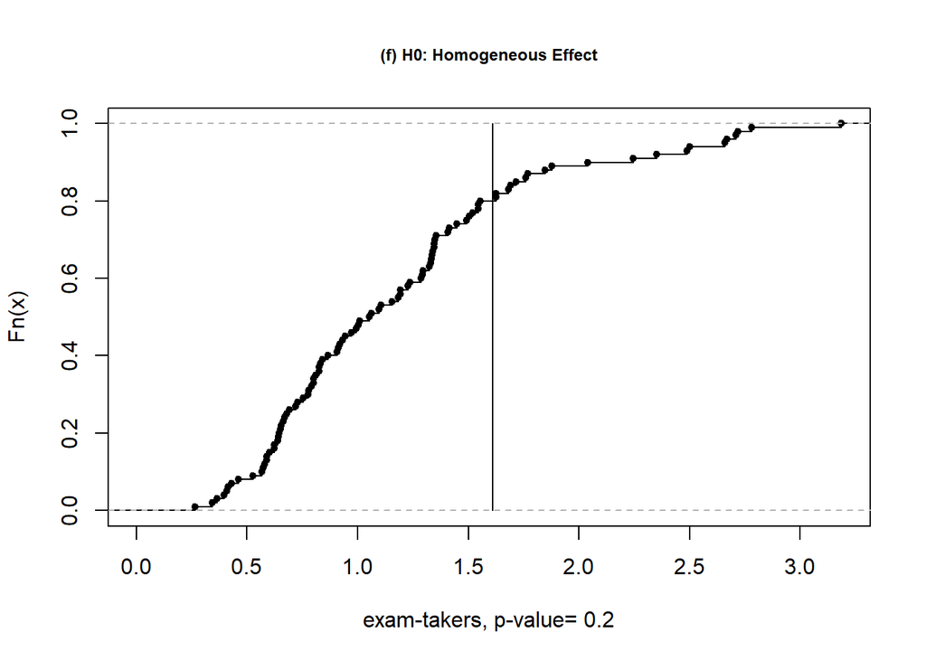

```r
bscdf_hetero=ecdf(results$stat_hetero_bs)
plot(bscdf_hetero, main="(f) H0: Homogeneous Effect",xlab=paste("exam-takers, p-value=",as.character(format(1-bscdf_hetero(results$stat_hetero),sep=""),digits=2)),xlim=c(0,max(cbind(knots(bscdf_hetero),results$stat_hetero))+0.002),pch=20,cex.main=0.75)
lines(seq(0,1,0.001)*0+results$stat_hetero,seq(0,1,0.001))
```

```r
rm(results)
```

However, it appears to me that you cannot include covariates (i. e. fixed effects in this case), rendering the estimation obsolete.

In addition, test results change upon changing the (completely unrelelated) number of variables in the `select()` command above which is puzzling to me.

Reguly’s (2021) code that tests for the exact variables causing the heterogeneity is unfortunately only available for Matlab.

# Variations over states and years

Variation of the “Law of 1/n” between years and states. There are two general methods to detect treatment heterogeneity: The subsample and the interaction methods. While the former can be run in `rdrobust` and hence, is more “state of the art”, only the latter allows for inference, e. g. employing multiple testing.

## Years

Subsample method:

```r
data_year <- data %>% # prepare data set used for analysis
  select(ln_gross_expenditure_pc, inhabs_rel_to_cutoff, total_seats, inhabitants_treshold_factor, state, year) %>%
  drop_na()
all_years <- data_year %>% distinct(year) %>% pull() # vector of years
rdd_vary_year <- # prepare data set to store the results
  tibble(year = "", point_estimate = "", se = "", se_robust = "",
         ci_lower = "", ci_upper = "", p = "", bw = "", obs_below = "", obs_above = "") %>%
  mutate(across(everything(), as.numeric))
for (i in all_years) {
  print(paste("year:", i))
  df <- data_year %>%
    filter(year == i)
  rdd <-
    rdrobust::rdrobust(
      y = df$ln_gross_expenditure_pc,
      x = df$inhabs_rel_to_cutoff,
      fuzzy = df$total_seats,
      cluster = df$inhabitants_treshold_factor,
      covs = model.matrix( ~ df$inhabitants_treshold_factor + df$state), # Dropping year FE, obviously
      level = (1-p_value_cutoff)*100
  )
  #summary(rdd)
  rdd_vary_year <- rdd_vary_year %>%
    dplyr::add_row(
      year = as.numeric(i),
      point_estimate = rdd$coef[1],
      se = rdd$se[1],
      se_robust = rdd$se[3],
      ci_lower = rdd$ci[3,1],
      ci_upper = rdd$ci[3,2],
      p = rdd$pv[3],
      bw = rdd$bws[1,1],
      obs_below = rdd$N_h[1],
      obs_above = rdd$N_h[2]
  )
}
```

```
## [1] "year: 2002"
## [1] "Mass points detected in the running variable."
## [1] "year: 2003"
## [1] "Mass points detected in the running variable."
## [1] "year: 2004"
## [1] "Mass points detected in the running variable."
## [1] "year: 2005"
## [1] "Mass points detected in the running variable."
## [1] "year: 2006"
## [1] "Mass points detected in the running variable."
## [1] "year: 2007"
## [1] "Mass points detected in the running variable."
## [1] "year: 2008"
## [1] "Mass points detected in the running variable."
## [1] "year: 2009"
## [1] "Mass points detected in the running variable."
## [1] "year: 2010"
## [1] "Mass points detected in the running variable."
## [1] "year: 2011"
## [1] "Mass points detected in the running variable."
## [1] "year: 2012"
## [1] "Mass points detected in the running variable."
## [1] "year: 2013"
## [1] "Mass points detected in the running variable."
## [1] "year: 2014"
## [1] "Mass points detected in the running variable."
```

```r
rdd_vary_year <- rdd_vary_year %>% drop_na()
save(rdd_vary_year, file = "tables_robustness_checks/rdd_vary_year.Rdata")
rm(all_years, data_year, df, i, rdd)
```

```r
load(file = "tables_robustness_checks/rdd_vary_year.Rdata")
rdd_vary_year
```

| year | point_estimate | se | se_robust | ci_lower | ci_upper | p | bw | obs_below | obs_above |
| --- | --- | --- | --- | --- | --- | --- | --- | --- | --- |
| 2002 | 0.008609401 | 0.007148842 | 0.007775818 | -0.0112880332 | 0.02877032 | 0.260951572 | 0.12928648 | 1475 | 1525 |
| 2003 | 0.022211433 | 0.014417313 | 0.015859025 | -0.0153255211 | 0.06637476 | 0.107513682 | 0.10276796 | 1296 | 1352 |
| 2004 | 0.006715223 | 0.010683368 | 0.011207730 | -0.0214190755 | 0.03631932 | 0.506222669 | 0.11135253 | 1424 | 1487 |
| 2005 | 0.009743066 | 0.011911535 | 0.013110995 | -0.0214564138 | 0.04608696 | 0.347572263 | 0.09006963 | 1136 | 1219 |
| 2006 | 0.018811410 | 0.014090361 | 0.015440933 | -0.0186669141 | 0.06087950 | 0.171654982 | 0.10692760 | 1359 | 1432 |
| 2007 | 0.005210896 | 0.007532997 | 0.008249527 | -0.0154397271 | 0.02705902 | 0.481283343 | 0.14305313 | 1817 | 1890 |
| 2008 | -0.011480901 | 0.016405370 | 0.018170230 | -0.0596482669 | 0.03395855 | 0.479617623 | 0.07077117 | 836 | 920 |
| 2009 | 0.004948589 | 0.016611220 | 0.017383312 | -0.0378448284 | 0.05170806 | 0.690076536 | 0.08272905 | 941 | 1009 |
| 2010 | 0.028991555 | 0.023402067 | 0.024136972 | -0.0328917599 | 0.09145368 | 0.225085279 | 0.09282188 | 993 | 1010 |
| 2011 | 0.026182479 | 0.034957592 | 0.036649280 | -0.0649144210 | 0.12389016 | 0.421052794 | 0.08623499 | 915 | 938 |

[output cut: 3 more lines]

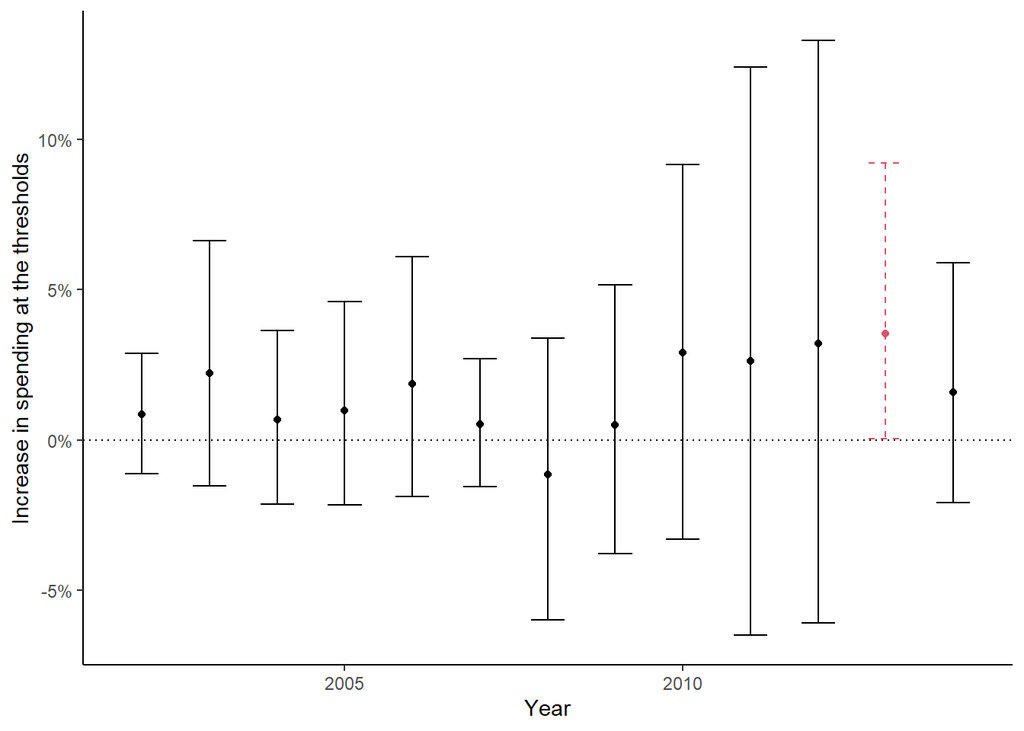

```r
ggplot2::ggplot(data = rdd_vary_year, aes(x = year, y = point_estimate)) +
  geom_point(size = 1.5, color = ifelse(rdd_vary_year$p <= p_value_cutoff, 2, 1)) +
  geom_errorbar(aes(ymin = ci_lower, ymax = ci_upper),
                color = ifelse(rdd_vary_year$p <= p_value_cutoff, 2, 1),
                linetype = ifelse(rdd_vary_year$p <= p_value_cutoff, 2, 1),
                width = 0.5) +
  geom_hline(aes(yintercept = 0), linetype = "dotted") +
  scale_y_continuous(labels = scales::percent) +
  labs(x = "Year", y = y_lab_RDD)
```

For each year: Not much variation in the results here (as expected).

Interaction-term method using the `rdrobust` package – not possible as far as I know:

```r
df <- data %>%
  select(ln_gross_expenditure_pc, inhabs_rel_to_cutoff, total_seats, inhabitants_treshold_factor, state, year) %>%
  drop_na()
rdd <- rdrobust::rdrobust(
      y = df$ln_gross_expenditure_pc,
      x = df$inhabs_rel_to_cutoff : model.matrix( ~ df$year),
      fuzzy = df$total_seats,
      cluster = df$inhabitants_treshold_factor,
      covs = model.matrix( ~ df$inhabitants_treshold_factor + df$state) # Dropping year FE, obviously
  )
summary(rdd)
rm(df)
```

Interaction-term method using an IV approach with `year` included as a factor, not as a numerical variable:

```r
df <- data %>%
  filter(closest <= 0.1)
rdd <- fixest::feols(ln_gross_expenditure_pc ~
                       1  | # controls
                       inhabitants_treshold_factor + state + year | # fixed-effect controls
                       # First stage regression:
                       inhabs_rel_to_cutoff*total_seats ~ # Instrument our standard RDD...
                       inhabs_rel_to_cutoff*above_cutoff, # ... with being above the cutoff
                     vcov = "threeway",
                     data = df)
```

```
## NOTE: 2,600 observations removed because of NA values (LHS: 2,600).
```

```r
summary(rdd)
```

```
## TSLS estimation, Dep. Var.: ln_gross_expenditure_pc, Endo.: inhabs_rel_to_cutoff, total_seats, inhabs_rel_to_cutoff:total_seats, Instr.: inhabs_rel_to_cutoff, above_cutoff, inhabs_rel_to_cutoff:above_cutoff
## Second stage: Dep. Var.: ln_gross_expenditure_pc
## Observations: 12,964
## Fixed-effects: inhabitants_treshold_factor: 30,  state: 10,  year: 13
## Standard-errors: Clustered (inhabitants_treshold_factor & state & year)
##                                       Estimate Std. Error   t value Pr(>|t|)
## fit_inhabs_rel_to_cutoff              1.327991   3.375080  0.393470  0.70313
## fit_total_seats                       0.014107   0.016628  0.848396  0.41821
## fit_inhabs_rel_to_cutoff:total_seats -0.103469   0.216366 -0.478211  0.64390
## ---
## Signif. codes:  0 '***' 0.001 '**' 0.01 '*' 0.05 '.' 0.1 ' ' 1
## RMSE: 0.2941     Adj. R2:  0.435785
##                Within R2: -0.005043
## F-test (1st stage), inhabs_rel_to_cutoff            : stat =      1.503e+33, p < 2.2e-16, on 3 and 12,960 DoF.
## F-test (1st stage), total_seats                     : stat =  1,392.8      , p < 2.2e-16, on 3 and 12,960 DoF.
## F-test (1st stage), inhabs_rel_to_cutoff:total_seats: stat = 18,411.7      , p < 2.2e-16, on 3 and 12,960 DoF.
##                                           Wu-Hausman: stat =     NA        , p = NA     , on 3 and 12,907 DoF.
```

```r
rdd <- fixest::feols(ln_gross_expenditure_pc ~
                       1  | # controls
                       inhabitants_treshold_factor + state | # fixed-effect controls
                       # First stage regression:
                       inhabs_rel_to_cutoff*total_seats*year ~ # Instrument our standard RDD...
                       inhabs_rel_to_cutoff*above_cutoff*year, # ... with being above the cutoff
                     vcov = "twoway",
                     data = df)
```

```
## NOTE: 2,600 observations removed because of NA values (LHS: 2,600).
```

```
## Variance contained negative values in the diagonal and was 'fixed' (a la Cameron, Gelbach & Miller 2011).
## Variance contained negative values in the diagonal and was 'fixed' (a la Cameron, Gelbach & Miller 2011).
## Variance contained negative values in the diagonal and was 'fixed' (a la Cameron, Gelbach & Miller 2011).
## Variance contained negative values in the diagonal and was 'fixed' (a la Cameron, Gelbach & Miller 2011).
## Variance contained negative values in the diagonal and was 'fixed' (a la Cameron, Gelbach & Miller 2011).
## Variance contained negative values in the diagonal and was 'fixed' (a la Cameron, Gelbach & Miller 2011).
## Variance contained negative values in the diagonal and was 'fixed' (a la Cameron, Gelbach & Miller 2011).
```

```r
summary(rdd)
```

```
## TSLS estimation, Dep. Var.: ln_gross_expenditure_pc, Endo.: inhabs_rel_to_cutoff, total_seats, year, inhabs_rel_to_cutoff:total_seats, inhabs_rel_to_cutoff:year, total_seats:year, inhabs_rel_to_cutoff:total_seats:year, Instr.: inhabs_rel_to_cutoff, above_cutoff, year, inhabs_rel_to_cutoff:above_c…
## Second stage: Dep. Var.: ln_gross_expenditure_pc
## Observations: 12,964
## Fixed-effects: inhabitants_treshold_factor: 30,  state: 10
## Standard-errors: Clustered (inhabitants_treshold_factor & state)
##                                                 Estimate Std. Error   t value
## fit_inhabs_rel_to_cutoff                        8.594406   7.743526  1.109883
## fit_total_seats                                 0.020971   0.068017  0.308315
## fit_year2003                                   -0.249333   0.791614 -0.314968
## fit_year2004                                   -0.076621   1.071150 -0.071532
## fit_year2005                                    0.107895   1.119209  0.096403
## fit_year2006                                   -0.086172   1.125359 -0.076573
## fit_year2007                                    0.082527   1.119293  0.073731
## fit_year2008                                    0.550350   1.176732  0.467693
## fit_year2009                                    0.503495   1.009243  0.498884
## fit_year2010                                    0.391421   0.863945  0.453062
## fit_year2011                                    0.292577   1.061054  0.275741
## fit_year2012                                    0.212712   1.069050  0.198973
## fit_year2013                                    0.143524   0.841363  0.170585
## fit_year2014                                    0.341454   1.381985  0.247075
## fit_inhabs_rel_to_cutoff:total_seats           -0.541816   0.340827 -1.589709
## fit_inhabs_rel_to_cutoff:year2003             -16.615898   3.083189 -5.389192
## fit_inhabs_rel_to_cutoff:year2004             -16.449160  17.789893 -0.924635
## fit_inhabs_rel_to_cutoff:year2005             -14.502801  10.228786 -1.417842
## fit_inhabs_rel_to_cutoff:year2006              -7.856899  13.471377 -0.583229
## fit_inhabs_rel_to_cutoff:year2007              -8.081658  11.841537 -0.682484
## fit_inhabs_rel_to_cutoff:year2008              -4.101713   8.651606 -0.474098
## fit_inhabs_rel_to_cutoff:year2009              -8.271408   3.709699 -2.229671
## fit_inhabs_rel_to_cutoff:year2010              -1.065233  11.954828 -0.089105
## fit_inhabs_rel_to_cutoff:year2011              -9.799009  12.934145 -0.757608
## fit_inhabs_rel_to_cutoff:year2012              -5.804636  12.975744 -0.447345
## fit_inhabs_rel_to_cutoff:year2013              -5.169109  12.146623 -0.425559
## fit_inhabs_rel_to_cutoff:year2014              -9.068352  22.345582 -0.405823
## fit_total_seats:year2003                        0.012457   0.045528  0.273602
## fit_total_seats:year2004                        0.000665   0.061137  0.010883
## fit_total_seats:year2005                       -0.010897   0.063401 -0.171868
## fit_total_seats:year2006                        0.003474   0.064075  0.054217
## fit_total_seats:year2007                       -0.005531   0.062831 -0.088038
## fit_total_seats:year2008                       -0.032025   0.066376 -0.482474
## fit_total_seats:year2009                       -0.028957   0.060451 -0.479023
```

[output cut: 110 more lines]

```
## F-test (1st stage), total_seats:year2013                     : stat = 1,214.8      , p < 2.2e-16, on 51 and 12,912 DoF.
## F-test (1st stage), total_seats:year2014                     : stat = 1,312.3      , p < 2.2e-16, on 51 and 12,912 DoF.
## F-test (1st stage), inhabs_rel_to_cutoff:total_seats:year2003: stat =   857.2      , p < 2.2e-16, on 51 and 12,912 DoF.
## F-test (1st stage), inhabs_rel_to_cutoff:total_seats:year2004: stat =   863.4      , p < 2.2e-16, on 51 and 12,912 DoF.
## F-test (1st stage), inhabs_rel_to_cutoff:total_seats:year2005: stat =   863.4      , p < 2.2e-16, on 51 and 12,912 DoF.
## F-test (1st stage), inhabs_rel_to_cutoff:total_seats:year2006: stat =   868.3      , p < 2.2e-16, on 51 and 12,912 DoF.
## F-test (1st stage), inhabs_rel_to_cutoff:total_seats:year2007: stat =   868.2      , p < 2.2e-16, on 51 and 12,912 DoF.
## F-test (1st stage), inhabs_rel_to_cutoff:total_seats:year2008: stat =   834.4      , p < 2.2e-16, on 51 and 12,912 DoF.
## F-test (1st stage), inhabs_rel_to_cutoff:total_seats:year2009: stat = 1,113.8      , p < 2.2e-16, on 51 and 12,912 DoF.
## F-test (1st stage), inhabs_rel_to_cutoff:total_seats:year2010: stat = 1,150.1      , p < 2.2e-16, on 51 and 12,912 DoF.
## F-test (1st stage), inhabs_rel_to_cutoff:total_seats:year2011: stat = 1,117.3      , p < 2.2e-16, on 51 and 12,912 DoF.
## F-test (1st stage), inhabs_rel_to_cutoff:total_seats:year2012: stat = 1,118.5      , p < 2.2e-16, on 51 and 12,912 DoF.
## F-test (1st stage), inhabs_rel_to_cutoff:total_seats:year2013: stat = 1,125.1      , p < 2.2e-16, on 51 and 12,912 DoF.
## F-test (1st stage), inhabs_rel_to_cutoff:total_seats:year2014: stat = 1,318.8      , p < 2.2e-16, on 51 and 12,912 DoF.
##                                                    Wu-Hausman: stat =    NA        , p = NA     , on 51 and 12,823 DoF.
```

```r
# joint test on interactions
fixest::wald(rdd, "fit_total_seats:year")
```

```
## Wald test, H0: joint nullity of fit_total_seats:year2003, fit_total_seats:year2004, fit_total_seats:year2005, fit_total_seats:year2006, fit_total_seats:year2007, fit_total_seats:year2008 and 6 others
##  stat = 0.600824, p-value = 0.843383, on 12 and 12,874 DoF, VCOV: Clustered (inhabitants_treshold_factor & state).
```

```r
#rm(df)
```

The joint test confirms what we saw above: No deviations from baseline treatment effect in 2002.

## States

Subsample method, fuzzy RDD:

```r
data_state <- data %>% # prepare data set used for analysis
  select(ln_gross_expenditure_pc, inhabs_rel_to_cutoff, total_seats, inhabitants_treshold_factor, state, year) %>%
  drop_na()
all_states <- data_state %>% distinct(state) %>% filter(state != "15") %>% pull() # vector of states
rdd_vary_states <- # prepare data set to store the results
  tibble(state = "", point_estimate = "", se = "", se_robust = "",
         ci_lower = "", ci_upper = "", p = "", bw = "", obs_below = "", obs_above = "",
         stage = "") %>%
  mutate(across(1:last_col(), as.numeric))
for (i in all_states) {
  print(paste("state:", i))
  df <- data_state %>%
    filter(state == i)
  rdd <-
    rdrobust::rdrobust(
      y = df$ln_gross_expenditure_pc,
      x = df$inhabs_rel_to_cutoff,
      fuzzy = df$total_seats,
      cluster = df$inhabitants_treshold_factor,
      covs = model.matrix( ~ df$inhabitants_treshold_factor + df$year), # Dropping state FE, obviously
      level = (1-p_value_cutoff)*100
  )
  #summary(rdd)
  rdd_vary_states <- rdd_vary_states %>%
    dplyr::add_row(
      state = i,
      point_estimate = rdd$coef[1],
      se = rdd$se[1],
      se_robust = rdd$se[3],
      ci_lower = rdd$ci[3,1],
      ci_upper = rdd$ci[3,2],
      p = rdd$pv[3],
      bw = rdd$bws[1,1],
      obs_below = rdd$N_h[1],
      obs_above = rdd$N_h[2],
      stage = 2
      ) %>%
    dplyr::add_row(
      state = i,
      point_estimate = rdd$tau_T[1],
      se = rdd$se_T[1],
      se_robust = rdd$se_T[3],
      ci_lower = rdd$ci_T[3,1],
      ci_upper = rdd$ci_T[3,2],
      p = rdd$pv_T[3],
      bw = rdd$bws[1,1],
      obs_below = rdd$N_h[1],
      obs_above = rdd$N_h[2],
      stage = 1
    )
}
```

```
## [1] "state: 1"
## [1] "Mass points detected in the running variable."
## [1] "state: 5"
## [1] "Mass points detected in the running variable."
## [1] "state: 6"
## [1] "Mass points detected in the running variable."
## [1] "state: 7"
## [1] "Mass points detected in the running variable."
## [1] "state: 8"
## [1] "Mass points detected in the running variable."
## [1] "state: 9"
## [1] "Mass points detected in the running variable."
## [1] "state: 10"
## [1] "Mass points detected in the running variable."
## [1] "state: 13"
## [1] "Mass points detected in the running variable."
## [1] "state: 14"
## [1] "Mass points detected in the running variable."
## [1] "state: 16"
## [1] "Mass points detected in the running variable."
```

```r
rdd_vary_states <- rdd_vary_states %>% drop_na() %>% mutate(method = "fuzzy")
save(rdd_vary_states, file = "tables_robustness_checks/rdd_vary_states.Rdata")
rm(all_states, df, i, rdd)
```

```r
load(file = "tables_robustness_checks/rdd_vary_states.Rdata")
# First stage:
rdd_vary_states %>% filter(stage == 1, method == "fuzzy")
```

| state | point_estimate | se | se_robust | ci_lower | ci_upper | p | bw | obs_below | obs_above | stage | method |
| --- | --- | --- | --- | --- | --- | --- | --- | --- | --- | --- | --- |
| 1 | 2.23494710 | 0.07982529 | 0.08623649 | 1.98835900 | 2.4326199 | 6.562667e-145 | 0.06803028 | 844 | 1002 | 1 | fuzzy |
| 5 | 2.78139631 | 0.21230944 | 0.20627394 | 2.02969798 | 3.0923509 | 2.149418e-35 | 0.08287116 | 400 | 357 | 1 | fuzzy |
| 6 | 3.97560022 | 0.15679598 | 0.16976526 | 3.69540702 | 4.5699797 | 6.780702e-131 | 0.03235576 | 274 | 276 | 1 | fuzzy |
| 7 | 1.01846988 | 0.07092430 | 0.07198006 | 0.70988527 | 1.0807019 | 1.623622e-35 | 0.07782501 | 3032 | 2987 | 1 | fuzzy |
| 8 | 0.56275380 | 0.11377912 | 0.13204222 | 0.18527929 | 0.8655157 | 6.920239e-05 | 0.12169422 | 2859 | 3132 | 1 | fuzzy |
| 9 | 1.99206176 | 0.10093161 | 0.10996903 | 1.66723414 | 2.2337571 | 2.181128e-70 | 0.03869122 | 1713 | 1766 | 1 | fuzzy |
| 10 | 13.82766001 | 12.96104090 | 14.06240437 | -23.57837229 | 48.8663342 | 3.685815e-01 | 0.02246867 | 7 | 11 | 1 | fuzzy |
| 13 | 2.34155425 | 0.70557448 | 0.90597898 | 0.05233125 | 4.7196257 | 8.448709e-03 | 0.08777774 | 19 | 11 | 1 | fuzzy |
| 14 | 0.08355839 | 0.20603338 | 0.29809067 | -0.96947196 | 0.5661894 | 4.987596e-01 | 0.05183320 | 455 | 432 | 1 | fuzzy |
| 16 | 2.24337068 | 0.16680719 | 0.17008473 | 1.70736083 | 2.5835793 | 1.765066e-36 | 0.13775806 | 1132 | 1366 | 1 | fuzzy |

```r
# Second stage:
rdd_vary_states %>% filter(stage == 2, method == "fuzzy")
```

| state | point_estimate | se | se_robust | ci_lower | ci_upper | p | bw | obs_below | obs_above | stage | method |
| --- | --- | --- | --- | --- | --- | --- | --- | --- | --- | --- | --- |
| 1 | 0.01150505 | 0.009302821 | 0.009914922 | -0.010353755 | 0.040724538 | 1.256287e-01 | 0.06803028 | 844 | 1002 | 2 | fuzzy |
| 5 | 0.03596935 | 0.009126165 | 0.009871621 | 0.021083224 | 0.071938445 | 2.458154e-06 | 0.08287116 | 400 | 357 | 2 | fuzzy |
| 6 | 0.01600214 | 0.001688026 | 0.001765708 | 0.013636220 | 0.022732544 | 7.146719e-25 | 0.03235576 | 274 | 276 | 2 | fuzzy |
| 7 | 0.00259504 | 0.018981217 | 0.020295356 | -0.051153126 | 0.053401621 | 9.558243e-01 | 0.07782501 | 3032 | 2987 | 2 | fuzzy |
| 8 | 0.05811068 | 0.022499485 | 0.026169666 | -0.002974115 | 0.131843073 | 1.380946e-02 | 0.12169422 | 2859 | 3132 | 2 | fuzzy |
| 9 | -0.02654089 | 0.008045517 | 0.010064043 | -0.057378740 | -0.005532224 | 1.774842e-03 | 0.03869122 | 1713 | 1766 | 2 | fuzzy |
| 10 | 0.13211768 | 0.052091999 | 0.056706631 | -0.018113208 | 0.274019997 | 2.404498e-02 | 0.02246867 | 7 | 11 | 2 | fuzzy |
| 13 | -0.05459531 | 0.037196520 | 0.043725141 | -0.158300491 | 0.066956511 | 2.962427e-01 | 0.08777774 | 19 | 11 | 2 | fuzzy |
| 14 | 0.25910011 | 0.635352293 | 0.931849947 | -1.203147606 | 3.597425194 | 1.989005e-01 | 0.05183320 | 455 | 432 | 2 | fuzzy |
| 16 | 0.01081566 | 0.014346250 | 0.016663416 | -0.032929532 | 0.052914696 | 5.487249e-01 | 0.13775806 | 1132 | 1366 | 2 | fuzzy |

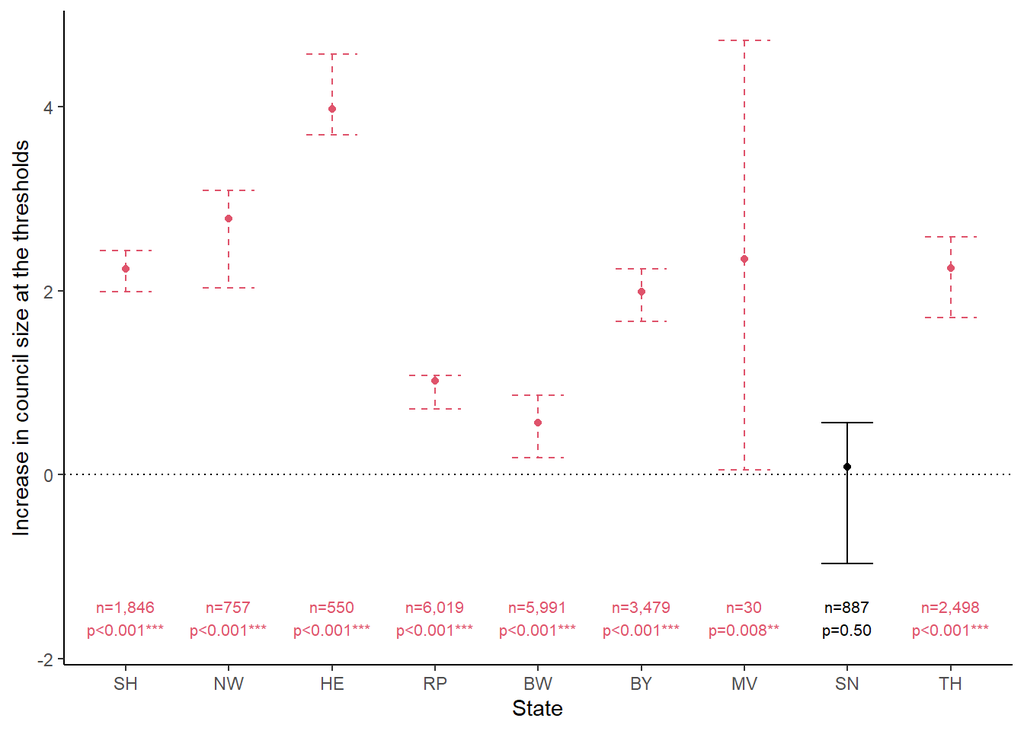

```r
# First stage
df <- rdd_vary_states %>%
  filter(state != 10, stage == 1) %>% # CIs too large
  mutate(state_name = case_when(
    state == 1 ~ "SH",
    state == 5 ~ "NW",
    state == 6 ~ "HE",
    state == 7 ~ "RP",
    state == 8 ~ "BW",
    state == 9 ~ "BY",
    state == 10 ~ "SL",
    state == 13 ~ "MV",
    state == 14 ~ "SN",
    state == 16 ~ "TH"
  ),
  state_name = fct_reorder(state_name, state)) %>%
  rowwise() %>%
  mutate(note = paste0(
    "n=",
    trimws(format(sum(obs_below, obs_above), big.mark = ",")),
    "\n",
    p_value(p),
    assign_stars(p)
    )) %>%
  ungroup()
plot_states_fuzzy1 <- ggplot2::ggplot(data = df, aes(x = state_name, y = point_estimate)) +
  geom_point(size = 1.5, color = ifelse(df$p <= p_value_cutoff, 2, 1)) +
  geom_errorbar(aes(ymin = ci_lower, ymax = ci_upper),
                color = ifelse(df$p <= p_value_cutoff, 2, 1),
                linetype = ifelse(df$p <= p_value_cutoff, 2, 1),
                width = 0.5) +
  geom_text(aes(y = -1.75, label = note),
            colour = ifelse(df$p <= p_value_cutoff, 2, 1), vjust = 0, size = 2.8) +
  geom_hline(aes(yintercept = 0), linetype = "dotted") +
  labs(x = "State", y = "Increase in council size at the thresholds")
plot_states_fuzzy1
```

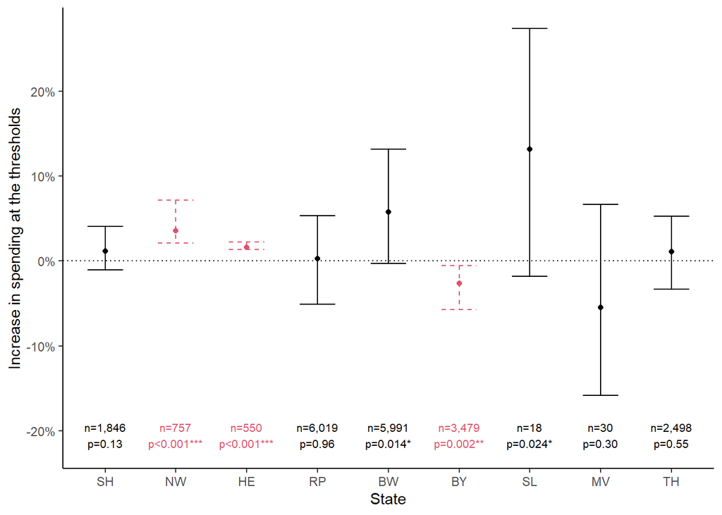

```r
ggsave(filename = "plots/rdd_states_fuzzy1.pdf", width = 6, height = 6*9/16)
# Second stage
df <- rdd_vary_states %>%
  filter(state != 14, stage == 2) %>% # CIs too large
  mutate(state_name = case_when(
    state == 1 ~ "SH",
    state == 5 ~ "NW",
    state == 6 ~ "HE",
    state == 7 ~ "RP",
    state == 8 ~ "BW",
    state == 9 ~ "BY",
    state == 10 ~ "SL",
    state == 13 ~ "MV",
    state == 16 ~ "TH"
  ),
  state_name = fct_reorder(state_name, state)) %>%
  rowwise() %>%
  mutate(note = paste0(
    "n=",
    trimws(format(sum(obs_below, obs_above), big.mark = ",")),
    "\n",
    p_value(p),
    assign_stars(p)
    )) %>%
  ungroup()
plot_states_fuzzy2 <- ggplot2::ggplot(data = df, aes(x = state_name, y = point_estimate)) +
  geom_point(size = 1.5, color = ifelse(df$p <= p_value_cutoff, 2, 1)) +
  geom_errorbar(aes(ymin = ci_lower, ymax = ci_upper),
                color = ifelse(df$p <= p_value_cutoff, 2, 1),
                linetype = ifelse(df$p <= p_value_cutoff, 2, 1),
                width = 0.5) +
  geom_text(aes(y = -0.22, label = note),
            colour = ifelse(df$p <= p_value_cutoff, 2, 1), vjust = 0, size = 2.8) +
  geom_hline(aes(yintercept = 0), linetype = "dotted") +
  scale_y_continuous(labels = scales::percent) +
  labs(x = "State", y = y_lab_RDD)
plot_states_fuzzy2
```

```r
ggsave(filename = "plots/rdd_states_fuzzy2.pdf", width = 6, height = 6*9/16)
rm(df)
```

First stage: State 10 removed due to large confidence bands.

Second stage: State 14’s (SN) CIs are too large, state `15` produces an error. Hence, both are excluded.

Subsample method, sharp approach (only possible for a subset of states):

```r
data_state <- data %>% # prepare data set used for analysis
  select(ln_gross_expenditure_pc, inhabs_rel_to_cutoff, total_seats, inhabitants_treshold_factor, state, year) %>%
  drop_na()
all_states <- data_state %>% distinct(state) %>% filter(state %in% c(7, 9, 10, 16)) %>% pull() # vector of states
```

```r
# rdd_vary_states <- # prepare data set to store the results
#   tibble(state = "", point_estimate = "", se = "", se_robust = "",
#          ci_lower = "", ci_upper = "", p = "", bw = "", obs_below = "", obs_above = "",
#          stage = "") %>%
#   mutate(across(1:last_col(), as.numeric))
for (i in all_states) {
  print(paste("state:", i))
  df <- data_state %>%
    filter(state == i)
  rdd <-
    rdrobust::rdrobust(
      y = df$ln_gross_expenditure_pc,
      x = df$inhabs_rel_to_cutoff,
      cluster = df$inhabitants_treshold_factor,
      covs = model.matrix( ~ df$inhabitants_treshold_factor + df$year), # Dropping state FE, obviously
      level = (1-p_value_cutoff)*100
  )
  #summary(rdd)
  rdd_vary_states <- rdd_vary_states %>%
    dplyr::add_row(
      state = i,
      point_estimate = rdd$coef[1],
      se = rdd$se[1],
      se_robust = rdd$se[3],
      ci_lower = rdd$ci[3,1],
      ci_upper = rdd$ci[3,2],
      p = rdd$pv[3],
      bw = rdd$bws[1,1],
      obs_below = rdd$N_h[1],
      obs_above = rdd$N_h[2],
      method = "sharp"
      )
}
```

```
## [1] "state: 7"
## [1] "Mass points detected in the running variable."
## [1] "state: 9"
## [1] "Mass points detected in the running variable."
## [1] "state: 10"
## [1] "Mass points detected in the running variable."
## [1] "state: 16"
## [1] "Mass points detected in the running variable."
```

```r
rdd_vary_states <- rdd_vary_states %>% drop_na(state)
save(rdd_vary_states, file = "tables_robustness_checks/rdd_vary_states.Rdata")
rm(data_state, df, i, rdd)
```

```r
load(file = "tables_robustness_checks/rdd_vary_states.Rdata")
rdd_vary_states %>% filter(method == "sharp")
```

| state | point_estimate | se | se_robust | ci_lower | ci_upper | p | bw | obs_below | obs_above | stage | method |
| --- | --- | --- | --- | --- | --- | --- | --- | --- | --- | --- | --- |
| 7 | 0.02252241 | 0.01275429 | 0.01429475 | -0.01898335 | 0.05465830 | 0.21209178254 | 0.14575386 | 5673 | 5574 | NA | sharp |
| 9 | -0.02266962 | 0.01059127 | 0.01211672 | -0.05160832 | 0.01081287 | 0.09229064184 | 0.08937637 | 3977 | 4009 | NA | sharp |
| 10 | 0.23015452 | 0.04989314 | 0.05508679 | 0.08691718 | 0.37070551 | 0.00003272109 | 0.09223552 | 82 | 63 | NA | sharp |
| 16 | 0.01438685 | 0.03110508 | 0.03443465 | -0.08722380 | 0.09017176 | 0.96585686119 | 0.10736886 | 860 | 1063 | NA | sharp |

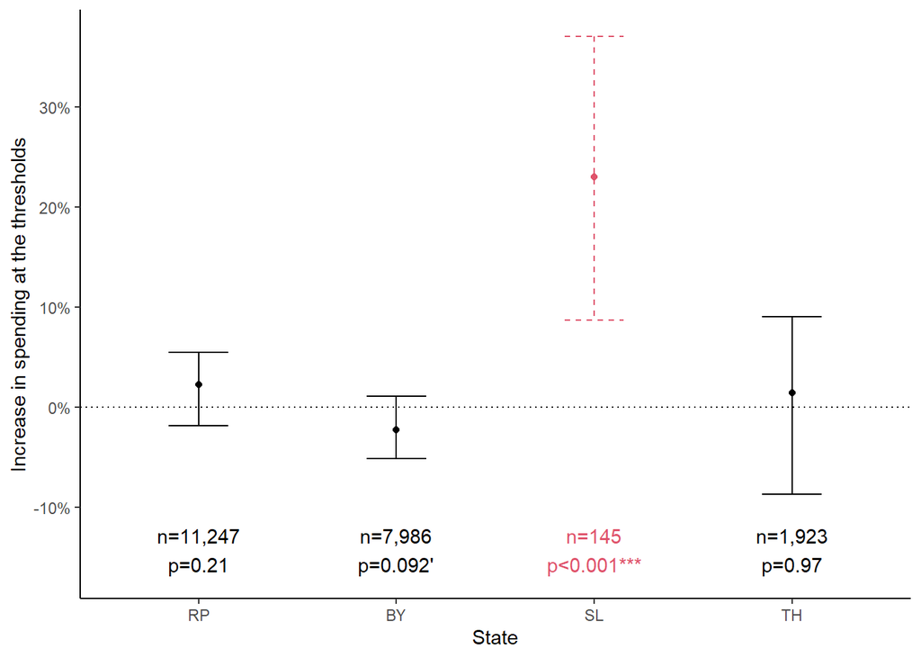

```r
# Second stage
df <- rdd_vary_states %>%
  filter(method == "sharp") %>% # CIs too large
  mutate(state_name = case_when(
    state == 7 ~ "RP",
    state == 9 ~ "BY",
    state == 10 ~ "SL",
    state == 16 ~ "TH"
  ),
  state_name = fct_reorder(state_name, state)) %>%
  rowwise() %>%
  mutate(note = paste0(
    "n=",
    trimws(format(sum(obs_below, obs_above), big.mark = ",")),
    "\n",
    p_value(p),
    assign_stars(p)
    )) %>%
  ungroup()
plot_states_sharp <- ggplot2::ggplot(data = df, aes(x = state_name, y = point_estimate)) +
  geom_point(size = 1.5, color = ifelse(df$p <= p_value_cutoff, 2, 1)) +
  geom_errorbar(aes(ymin = ci_lower, ymax = ci_upper),
                color = ifelse(df$p <= p_value_cutoff, 2, 1),
                linetype = ifelse(df$p <= p_value_cutoff, 2, 1),
                width = 0.3) +
  geom_text(aes(y = -0.165, label = note),
            colour = ifelse(df$p <= p_value_cutoff, 2, 1), vjust = 0) +
  geom_hline(aes(yintercept = 0), linetype = "dotted") +
  scale_y_continuous(labels = scales::percent) +
  labs(x = "State", y = y_lab_RDD)
plot_states_sharp
```

```r
ggsave(filename = "plots/rdd_states_sharp.pdf", width = 6, height = 6*9/16)
rm(df)
```

Plot `rdrobust` results in one:

```r
# to do: delete code
plot_states <- ggpubr::ggarrange(
  plot_states_fuzzy1, plot_states_fuzzy2, plot_states_sharp,
  # labels = c("SH", "NW", "Hesse", "Rhineland-Palatinate", "Baden-Württemberg",
  #            "Bavaria", "Saarland", "Mecklenburg-Vorpommern", "Saxony", "Thuringia"),
  #labels = paste(" ", c("SH", "NW", "HE", "RP", "BW", "BY", "SL", "MV", "SN", "TH")),
  #label.x = "Population",
  #label.y = "Council size",
  #common.legend = TRUE,
  ncol = 2, nrow = 2) %>%
  annotate_figure(
    # See https://github.com/kassambara/ggpubr/issues/78
    #left = text_grob("Council size", rot = 90),
    #bottom = text_grob("Population")
)
plot_states
```

Some notes:

```r
# Saxony (SN): municipalities with < 10000 inhabs
nrow(data %>% filter(state == 14))
```

```
## [1] 6365
```

```r
nrow(data %>% filter(state == 14, exact_pop <= 10000))
```

```
## [1] 3953
```

```r
nrow(data %>% filter(state == 14, exact_pop <= 10000)) / nrow(data %>% filter(state == 14))
```

```
## [1] 0.6210526
```

```r
# Saarland (SL):
nrow(data %>% filter(state == 10))
```

```
## [1] 676
```

Interaction-term method in the *subsample* approach:

```r
all_states <- data %>%
  distinct(state) %>%
  filter(state != "3", state != "12", state != "13", state != "15") %>%
  pull() # vector of states
df <- data %>%
  filter(closest <= 0.1) %>%
  mutate(state = as.factor(state))
for (i in all_states) {
  df_state <- df %>% filter(state == i)
  rdd <- fixest::feols(ln_gross_expenditure_pc ~
                       1  | # controls
                       inhabitants_treshold_factor + year | # fixed-effect controls
                       # First stage regression:
                       inhabs_rel_to_cutoff*total_seats ~ # Instrument our standard RDD...
                       inhabs_rel_to_cutoff*above_cutoff, # ... with being above the cutoff
                     vcov = "twoway",
                     data = df_state)
  print(paste("State:", i))
  print(summary(rdd))
}
```

```
## NOTE: 98 observations removed because of NA values (LHS: 98).
```

```
## [1] "State: 1"
## TSLS estimation, Dep. Var.: ln_gross_expenditure_pc, Endo.: inhabs_rel_to_cutoff, total_seats, inhabs_rel_to_cutoff:total_seats, Instr.: inhabs_rel_to_cutoff, above_cutoff, inhabs_rel_to_cutoff:above_cutoff
## Second stage: Dep. Var.: ln_gross_expenditure_pc
## Observations: 1,106
## Fixed-effects: inhabitants_treshold_factor: 10,  year: 11
## Standard-errors: Clustered (inhabitants_treshold_factor & year)
##                                         Estimate Std. Error   t value Pr(>|t|)
## fit_inhabs_rel_to_cutoff             -119.394634 761.688066 -0.156750  0.87890
## fit_total_seats                         0.022093   0.070967  0.311321  0.76265
## fit_inhabs_rel_to_cutoff:total_seats    9.422179  60.571785  0.155554  0.87982
## ---
## Signif. codes:  0 '***' 0.001 '**' 0.01 '*' 0.05 '.' 0.1 ' ' 1
## RMSE: 1.2166     Adj. R2:  -9.42362
##                Within R2: -11.8
## F-test (1st stage), inhabs_rel_to_cutoff            : stat =     6.702e+32, p < 2.2e-16, on 3 and 1,102 DoF.
## F-test (1st stage), total_seats                     : stat =   499.8      , p < 2.2e-16, on 3 and 1,102 DoF.
## F-test (1st stage), inhabs_rel_to_cutoff:total_seats: stat = 2,217.8      , p < 2.2e-16, on 3 and 1,102 DoF.
##                                           Wu-Hausman: stat =    NA        , p = NA     , on 3 and 1,080 DoF.
```

```
## NOTE: 303 observations removed because of NA values (LHS: 303).
```

```
## [1] "State: 5"
## TSLS estimation, Dep. Var.: ln_gross_expenditure_pc, Endo.: inhabs_rel_to_cutoff, total_seats, inhabs_rel_to_cutoff:total_seats, Instr.: inhabs_rel_to_cutoff, above_cutoff, inhabs_rel_to_cutoff:above_cutoff
## Second stage: Dep. Var.: ln_gross_expenditure_pc
## Observations: 360
## Fixed-effects: inhabitants_treshold_factor: 9,  year: 7
## Standard-errors: Clustered (inhabitants_treshold_factor & year)
##                                        Estimate Std. Error  t value Pr(>|t|)
## fit_inhabs_rel_to_cutoff             -34.928731  21.571665 -1.61919  0.15653
## fit_total_seats                        0.017460   0.017338  1.00706  0.35278
## fit_inhabs_rel_to_cutoff:total_seats   0.978513   0.636616  1.53705  0.17519
## ---
## Signif. codes:  0 '***' 0.001 '**' 0.01 '*' 0.05 '.' 0.1 ' ' 1
## RMSE: 0.25042     Adj. R2:  0.171129
##                 Within R2: -0.573265
## F-test (1st stage), inhabs_rel_to_cutoff            : stat =     6.228e+31, p < 2.2e-16, on 3 and 356 DoF.
## F-test (1st stage), total_seats                     : stat =    50.7      , p < 2.2e-16, on 3 and 356 DoF.
## F-test (1st stage), inhabs_rel_to_cutoff:total_seats: stat = 2,154.8      , p < 2.2e-16, on 3 and 356 DoF.
##                                           Wu-Hausman: stat =    NA        , p = NA     , on 3 and 339 DoF.
## [1] "State: 6"
## TSLS estimation, Dep. Var.: ln_gross_expenditure_pc, Endo.: inhabs_rel_to_cutoff, total_seats, inhabs_rel_to_cutoff:total_seats, Instr.: inhabs_rel_to_cutoff, above_cutoff, inhabs_rel_to_cutoff:above_cutoff
## Second stage: Dep. Var.: ln_gross_expenditure_pc
## Observations: 718
## Fixed-effects: inhabitants_treshold_factor: 5,  year: 13
## Standard-errors: Clustered (inhabitants_treshold_factor & year)
##                                        Estimate Std. Error   t value Pr(>|t|)
## fit_inhabs_rel_to_cutoff             -18.175853  44.898808 -0.404818  0.70632
## fit_total_seats                        0.005865   0.036731  0.159670  0.88088
## fit_inhabs_rel_to_cutoff:total_seats   0.598887   1.706148  0.351017  0.74328
## ---
## Signif. codes:  0 '***' 0.001 '**' 0.01 '*' 0.05 '.' 0.1 ' ' 1
## RMSE: 0.211388     Adj. R2:  0.110315
##                  Within R2: -0.448392
## F-test (1st stage), inhabs_rel_to_cutoff            : stat =     4.994e+32, p < 2.2e-16, on 3 and 714 DoF.
## F-test (1st stage), total_seats                     : stat =   156.7      , p < 2.2e-16, on 3 and 714 DoF.
## F-test (1st stage), inhabs_rel_to_cutoff:total_seats: stat = 4,053.1      , p < 2.2e-16, on 3 and 714 DoF.
##                                           Wu-Hausman: stat =    NA        , p = NA     , on 3 and 695 DoF.
```

```
## NOTE: 3 observations removed because of NA values (LHS: 3).
```

```
## [1] "State: 7"
## TSLS estimation, Dep. Var.: ln_gross_expenditure_pc, Endo.: inhabs_rel_to_cutoff, total_seats, inhabs_rel_to_cutoff:total_seats, Instr.: inhabs_rel_to_cutoff, above_cutoff, inhabs_rel_to_cutoff:above_cutoff
## Second stage: Dep. Var.: ln_gross_expenditure_pc
## Observations: 3,266
## Fixed-effects: inhabitants_treshold_factor: 13,  year: 13
## Standard-errors: Clustered (inhabitants_treshold_factor & year)
##                                       Estimate Std. Error   t value  Pr(>|t|)
## fit_inhabs_rel_to_cutoff             -0.133938   2.693486 -0.049727 0.9611582
## fit_total_seats                       0.096564   0.026528  3.640029 0.0033879
## fit_inhabs_rel_to_cutoff:total_seats -0.278629   0.262669 -1.060761 0.3096823
##
## fit_inhabs_rel_to_cutoff
## fit_total_seats                      **
## fit_inhabs_rel_to_cutoff:total_seats
## ---
## Signif. codes:  0 '***' 0.001 '**' 0.01 '*' 0.05 '.' 0.1 ' ' 1
## RMSE: 0.362438     Adj. R2:  0.163609
##                  Within R2: -0.059852
## F-test (1st stage), inhabs_rel_to_cutoff            : stat =     8.187e+32, p < 2.2e-16, on 3 and 3,262 DoF.
## F-test (1st stage), total_seats                     : stat =   744.8      , p < 2.2e-16, on 3 and 3,262 DoF.
## F-test (1st stage), inhabs_rel_to_cutoff:total_seats: stat = 4,857.6      , p < 2.2e-16, on 3 and 3,262 DoF.
##                                           Wu-Hausman: stat =    NA        , p = NA     , on 3 and 3,235 DoF.
```

```
## NOTE: 1 observation removed because of NA values (LHS: 1).
```

```
## [1] "State: 8"
## TSLS estimation, Dep. Var.: ln_gross_expenditure_pc, Endo.: inhabs_rel_to_cutoff, total_seats, inhabs_rel_to_cutoff:total_seats, Instr.: inhabs_rel_to_cutoff, above_cutoff, inhabs_rel_to_cutoff:above_cutoff
## Second stage: Dep. Var.: ln_gross_expenditure_pc
## Observations: 2,092
## Fixed-effects: inhabitants_treshold_factor: 9,  year: 13
## Standard-errors: Clustered (inhabitants_treshold_factor & year)
##                                       Estimate Std. Error   t value Pr(>|t|)
## fit_inhabs_rel_to_cutoff             78.793700 353.906443  0.222640  0.82939
## fit_total_seats                       0.093049   0.257476  0.361391  0.72717
## fit_inhabs_rel_to_cutoff:total_seats -4.750783  21.510201 -0.220862  0.83073
## ---
## Signif. codes:  0 '***' 0.001 '**' 0.01 '*' 0.05 '.' 0.1 ' ' 1
## RMSE: 0.807632     Adj. R2: -11.1
##                  Within R2: -16.9
## F-test (1st stage), inhabs_rel_to_cutoff            : stat =     6.882e+32, p < 2.2e-16 , on 3 and 2,088 DoF.
## F-test (1st stage), total_seats                     : stat =    16.1      , p = 2.35e-10, on 3 and 2,088 DoF.
## F-test (1st stage), inhabs_rel_to_cutoff:total_seats: stat = 4,596.2      , p < 2.2e-16 , on 3 and 2,088 DoF.
##                                           Wu-Hausman: stat =    NA        , p = NA      , on 3 and 2,065 DoF.
## [1] "State: 9"
## TSLS estimation, Dep. Var.: ln_gross_expenditure_pc, Endo.: inhabs_rel_to_cutoff, total_seats, inhabs_rel_to_cutoff:total_seats, Instr.: inhabs_rel_to_cutoff, above_cutoff, inhabs_rel_to_cutoff:above_cutoff
## Second stage: Dep. Var.: ln_gross_expenditure_pc
## Observations: 3,809
## Fixed-effects: inhabitants_treshold_factor: 9,  year: 13
## Standard-errors: Clustered (inhabitants_treshold_factor & year)
##                                       Estimate Std. Error   t value Pr(>|t|)
## fit_inhabs_rel_to_cutoff              2.708446  10.899704  0.248488  0.81002
## fit_total_seats                      -0.020842   0.014292 -1.458241  0.18289
## fit_inhabs_rel_to_cutoff:total_seats -0.112253   0.636965 -0.176232  0.86449
## ---
## Signif. codes:  0 '***' 0.001 '**' 0.01 '*' 0.05 '.' 0.1 ' ' 1
## RMSE: 0.282288     Adj. R2:  0.21202
##                  Within R2: -0.014437
## F-test (1st stage), inhabs_rel_to_cutoff            : stat =      6.336e+33, p < 2.2e-16, on 3 and 3,805 DoF.
## F-test (1st stage), total_seats                     : stat =  2,158.5      , p < 2.2e-16, on 3 and 3,805 DoF.
## F-test (1st stage), inhabs_rel_to_cutoff:total_seats: stat = 11,131.6      , p < 2.2e-16, on 3 and 3,805 DoF.
##                                           Wu-Hausman: stat =     NA        , p = NA     , on 3 and 3,782 DoF.
```

```
## NOTE: 45 observations removed because of NA values (LHS: 45).
```

```
## [1] "State: 10"
## TSLS estimation, Dep. Var.: ln_gross_expenditure_pc, Endo.: inhabs_rel_to_cutoff, total_seats, inhabs_rel_to_cutoff:total_seats, Instr.: inhabs_rel_to_cutoff, above_cutoff, inhabs_rel_to_cutoff:above_cutoff
## Second stage: Dep. Var.: ln_gross_expenditure_pc
## Observations: 48
## Fixed-effects: inhabitants_treshold_factor: 4,  year: 7
## Standard-errors: Clustered (inhabitants_treshold_factor & year)
##                                       Estimate Std. Error  t value Pr(>|t|)
## fit_inhabs_rel_to_cutoff             65.918136  52.791507  1.24865  0.30036
## fit_total_seats                       0.168552   0.082233  2.04970  0.13280
## fit_inhabs_rel_to_cutoff:total_seats -2.549544   1.913625 -1.33231  0.27492
## ---
## Signif. codes:  0 '***' 0.001 '**' 0.01 '*' 0.05 '.' 0.1 ' ' 1
## RMSE: 0.213965     Adj. R2:  0.084925
##                  Within R2: -0.859394
## F-test (1st stage), inhabs_rel_to_cutoff            : stat =   1.144e+30, p < 2.2e-16, on 3 and 44 DoF.
## F-test (1st stage), total_seats                     : stat =   3.25e+29 , p < 2.2e-16, on 3 and 44 DoF.
## F-test (1st stage), inhabs_rel_to_cutoff:total_seats: stat = 892.6      , p < 2.2e-16, on 3 and 44 DoF.
##                                           Wu-Hausman: stat =  NA        , p = NA     , on 3 and 32 DoF.
## [1] "State: 14"
## TSLS estimation, Dep. Var.: ln_gross_expenditure_pc, Endo.: inhabs_rel_to_cutoff, total_seats, inhabs_rel_to_cutoff:total_seats, Instr.: inhabs_rel_to_cutoff, above_cutoff, inhabs_rel_to_cutoff:above_cutoff
## Second stage: Dep. Var.: ln_gross_expenditure_pc
## Observations: 770
## Fixed-effects: inhabitants_treshold_factor: 10,  year: 12
## Standard-errors: Clustered (inhabitants_treshold_factor & year)
##                                         Estimate Std. Error   t value Pr(>|t|)
## fit_inhabs_rel_to_cutoff             -139.864748  142.87228 -0.978950  0.35318
## fit_total_seats                        -0.207190    1.09868 -0.188581  0.85461
## fit_inhabs_rel_to_cutoff:total_seats    8.402528    9.11732  0.921601  0.38078
## ---
## Signif. codes:  0 '***' 0.001 '**' 0.01 '*' 0.05 '.' 0.1 ' ' 1
## RMSE: 1.07396     Adj. R2: -14.2
##                 Within R2: -20.8
## F-test (1st stage), inhabs_rel_to_cutoff            : stat =     9.921e+32, p < 2.2e-16 , on 3 and 766 DoF.
## F-test (1st stage), total_seats                     : stat =     2.11681  , p = 0.096682, on 3 and 766 DoF.
## F-test (1st stage), inhabs_rel_to_cutoff:total_seats: stat = 3,025.9      , p < 2.2e-16 , on 3 and 766 DoF.
##                                           Wu-Hausman: stat =    NA        , p = NA      , on 3 and 743 DoF.
```

```
## NOTE: 405 observations removed because of NA values (LHS: 405).
```

```
## Variance contained negative values in the diagonal and was 'fixed' (a la Cameron, Gelbach & Miller 2011).
```

```
## [1] "State: 16"
## TSLS estimation, Dep. Var.: ln_gross_expenditure_pc, Endo.: inhabs_rel_to_cutoff, total_seats, inhabs_rel_to_cutoff:total_seats, Instr.: inhabs_rel_to_cutoff, above_cutoff, inhabs_rel_to_cutoff:above_cutoff
## Second stage: Dep. Var.: ln_gross_expenditure_pc
## Observations: 786
## Fixed-effects: inhabitants_treshold_factor: 10,  year: 13
## Standard-errors: Clustered (inhabitants_treshold_factor & year)
##                                       Estimate Std. Error    t value  Pr(>|t|)
## fit_inhabs_rel_to_cutoff              3.019212   0.006930 435.643256 < 2.2e-16
## fit_total_seats                      -0.045882   0.045261  -1.013720   0.33719
## fit_inhabs_rel_to_cutoff:total_seats  0.012145   0.184850   0.065704   0.94905
##
## fit_inhabs_rel_to_cutoff             ***
## fit_total_seats
## fit_inhabs_rel_to_cutoff:total_seats
## ---
## Signif. codes:  0 '***' 0.001 '**' 0.01 '*' 0.05 '.' 0.1 ' ' 1
## RMSE: 0.321836     Adj. R2: 0.172473
##                  Within R2: 0.011835
## F-test (1st stage), inhabs_rel_to_cutoff            : stat =     6.418e+32, p < 2.2e-16, on 3 and 782 DoF.
## F-test (1st stage), total_seats                     : stat =   893.3      , p < 2.2e-16, on 3 and 782 DoF.
## F-test (1st stage), inhabs_rel_to_cutoff:total_seats: stat = 1,552.4      , p < 2.2e-16, on 3 and 782 DoF.
##                                           Wu-Hausman: stat =    NA        , p = NA     , on 3 and 758 DoF.
```

```r
rm(all_states, df, df_state, rdd)
```

Interaction-term method using an IV approach:

```r
df <- data %>%
  filter(closest <= 0.1) %>%
  mutate(state = as.factor(state)) # to do: why isn't it in `data`
rdd <- fixest::feols(ln_gross_expenditure_pc ~
                       1  | # controls
                       inhabitants_treshold_factor + year | # fixed-effect controls
                       # First stage regression:
                       inhabs_rel_to_cutoff*total_seats*state ~ # Instrument our standard RDD...
                       inhabs_rel_to_cutoff*above_cutoff*state, # ... with being above the cutoff
                     vcov = "twoway",
                     data = df)
```

```
## NOTE: 2,600 observations removed because of NA values (LHS: 2,600).
```

```
## Variance contained negative values in the diagonal and was 'fixed' (a la Cameron, Gelbach & Miller 2011).
## Variance contained negative values in the diagonal and was 'fixed' (a la Cameron, Gelbach & Miller 2011).
## Variance contained negative values in the diagonal and was 'fixed' (a la Cameron, Gelbach & Miller 2011).
## Variance contained negative values in the diagonal and was 'fixed' (a la Cameron, Gelbach & Miller 2011).
## Variance contained negative values in the diagonal and was 'fixed' (a la Cameron, Gelbach & Miller 2011).
## Variance contained negative values in the diagonal and was 'fixed' (a la Cameron, Gelbach & Miller 2011).
```

```
## The endogenous regressors 'fit_state15', 'fit_inhabs_rel_to_cutoff:state15' and 4 others have been removed because of collinearity (see $collin.var).
```

```r
summary(rdd)
```

```
## TSLS estimation, Dep. Var.: ln_gross_expenditure_pc, Endo.: inhabs_rel_to_cutoff, total_seats, state, inhabs_rel_to_cutoff:total_seats, inhabs_rel_to_cutoff:state, total_seats:state, inhabs_rel_to_cutoff:total_seats:state, Instr.: inhabs_rel_to_cutoff, above_cutoff, state, inhabs_rel_to_cutoff:ab…
## Second stage: Dep. Var.: ln_gross_expenditure_pc
## Observations: 12,964
## Fixed-effects: inhabitants_treshold_factor: 30,  year: 13
## Standard-errors: Clustered (inhabitants_treshold_factor & year)
##                                                 Estimate  Std. Error   t value
## fit_inhabs_rel_to_cutoff                      -89.093240 2008.527318 -0.044357
## fit_total_seats                                 0.022175    0.680906  0.032567
## fit_state5                                      8.902806  149.040271  0.059734
## fit_state6                                     -0.183534   22.147095 -0.008287
## fit_state7                                     -4.004769   36.736509 -0.109013
## fit_state8                                      3.102553   65.796596  0.047154
## fit_state9                                      1.141682   21.251651  0.053722
## fit_state10                                    -0.222068   62.731832 -0.003540
## fit_state13                                     6.293297   75.715128  0.083118
## fit_state14                                     1.553842  126.196418  0.012313
## fit_state16                                    -0.098885   44.629657 -0.002216
## fit_inhabs_rel_to_cutoff:total_seats            6.936123  156.520306  0.044315
## fit_inhabs_rel_to_cutoff:state5                38.153087 2276.828838  0.016757
## fit_inhabs_rel_to_cutoff:state6               103.832116 2406.443570  0.043148
## fit_inhabs_rel_to_cutoff:state7                81.269096 1997.846780  0.040678
## fit_inhabs_rel_to_cutoff:state8                60.549544 2216.075838  0.027323
## fit_inhabs_rel_to_cutoff:state9                99.047216 2091.196228  0.047364
## fit_inhabs_rel_to_cutoff:state10              134.047799 2695.202437  0.049736
## fit_inhabs_rel_to_cutoff:state13               80.149234 2715.383661  0.029517
## fit_inhabs_rel_to_cutoff:state14             -108.845910 4121.231887 -0.026411
## fit_inhabs_rel_to_cutoff:state16              102.102206 2342.534076  0.043586
## fit_total_seats:state5                         -0.239674    3.982495 -0.060182
## fit_total_seats:state6                          0.001962    0.887740  0.002210
## fit_total_seats:state7                          0.216997    1.819732  0.119247
## fit_total_seats:state8                         -0.171198    3.883573 -0.044082
## fit_total_seats:state9                         -0.054578    0.979037 -0.055747
## fit_total_seats:state10                        -0.004050    2.520215 -0.001607
## fit_total_seats:state14                        -0.096369    7.741704 -0.012448
## fit_total_seats:state16                        -0.021367    3.127141 -0.006833
## fit_inhabs_rel_to_cutoff:total_seats:state5    -4.865798  158.608452 -0.030678
## fit_inhabs_rel_to_cutoff:total_seats:state6    -7.589615  167.029473 -0.045439
## fit_inhabs_rel_to_cutoff:total_seats:state7    -7.213387  159.619551 -0.045191
## fit_inhabs_rel_to_cutoff:total_seats:state8    -5.172386  164.431268 -0.031456
## fit_inhabs_rel_to_cutoff:total_seats:state9    -7.459197  161.396824 -0.046217
```

[output cut: 76 more lines]

```
## F-test (1st stage), total_seats:state13                     : stat =      1.277e+19, p < 2.2e-16, on 37 and 12,926 DoF.
## F-test (1st stage), total_seats:state14                     : stat =  4,792.7      , p < 2.2e-16, on 37 and 12,926 DoF.
## F-test (1st stage), total_seats:state15                     : stat =     NA        , p = NA     , on 37 and 12,926 DoF.
## F-test (1st stage), total_seats:state16                     : stat =  1,428.4      , p < 2.2e-16, on 37 and 12,926 DoF.
## F-test (1st stage), inhabs_rel_to_cutoff:total_seats:state5 : stat =  5,967.0      , p < 2.2e-16, on 37 and 12,926 DoF.
## F-test (1st stage), inhabs_rel_to_cutoff:total_seats:state6 : stat =  4,855.2      , p < 2.2e-16, on 37 and 12,926 DoF.
## F-test (1st stage), inhabs_rel_to_cutoff:total_seats:state7 : stat =  1,446.7      , p < 2.2e-16, on 37 and 12,926 DoF.
## F-test (1st stage), inhabs_rel_to_cutoff:total_seats:state8 : stat =  2,281.1      , p < 2.2e-16, on 37 and 12,926 DoF.
## F-test (1st stage), inhabs_rel_to_cutoff:total_seats:state9 : stat =  2,803.6      , p < 2.2e-16, on 37 and 12,926 DoF.
## F-test (1st stage), inhabs_rel_to_cutoff:total_seats:state10: stat = 11,600.6      , p < 2.2e-16, on 37 and 12,926 DoF.
## F-test (1st stage), inhabs_rel_to_cutoff:total_seats:state13: stat =      1.212e+18, p < 2.2e-16, on 37 and 12,926 DoF.
## F-test (1st stage), inhabs_rel_to_cutoff:total_seats:state14: stat =  4,101.2      , p < 2.2e-16, on 37 and 12,926 DoF.
## F-test (1st stage), inhabs_rel_to_cutoff:total_seats:state15: stat =     NA        , p = NA     , on 37 and 12,926 DoF.
## F-test (1st stage), inhabs_rel_to_cutoff:total_seats:state16: stat =  1,648.5      , p < 2.2e-16, on 37 and 12,926 DoF.
##                                                   Wu-Hausman: stat =     NA        , p = NA     , on 43 and 12,842 DoF.
```

```r
# joint test on interactions
fixest::wald(rdd, "fit_total_seats:state")
```

```
## Wald test, H0: joint nullity of fit_total_seats:state5, fit_total_seats:state6, fit_total_seats:state7, fit_total_seats:state8, fit_total_seats:state9, fit_total_seats:state10 and 2 others
##  stat = 8.386e-4, p-value = 1, on 8 and 12,885 DoF, VCOV: Clustered (inhabitants_treshold_factor & year).
```

```r
rm(df)
```

Test more extreme “individual” values:

```r
df <- data %>%
  filter(closest <= 0.1) %>%
  mutate(state = relevel(as.factor(state), ref = "10")) # to do: why isn't it in `data`
rdd <- fixest::feols(ln_gross_expenditure_pc ~
                       1  | # controls
                       inhabitants_treshold_factor + year | # fixed-effect controls
                       # First stage regression:
                       inhabs_rel_to_cutoff*total_seats*state ~ # Instrument our standard RDD...
                       inhabs_rel_to_cutoff*above_cutoff*state, # ... with being above the cutoff
                     vcov = "twoway",
                     data = df)
```

```
## NOTE: 2,600 observations removed because of NA values (LHS: 2,600).
```

```
## Variance contained negative values in the diagonal and was 'fixed' (a la Cameron, Gelbach & Miller 2011).
## Variance contained negative values in the diagonal and was 'fixed' (a la Cameron, Gelbach & Miller 2011).
## Variance contained negative values in the diagonal and was 'fixed' (a la Cameron, Gelbach & Miller 2011).
## Variance contained negative values in the diagonal and was 'fixed' (a la Cameron, Gelbach & Miller 2011).
## Variance contained negative values in the diagonal and was 'fixed' (a la Cameron, Gelbach & Miller 2011).
## Variance contained negative values in the diagonal and was 'fixed' (a la Cameron, Gelbach & Miller 2011).
## Variance contained negative values in the diagonal and was 'fixed' (a la Cameron, Gelbach & Miller 2011).
## Variance contained negative values in the diagonal and was 'fixed' (a la Cameron, Gelbach & Miller 2011).
```

```
## The endogenous regressors 'fit_state15', 'fit_inhabs_rel_to_cutoff:state15' and 4 others have been removed because of collinearity (see $collin.var).
```

```r
summary(rdd)
```

```
## TSLS estimation, Dep. Var.: ln_gross_expenditure_pc, Endo.: inhabs_rel_to_cutoff, total_seats, state, inhabs_rel_to_cutoff:total_seats, inhabs_rel_to_cutoff:state, total_seats:state, inhabs_rel_to_cutoff:total_seats:state, Instr.: inhabs_rel_to_cutoff, above_cutoff, state, inhabs_rel_to_cutoff:ab…
## Second stage: Dep. Var.: ln_gross_expenditure_pc
## Observations: 12,964
## Fixed-effects: inhabitants_treshold_factor: 30,  year: 13
## Standard-errors: Clustered (inhabitants_treshold_factor & year)
##                                                 Estimate Std. Error   t value
## fit_inhabs_rel_to_cutoff                       44.954560 2999.44360  0.014988
## fit_total_seats                                 0.018125    3.59982  0.005035
## fit_state1                                      0.222068  125.40864  0.001771
## fit_state5                                      9.124874  148.60182  0.061405
## fit_state6                                      0.038533  139.66865  0.000276
## fit_state7                                     -3.782702  147.53613 -0.025639
## fit_state8                                      3.324621   63.45067  0.052397
## fit_state9                                      1.363750   97.20824  0.014029
## fit_state13                                     4.827429  130.26187  0.037059
## fit_state14                                     1.775909   75.01557  0.023674
## fit_state16                                     0.123183  114.51495  0.001076
## fit_inhabs_rel_to_cutoff:total_seats           -1.451440   91.25764 -0.015905
## fit_inhabs_rel_to_cutoff:state1              -134.047802 6923.20643 -0.019362
## fit_inhabs_rel_to_cutoff:state5               -95.894712 4953.62076 -0.019359
## fit_inhabs_rel_to_cutoff:state6               -30.215683 3821.12601 -0.007908
## fit_inhabs_rel_to_cutoff:state7               -52.778703 3132.78689 -0.016847
## fit_inhabs_rel_to_cutoff:state8               -73.498256 5034.02389 -0.014600
## fit_inhabs_rel_to_cutoff:state9               -35.000583 2511.98878 -0.013933
## fit_inhabs_rel_to_cutoff:state13              198.574512 5276.02146  0.037637
## fit_inhabs_rel_to_cutoff:state14             -242.893710 4069.46969 -0.059687
## fit_inhabs_rel_to_cutoff:state16              -31.945594 3183.37398 -0.010035
## fit_total_seats:state1                          0.004050    4.59254  0.000882
## fit_total_seats:state5                         -0.235623    3.94840 -0.059676
## fit_total_seats:state6                          0.006012    4.93742  0.001218
## fit_total_seats:state7                          0.221047    5.81006  0.038046
## fit_total_seats:state8                         -0.167147    5.24863 -0.031846
## fit_total_seats:state9                         -0.050528    3.22075 -0.015688
## fit_total_seats:state14                        -0.092319    3.57253 -0.025841
## fit_total_seats:state16                        -0.017317    4.06372 -0.004261
## fit_inhabs_rel_to_cutoff:total_seats:state1     8.387563  483.03602  0.017364
## fit_inhabs_rel_to_cutoff:total_seats:state5     3.521765  153.66795  0.022918
## fit_inhabs_rel_to_cutoff:total_seats:state6     0.797948  137.45356  0.005805
## fit_inhabs_rel_to_cutoff:total_seats:state7     1.174175  109.12254  0.010760
## fit_inhabs_rel_to_cutoff:total_seats:state8     3.215177  233.73527  0.013756
```

[output cut: 76 more lines]

```
## F-test (1st stage), total_seats:state13                     : stat =     1.277e+19, p < 2.2e-16, on 37 and 12,926 DoF.
## F-test (1st stage), total_seats:state14                     : stat = 4,792.7      , p < 2.2e-16, on 37 and 12,926 DoF.
## F-test (1st stage), total_seats:state15                     : stat =    NA        , p = NA     , on 37 and 12,926 DoF.
## F-test (1st stage), total_seats:state16                     : stat = 1,428.4      , p < 2.2e-16, on 37 and 12,926 DoF.
## F-test (1st stage), inhabs_rel_to_cutoff:total_seats:state1 : stat = 1,990.2      , p < 2.2e-16, on 37 and 12,926 DoF.
## F-test (1st stage), inhabs_rel_to_cutoff:total_seats:state5 : stat = 5,967.0      , p < 2.2e-16, on 37 and 12,926 DoF.
## F-test (1st stage), inhabs_rel_to_cutoff:total_seats:state6 : stat = 4,855.2      , p < 2.2e-16, on 37 and 12,926 DoF.
## F-test (1st stage), inhabs_rel_to_cutoff:total_seats:state7 : stat = 1,446.7      , p < 2.2e-16, on 37 and 12,926 DoF.
## F-test (1st stage), inhabs_rel_to_cutoff:total_seats:state8 : stat = 2,281.1      , p < 2.2e-16, on 37 and 12,926 DoF.
## F-test (1st stage), inhabs_rel_to_cutoff:total_seats:state9 : stat = 2,803.6      , p < 2.2e-16, on 37 and 12,926 DoF.
## F-test (1st stage), inhabs_rel_to_cutoff:total_seats:state13: stat =     1.212e+18, p < 2.2e-16, on 37 and 12,926 DoF.
## F-test (1st stage), inhabs_rel_to_cutoff:total_seats:state14: stat = 4,101.2      , p < 2.2e-16, on 37 and 12,926 DoF.
## F-test (1st stage), inhabs_rel_to_cutoff:total_seats:state15: stat =    NA        , p = NA     , on 37 and 12,926 DoF.
## F-test (1st stage), inhabs_rel_to_cutoff:total_seats:state16: stat = 1,648.5      , p < 2.2e-16, on 37 and 12,926 DoF.
##                                                   Wu-Hausman: stat =    NA        , p = NA     , on 43 and 12,842 DoF.
```

```r
# joint test on interactions
fixest::wald(rdd, "fit_total_seats:state")
```

```
## Wald test, H0: joint nullity of fit_total_seats:state1, fit_total_seats:state5, fit_total_seats:state6, fit_total_seats:state7, fit_total_seats:state8, fit_total_seats:state9 and 2 others
##  stat = -4.19e-4, p-value = 1, on 8 and 12,885 DoF, VCOV: Clustered (inhabitants_treshold_factor & year).
```

```r
rm(df)
```

```r
df <- data %>%
  filter(closest <= 0.1) %>%
  mutate(state = relevel(as.factor(state), ref = "13")) # to do: why isn't it in `data`
rdd <- fixest::feols(ln_gross_expenditure_pc ~
                       1  | # controls
                       inhabitants_treshold_factor + year | # fixed-effect controls
                       # First stage regression:
                       inhabs_rel_to_cutoff*total_seats*state ~ # Instrument our standard RDD...
                       inhabs_rel_to_cutoff*above_cutoff*state, # ... with being above the cutoff
                     vcov = "twoway",
                     data = df)
```

```
## NOTE: 2,600 observations removed because of NA values (LHS: 2,600).
```

[output not shown]

```
## The endogenous regressors 'fit_state15', 'fit_inhabs_rel_to_cutoff:state15' and 3 others have been removed because of collinearity (see $collin.var).
```

```r
summary(rdd)
```

```
## TSLS estimation, Dep. Var.: ln_gross_expenditure_pc, Endo.: inhabs_rel_to_cutoff, total_seats, state, inhabs_rel_to_cutoff:total_seats, inhabs_rel_to_cutoff:state, total_seats:state, inhabs_rel_to_cutoff:total_seats:state, Instr.: inhabs_rel_to_cutoff, above_cutoff, state, inhabs_rel_to_cutoff:ab…
## Second stage: Dep. Var.: ln_gross_expenditure_pc
## Observations: 12,964
## Fixed-effects: inhabitants_treshold_factor: 30,  year: 13
## Standard-errors: Clustered (inhabitants_treshold_factor & year)
##                                                 Estimate  Std. Error   t value
## fit_inhabs_rel_to_cutoff                      150.895789  4797.98717  0.031450
## fit_total_seats                                 0.184587     5.15568  0.035803
## fit_state1                                      3.764531   154.06718  0.024434
## fit_state5                                     12.665826   422.97470  0.029945
## fit_state6                                      3.583254   142.98672  0.025060
## fit_state7                                     -0.236752   194.68152 -0.001216
## fit_state8                                      6.873328   366.66126  0.018746
## fit_state9                                      4.910204   182.50451  0.026905
## fit_state10                                     3.541858   304.85142  0.011618
## fit_state14                                     5.319052   216.22863  0.024599
## fit_state16                                     3.662815   169.63765  0.021592
## fit_inhabs_rel_to_cutoff:total_seats           -0.830061    75.07568 -0.011056
## fit_inhabs_rel_to_cutoff:state1              -240.054350 10179.55913 -0.023582
## fit_inhabs_rel_to_cutoff:state5              -201.875929  8648.07669 -0.023343
## fit_inhabs_rel_to_cutoff:state6              -136.216288  5292.65200 -0.025737
## fit_inhabs_rel_to_cutoff:state7              -158.765558  4688.57399 -0.033862
## fit_inhabs_rel_to_cutoff:state8              -179.548581  6071.18108 -0.029574
## fit_inhabs_rel_to_cutoff:state9              -140.982491  4404.71147 -0.032007
## fit_inhabs_rel_to_cutoff:state10             -105.977267  6573.43633 -0.016122
## fit_inhabs_rel_to_cutoff:state14             -348.901975 10471.98303 -0.033318
## fit_inhabs_rel_to_cutoff:state16             -137.878194  4556.74123 -0.030258
## fit_total_seats:state1                         -0.162472     5.74462 -0.028282
## fit_total_seats:state5                         -0.402237    12.81029 -0.031400
## fit_total_seats:state6                         -0.160555     5.04279 -0.031839
## fit_total_seats:state7                          0.054551     5.43228  0.010042
## fit_total_seats:state8                         -0.333628    16.96683 -0.019664
## fit_total_seats:state9                         -0.217035     5.56727 -0.038984
## fit_total_seats:state10                        -0.166402     9.71025 -0.017137
## fit_total_seats:state14                        -0.258878     9.64358 -0.026845
## fit_total_seats:state16                        -0.183900     4.40103 -0.041786
## fit_inhabs_rel_to_cutoff:total_seats:state1     7.766185   818.47046  0.009489
## fit_inhabs_rel_to_cutoff:total_seats:state5     2.900387   164.35455  0.017647
## fit_inhabs_rel_to_cutoff:total_seats:state6     0.176570   281.35114  0.000628
## fit_inhabs_rel_to_cutoff:total_seats:state7     0.552797    50.34557  0.010980
```

[output cut: 78 more lines]

```
## F-test (1st stage), total_seats:state10                     : stat = 11,307.6      , p < 2.2e-16, on 37 and 12,926 DoF.
## F-test (1st stage), total_seats:state14                     : stat =  4,792.7      , p < 2.2e-16, on 37 and 12,926 DoF.
## F-test (1st stage), total_seats:state15                     : stat =     NA        , p = NA     , on 37 and 12,926 DoF.
## F-test (1st stage), total_seats:state16                     : stat =  1,428.4      , p < 2.2e-16, on 37 and 12,926 DoF.
## F-test (1st stage), inhabs_rel_to_cutoff:total_seats:state1 : stat =  1,990.2      , p < 2.2e-16, on 37 and 12,926 DoF.
## F-test (1st stage), inhabs_rel_to_cutoff:total_seats:state5 : stat =  5,967.0      , p < 2.2e-16, on 37 and 12,926 DoF.
## F-test (1st stage), inhabs_rel_to_cutoff:total_seats:state6 : stat =  4,855.2      , p < 2.2e-16, on 37 and 12,926 DoF.
## F-test (1st stage), inhabs_rel_to_cutoff:total_seats:state7 : stat =  1,446.7      , p < 2.2e-16, on 37 and 12,926 DoF.
## F-test (1st stage), inhabs_rel_to_cutoff:total_seats:state8 : stat =  2,281.1      , p < 2.2e-16, on 37 and 12,926 DoF.
## F-test (1st stage), inhabs_rel_to_cutoff:total_seats:state9 : stat =  2,803.6      , p < 2.2e-16, on 37 and 12,926 DoF.
## F-test (1st stage), inhabs_rel_to_cutoff:total_seats:state10: stat = 11,600.6      , p < 2.2e-16, on 37 and 12,926 DoF.
## F-test (1st stage), inhabs_rel_to_cutoff:total_seats:state14: stat =  4,101.2      , p < 2.2e-16, on 37 and 12,926 DoF.
## F-test (1st stage), inhabs_rel_to_cutoff:total_seats:state15: stat =     NA        , p = NA     , on 37 and 12,926 DoF.
## F-test (1st stage), inhabs_rel_to_cutoff:total_seats:state16: stat =  1,648.5      , p < 2.2e-16, on 37 and 12,926 DoF.
##                                                   Wu-Hausman: stat =     NA        , p = NA     , on 43 and 12,841 DoF.
```

```r
# joint test on interactions
fixest::wald(rdd, "fit_total_seats:state")
```

```
## Wald test, H0: joint nullity of fit_total_seats:state1, fit_total_seats:state5, fit_total_seats:state6, fit_total_seats:state7, fit_total_seats:state8, fit_total_seats:state9 and 3 others
##  stat = -3.187e-5, p-value = 1, on 9 and 12,884 DoF, VCOV: Clustered (inhabitants_treshold_factor & year).
```

```r
rm(df)
```

States 13 (MV) and 15 (ST) apparently not testable…

To conclude: very contradicting results. Subsample yields several differences between states, interaction shows no significant results

Run RDD for Bavaria as some data are only available for Bavaria

# Different political systems

## At-large vs. ward electoral systems

Dummy `ward_elections` is 1 for states 01 and 05, 0 otherwise. 01 & 05 have mixed elections.

Subsample method:

```r
data_subset <- data %>% # prepare data set used for analysis
  select(ln_gross_expenditure_pc, inhabs_rel_to_cutoff, total_seats, inhabitants_treshold_factor, state, year, ward_elections) %>%
  drop_na()
all_values <- data_subset %>% distinct(ward_elections) %>% pull() # vector of values
rdd_vary_ward <- # prepare data set to store the results
  tibble(value = "", point_estimate = "", se = "", se_robust = "",
         ci_lower = "", ci_upper = "", p = "", bw = "", obs_below = "", obs_above = "") %>%
  mutate(across(everything(), as.numeric))
for (i in all_values) {
  print(paste("ward (0 is at large, 1 is partly in wards):", i))
  df <- data_subset %>%
    filter(ward_elections == i)
  rdd <-
    rdrobust_wrapper(
      ccluster = df$inhabitants_treshold_factor,
      ccovs = model.matrix( ~ df$inhabitants_treshold_factor + df$year + df$state) # Dropping year FE
      )
  #summary(rdd)
  rdd_vary_ward <- rdd_vary_ward %>%
    dplyr::add_row(
      value = as.numeric(i),
      point_estimate = rdd$coef[1],
      se = rdd$se[1],
      se_robust = rdd$se[3],
      ci_lower = rdd$ci[3,1],
      ci_upper = rdd$ci[3,2],
      p = rdd$pv[3],
      bw = rdd$bws[1,1],
      obs_below = rdd$N_h[1],
      obs_above = rdd$N_h[2]
  )
}
```

```
## [1] "ward (0 is at large, 1 is partly in wards): 1"
## [1] "Mass points detected in the running variable."
## [1] "ward (0 is at large, 1 is partly in wards): 0"
## [1] "Mass points detected in the running variable."
```

```r
rdd_vary_ward <- rdd_vary_ward %>% drop_na()
save(rdd_vary_ward, file = "tables_robustness_checks/rdd_vary_ward.Rdata")
rm(all_values, data_subset, df, i, rdd)
```

```r
load(file = "tables_robustness_checks/rdd_vary_ward.Rdata")
rdd_vary_ward
```

| value | point_estimate | se | se_robust | ci_lower | ci_upper | p | bw | obs_below | obs_above |
| --- | --- | --- | --- | --- | --- | --- | --- | --- | --- |
| 1 | 0.01861006 | 0.005712679 | 0.007026953 | 0.009206551 | 0.04540701 | 0.0001019069 | 0.09109236 | 1672 | 1654 |
| 0 | 0.00920975 | 0.013050082 | 0.013771676 | -0.025480420 | 0.04546655 | 0.4680689769 | 0.05443330 | 7127 | 7631 |

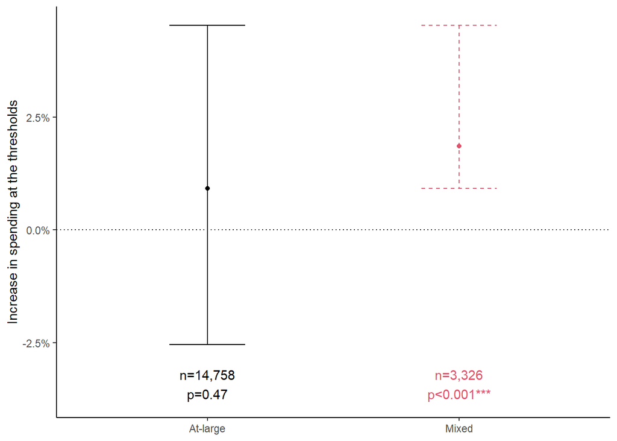

```r
 df <- rdd_vary_ward %>%
  rowwise() %>%
  mutate(note = paste0(
    "n=",
    trimws(format(sum(obs_below, obs_above), big.mark = ",")),
    "\n",
    p_value(p),
    assign_stars(p)
    )) %>%
  ungroup() %>%
  mutate(value2 = case_when(
    value == 1 ~ "Mixed",
    value == 0 ~ "At-large"
  ))
ggplot2::ggplot(data = df, aes(x = value2, y = point_estimate)) +
  geom_point(size = 1.5, color = ifelse(df$p <= p_value_cutoff, 2, 1)) +
  geom_errorbar(aes(ymin = ci_lower, ymax = ci_upper),
                color = ifelse(df$p <= p_value_cutoff, 2, 1),
                linetype = ifelse(df$p <= p_value_cutoff, 2, 1),
                width = 0.3) +
  geom_text(aes(y = -0.0375, label = note),
            colour = ifelse(df$p <= p_value_cutoff, 2, 1), vjust = 0) +
  geom_hline(aes(yintercept = 0), linetype = "dotted") +
  scale_y_continuous(labels = scales::percent) +
  labs(x = NULL, y = y_lab_RDD)
```

```r
ggsave(filename = "plots/rdd_atlarge_mixed.pdf", width = 6, height = 6*9/16)
rm(df)
```

Preliminary evidence looks promising: SH and NW spend more at the threshold (about 1.9 %), likely primarily driven by NW (see states section).

Interaction-term method using an IV approach::

```r
df <- data %>%
  filter(closest <= 0.1) %>%
  mutate(ward_elections = as.factor(ward_elections))
rdd <- fixest::feols(ln_gross_expenditure_pc ~
                       1  | # controls
                       inhabitants_treshold_factor + state + year | # fixed-effect controls
                       # First stage regression:
                       inhabs_rel_to_cutoff*total_seats*ward_elections ~
                       inhabs_rel_to_cutoff*above_cutoff*ward_elections,
                     vcov = "threeway",
                     data = df)
summary(rdd)
#rm(df)
```

[output not shown]

## Role of the mayor

Hard to pin down local constitutional types. The way I did it:

- `const_typ_sueddt` = 1 if states: 01, 03, 05, 07, 08, 09, 10, 14, 0 otherwise. I. e. = 1 if “pure” “süddeutsche Ratsverfassung”.
- `const_typ_magistrat` = 1 if state: 06, 0 otherwise. Only Hesse has pure “Magistratsverfassung”.

### `const_typ_sueddt` – Süddeutsche Ratsverfassung

(Main specification)

Subsample method:

```r
data_subset <- data %>% # prepare data set used for analysis
  select(ln_gross_expenditure_pc, inhabs_rel_to_cutoff, total_seats, inhabitants_treshold_factor, state, year, const_typ_sueddt) %>%
  drop_na()
all_values <- data_subset %>% distinct(const_typ_sueddt) %>% pull() # vector of values
rdd_vary_const_type <- # prepare data set to store the results
  tibble(const_typ_sueddt = "", point_estimate = "", se = "", se_robust = "",
         ci_lower = "", ci_upper = "", p = "", bw = "", obs_below = "", obs_above = "") %>%
  mutate(across(everything(), as.numeric))
for (i in all_values) {
  print(paste("constitutional type:", i))
  df <- data_subset %>%
    filter(const_typ_sueddt == i)
  rdd <-
    rdrobust_wrapper(
      ccluster = df$inhabitants_treshold_factor,
      ccovs = model.matrix( ~ df$inhabitants_treshold_factor + df$state + df$year) # FE
  )
  #summary(rdd)
  rdd_vary_const_type <- rdd_vary_const_type %>%
    dplyr::add_row(
      const_typ_sueddt = i,
      point_estimate = rdd$coef[1],
      se = rdd$se[1],
      se_robust = rdd$se[3],
      ci_lower = rdd$ci[3,1],
      ci_upper = rdd$ci[3,2],
      p = rdd$pv[3],
      bw = rdd$bws[1,1],
      obs_below = rdd$N_h[1],
      obs_above = rdd$N_h[2]
  )
}
```

```
## [1] "constitutional type: 1"
## [1] "Mass points detected in the running variable."
## [1] "constitutional type: 0"
## [1] "Mass points detected in the running variable."
```

```r
rdd_vary_const_type <- rdd_vary_const_type %>% drop_na()
save(rdd_vary_const_type, file = "tables_robustness_checks/rdd_vary_const_type.Rdata")
rm(all_values, data_subset, df, i, rdd)
```

```r
load(file = "tables_robustness_checks/rdd_vary_const_type.Rdata")
rdd_vary_const_type
```

| const_typ_sueddt | point_estimate | se | se_robust | ci_lower | ci_upper | p | bw | obs_below | obs_above |
| --- | --- | --- | --- | --- | --- | --- | --- | --- | --- |
| 1 | 0.0198775798 | 0.014814446 | 0.015560665 | -0.01819856 | 0.06196467 | 0.1596333 | 0.0565988 | 7455 | 7858 |
| 0 | 0.0009658016 | 0.004144736 | 0.004896969 | -0.01104153 | 0.01418598 | 0.7481636 | 0.1259071 | 1904 | 2406 |

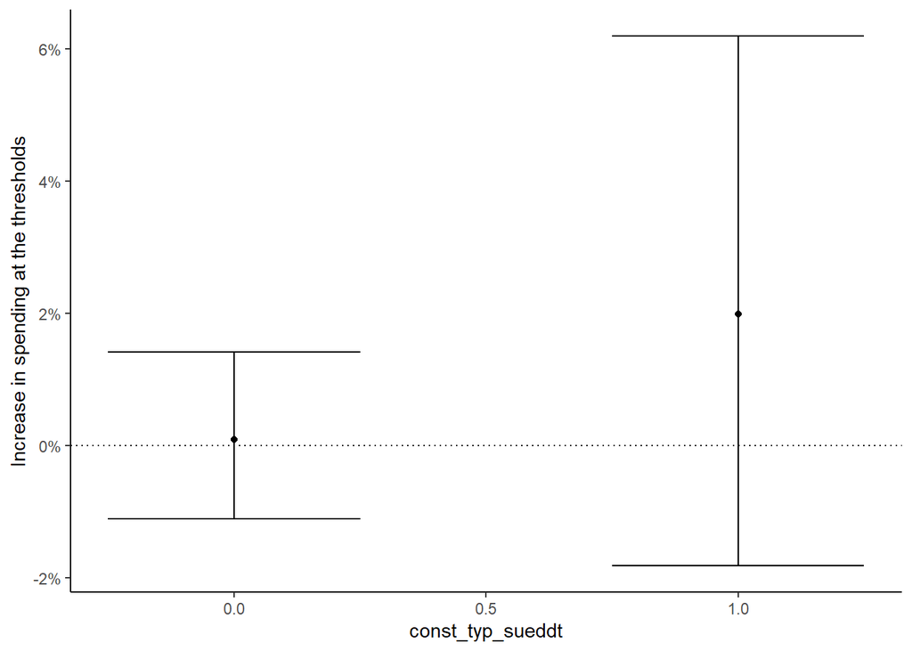

```r
ggplot2::ggplot(data = rdd_vary_const_type, aes(x = const_typ_sueddt, y = point_estimate)) +
  geom_point(size = 1.5, color = ifelse(rdd_vary_const_type$p <= p_value_cutoff, 2, 1)) +
  geom_errorbar(aes(ymin = ci_lower, ymax = ci_upper),
                color = ifelse(rdd_vary_const_type$p <= p_value_cutoff, 2, 1),
                linetype = ifelse(rdd_vary_const_type$p <= p_value_cutoff, 2, 1),
                width = 0.5) +
  geom_hline(aes(yintercept = 0), linetype = "dotted") +
  scale_y_continuous(labels = scales::percent) +
  labs(y = y_lab_RDD)
```

No differences visible.

Interaction-term method using an IV approach:

```r
df <- data %>%
  filter(closest <= 0.1)
rdd <- fixest::feols(ln_gross_expenditure_pc ~
                       1  | # controls
                       inhabitants_treshold_factor + state + year | # fixed-effect controls
                       # First stage regression:
                       inhabs_rel_to_cutoff*total_seats*const_typ_sueddt ~
                       inhabs_rel_to_cutoff*above_cutoff*const_typ_sueddt,
                     vcov = "threeway",
                     data = df)
```

```
## NOTE: 2,600 observations removed because of NA values (LHS: 2,600).
```

```
## Variance contained negative values in the diagonal and was 'fixed' (a la Cameron, Gelbach & Miller 2011).
```

```
## The endogenous regressor 'fit_const_typ_sueddt' have been removed because of collinearity (see $collin.var).
```

```r
summary(rdd)
```

```
## TSLS estimation, Dep. Var.: ln_gross_expenditure_pc, Endo.: inhabs_rel_to_cutoff, total_seats, const_typ_sueddt, inhabs_rel_to_cutoff:total_seats, inhabs_rel_to_cutoff:const_typ_sueddt, total_seats:const_typ_sueddt, inhabs_rel_to_cutoff:total_seats:const_typ_sueddt, Instr.: inhabs_rel_to_cutoff, …
## Second stage: Dep. Var.: ln_gross_expenditure_pc
## Observations: 12,964
## Fixed-effects: inhabitants_treshold_factor: 30,  state: 10,  year: 13
## Standard-errors: Clustered (inhabitants_treshold_factor & state & year)
##                                                        Estimate Std. Error
## fit_inhabs_rel_to_cutoff                              -4.936108  39.666360
## fit_total_seats                                       -0.013325   0.150461
## fit_inhabs_rel_to_cutoff:total_seats                   0.327036   3.963227
## fit_inhabs_rel_to_cutoff:const_typ_sueddt              6.063686  78.417723
## fit_total_seats:const_typ_sueddt                       0.034994   0.171518
## fit_inhabs_rel_to_cutoff:total_seats:const_typ_sueddt -0.436922   5.503271
##                                                         t value Pr(>|t|)
## fit_inhabs_rel_to_cutoff                              -0.124441  0.90370
## fit_total_seats                                       -0.088560  0.93137
## fit_inhabs_rel_to_cutoff:total_seats                   0.082518  0.93604
## fit_inhabs_rel_to_cutoff:const_typ_sueddt              0.077325  0.94006
## fit_total_seats:const_typ_sueddt                       0.204027  0.84287
## fit_inhabs_rel_to_cutoff:total_seats:const_typ_sueddt -0.079393  0.93846
## ... 2 variables were removed because of collinearity (fit_const_typ_sueddt and const_typ_sueddt)
## Important note: one endogenous regressor was removed => IV estimation not valid.
## ---
## Signif. codes:  0 '***' 0.001 '**' 0.01 '*' 0.05 '.' 0.1 ' ' 1
## RMSE: 1.58975     Adj. R2: -15.5
##                 Within R2: -28.4
## F-test (1st stage), inhabs_rel_to_cutoff                             : stat =      1.998e+30, p < 2.2e-16, on 6 and 12,957 DoF.
## F-test (1st stage), total_seats                                      : stat =    733.9      , p < 2.2e-16, on 6 and 12,957 DoF.
## F-test (1st stage), const_typ_sueddt                                 : stat =     NA        , p = NA     , on 6 and 12,957 DoF.
## F-test (1st stage), inhabs_rel_to_cutoff:total_seats                 : stat =  9,500.2      , p < 2.2e-16, on 6 and 12,957 DoF.
## F-test (1st stage), inhabs_rel_to_cutoff:const_typ_sueddt            : stat =      2.84e+30 , p < 2.2e-16, on 6 and 12,957 DoF.
## F-test (1st stage), total_seats:const_typ_sueddt                     : stat =    333.0      , p < 2.2e-16, on 6 and 12,957 DoF.
## F-test (1st stage), inhabs_rel_to_cutoff:total_seats:const_typ_sueddt: stat = 10,098.6      , p < 2.2e-16, on 6 and 12,957 DoF.
##                                                            Wu-Hausman: stat =     NA        , p = NA     , on 7 and 12,900 DoF.
```

```r
rm(df)
```

Local constititutional type does not matter.

### `const_typ_magistrat` – Magistratsverfassung

We should expect `const_typ_magistrat == 1` to be significant as it only consists of Hesse, which had a large positive effect in the state-heterogeneity section (subsection method).

Subsample method:

```r
data_subset <- data %>% # prepare data set used for analysis
  select(ln_gross_expenditure_pc, inhabs_rel_to_cutoff, total_seats, inhabitants_treshold_factor, state, year, const_typ_magistrat) %>%
  drop_na()
all_values <- data_subset %>% distinct(const_typ_magistrat) %>% pull() # vector of values
rdd_vary_const_type2 <- # prepare data set to store the results
  tibble(const_typ_magistrat = "", point_estimate = "", se = "", se_robust = "",
         ci_lower = "", ci_upper = "", p = "", bw = "", obs_below = "", obs_above = "") %>%
  mutate(across(everything(), as.numeric))
for (i in all_values) {
  print(paste("constitutional type:", i))
  df <- data_subset %>%
    filter(const_typ_magistrat == i)
  rdd <-
    rdrobust_wrapper(
      ccluster = df$inhabitants_treshold_factor,
      ccovs = model.matrix( ~ df$inhabitants_treshold_factor + df$state + df$year) # FE
  )
  #summary(rdd)
  rdd_vary_const_type2 <- rdd_vary_const_type2 %>%
    dplyr::add_row(
      const_typ_magistrat = i,
      point_estimate = rdd$coef[1],
      se = rdd$se[1],
      se_robust = rdd$se[3],
      ci_lower = rdd$ci[3,1],
      ci_upper = rdd$ci[3,2],
      p = rdd$pv[3],
      bw = rdd$bws[1,1],
      obs_below = rdd$N_h[1],
      obs_above = rdd$N_h[2]
  )
}
```

```
## [1] "constitutional type: 0"
## [1] "Mass points detected in the running variable."
## [1] "constitutional type: 1"
## [1] "Mass points detected in the running variable."
```

```r
rdd_vary_const_type2 <- rdd_vary_const_type2 %>% drop_na()
save(rdd_vary_const_type2, file = "tables_robustness_checks/rdd_vary_const_type2.Rdata")
rm(all_values, data_subset, df, i, rdd)
```

```r
load(file = "tables_robustness_checks/rdd_vary_const_type2.Rdata")
rdd_vary_const_type2
```

| const_typ_magistrat | point_estimate | se | se_robust | ci_lower | ci_upper | p | bw | obs_below | obs_above |
| --- | --- | --- | --- | --- | --- | --- | --- | --- | --- |
| 0 | 0.01418751 | 0.011966353 | 0.012446108 | -0.01637723 | 0.04774087 | 2.076772e-01 | 0.05515244 | 7716 | 8245 |
| 1 | 0.01600214 | 0.001688026 | 0.001765708 | 0.01363622 | 0.02273254 | 7.146719e-25 | 0.03235576 | 274 | 276 |

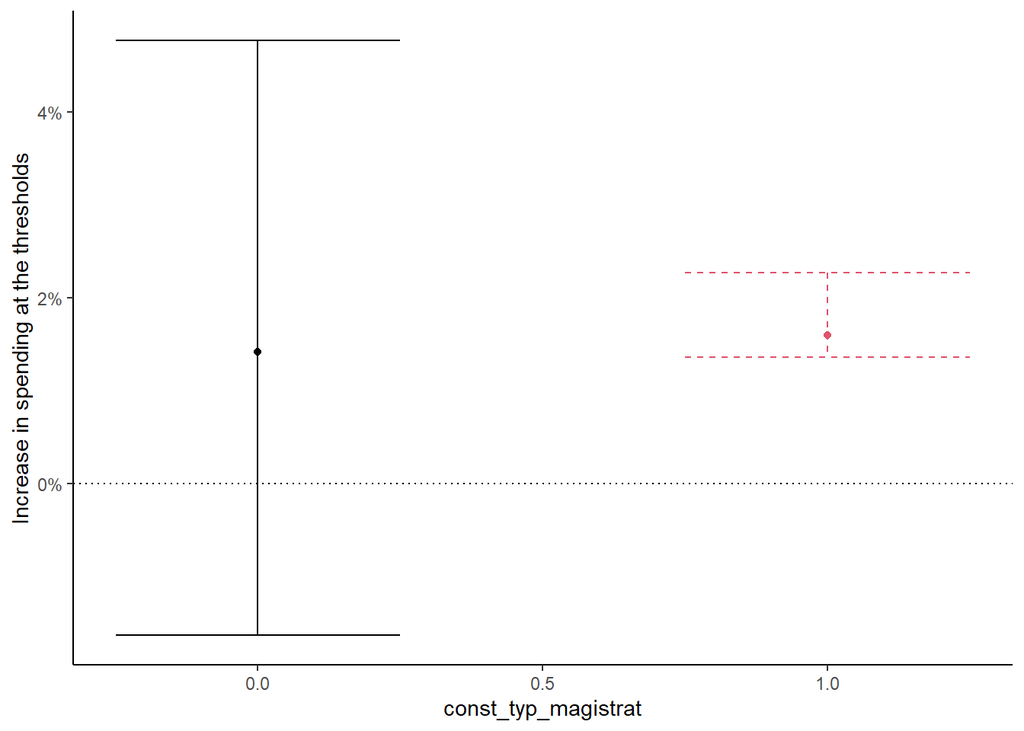

```r
ggplot2::ggplot(data = rdd_vary_const_type2, aes(x = const_typ_magistrat, y = point_estimate)) +
  geom_point(size = 1.5, color = ifelse(rdd_vary_const_type2$p <= p_value_cutoff, 2, 1)) +
  geom_errorbar(aes(ymin = ci_lower, ymax = ci_upper),
                color = ifelse(rdd_vary_const_type2$p <= p_value_cutoff, 2, 1),
                linetype = ifelse(rdd_vary_const_type2$p <= p_value_cutoff, 2, 1),
                width = 0.5) +
  geom_hline(aes(yintercept = 0), linetype = "dotted") +
  scale_y_continuous(labels = scales::percent) +
  labs(y = y_lab_RDD)
```

`const_typ_magistrat == 1` is significant, as expected (reasons see above).

Interaction-term method using an IV approach:

```r
df <- data %>%
  filter(closest <= 0.1)
rdd <- fixest::feols(ln_gross_expenditure_pc ~
                       1  | # controls
                       inhabitants_treshold_factor + state + year | # fixed-effect controls
                       # First stage regression:
                       inhabs_rel_to_cutoff*total_seats*const_typ_sueddt ~
                       inhabs_rel_to_cutoff*above_cutoff*const_typ_sueddt,
                     vcov = "threeway",
                     data = df)
```

```
## NOTE: 2,600 observations removed because of NA values (LHS: 2,600).
```

```
## Variance contained negative values in the diagonal and was 'fixed' (a la Cameron, Gelbach & Miller 2011).
```

```
## The endogenous regressor 'fit_const_typ_sueddt' have been removed because of collinearity (see $collin.var).
```

```r
summary(rdd)
```

```
## TSLS estimation, Dep. Var.: ln_gross_expenditure_pc, Endo.: inhabs_rel_to_cutoff, total_seats, const_typ_sueddt, inhabs_rel_to_cutoff:total_seats, inhabs_rel_to_cutoff:const_typ_sueddt, total_seats:const_typ_sueddt, inhabs_rel_to_cutoff:total_seats:const_typ_sueddt, Instr.: inhabs_rel_to_cutoff, …
## Second stage: Dep. Var.: ln_gross_expenditure_pc
## Observations: 12,964
## Fixed-effects: inhabitants_treshold_factor: 30,  state: 10,  year: 13
## Standard-errors: Clustered (inhabitants_treshold_factor & state & year)
##                                                        Estimate Std. Error
## fit_inhabs_rel_to_cutoff                              -4.936108  39.666360
## fit_total_seats                                       -0.013325   0.150461
## fit_inhabs_rel_to_cutoff:total_seats                   0.327036   3.963227
## fit_inhabs_rel_to_cutoff:const_typ_sueddt              6.063686  78.417723
## fit_total_seats:const_typ_sueddt                       0.034994   0.171518
## fit_inhabs_rel_to_cutoff:total_seats:const_typ_sueddt -0.436922   5.503271
##                                                         t value Pr(>|t|)
## fit_inhabs_rel_to_cutoff                              -0.124441  0.90370
## fit_total_seats                                       -0.088560  0.93137
## fit_inhabs_rel_to_cutoff:total_seats                   0.082518  0.93604
## fit_inhabs_rel_to_cutoff:const_typ_sueddt              0.077325  0.94006
## fit_total_seats:const_typ_sueddt                       0.204027  0.84287
## fit_inhabs_rel_to_cutoff:total_seats:const_typ_sueddt -0.079393  0.93846
## ... 2 variables were removed because of collinearity (fit_const_typ_sueddt and const_typ_sueddt)
## Important note: one endogenous regressor was removed => IV estimation not valid.
## ---
## Signif. codes:  0 '***' 0.001 '**' 0.01 '*' 0.05 '.' 0.1 ' ' 1
## RMSE: 1.58975     Adj. R2: -15.5
##                 Within R2: -28.4
## F-test (1st stage), inhabs_rel_to_cutoff                             : stat =      1.998e+30, p < 2.2e-16, on 6 and 12,957 DoF.
## F-test (1st stage), total_seats                                      : stat =    733.9      , p < 2.2e-16, on 6 and 12,957 DoF.
## F-test (1st stage), const_typ_sueddt                                 : stat =     NA        , p = NA     , on 6 and 12,957 DoF.
## F-test (1st stage), inhabs_rel_to_cutoff:total_seats                 : stat =  9,500.2      , p < 2.2e-16, on 6 and 12,957 DoF.
## F-test (1st stage), inhabs_rel_to_cutoff:const_typ_sueddt            : stat =      2.84e+30 , p < 2.2e-16, on 6 and 12,957 DoF.
## F-test (1st stage), total_seats:const_typ_sueddt                     : stat =    333.0      , p < 2.2e-16, on 6 and 12,957 DoF.
## F-test (1st stage), inhabs_rel_to_cutoff:total_seats:const_typ_sueddt: stat = 10,098.6      , p < 2.2e-16, on 6 and 12,957 DoF.
##                                                            Wu-Hausman: stat =     NA        , p = NA     , on 7 and 12,900 DoF.
```

```r
rm(df)
```

## Mayoral party affiliation

Bavarian data only!

Subsample method:

```r
data_subset <- data %>% # prepare data set used for analysis
  select(ln_gross_expenditure_pc, inhabs_rel_to_cutoff, total_seats, inhabitants_treshold_factor, state, year, ends_with("mayor"), closest, above_cutoff) %>%
  mutate(mayor_party_affiliation = case_when(
    cdu_csu_mayor == 0 & spd_mayor == 0 ~ "others",
    cdu_csu_mayor == 1 ~ "cdu_csu",
    spd_mayor == 1 ~ "spd"
  )) %>%
  drop_na()
table(data_subset$mayor_party_affiliation)
```

```
##
## cdu_csu  others     spd
##   11858   11305    3539
```

```r
all_values <- data_subset %>% distinct(mayor_party_affiliation) %>% pull() # vector of values
rdd_vary_may_affil <- # prepare data set to store the results
  tibble(mayor_party_affiliation = "", method = "", point_estimate = "", se = "", se_robust = "",
         ci_lower = "", ci_upper = "", p = "", bw = "", obs_below = "", obs_above = "") %>%
  mutate(across(3:last_col(), as.numeric))
for (i in all_values) {
  print(paste("Mayoral party affiliation:", i))
  df <- data_subset %>%
    filter(mayor_party_affiliation == i)
  print("fuzzy")
  rdd <-
    rdrobust_wrapper(
      ccluster = df$inhabitants_treshold_factor,
      ccovs = model.matrix( ~ df$inhabitants_treshold_factor + df$year) # Dropping year FE, obviously
  )
  rdd_vary_may_affil <- rdd_vary_may_affil %>%
    dplyr::add_row(
      mayor_party_affiliation = i,
      method = "fuzzy",
      point_estimate = rdd$coef[1],
      se = rdd$se[1],
      se_robust = rdd$se[3],
      ci_lower = rdd$ci[3,1],
      ci_upper = rdd$ci[3,2],
      p = rdd$pv[3],
      bw = rdd$bws[1,1],
      obs_below = rdd$N_h[1],
      obs_above = rdd$N_h[2]
  )
  print("sharp")
  rdd <-
    rdrobust::rdrobust(
      y = df$ln_gross_expenditure_pc,
      x = df$inhabs_rel_to_cutoff,
      #fuzzy = df$total_seats,
      cluster = df$inhabitants_treshold_factor,
      covs = model.matrix( ~ df$inhabitants_treshold_factor + df$year), # Dropping year FE, obviously
      level = (1-p_value_cutoff)*100
  )
  rdd_vary_may_affil <- rdd_vary_may_affil %>%
    dplyr::add_row(
      mayor_party_affiliation = i,
      method = "sharp",
      point_estimate = rdd$coef[1],
      se = rdd$se[1],
      se_robust = rdd$se[3],
      ci_lower = rdd$ci[3,1],
      ci_upper = rdd$ci[3,2],
      p = rdd$pv[3],
      bw = rdd$bws[1,1],
      obs_below = rdd$N_h[1],
      obs_above = rdd$N_h[2]
  )
}
```

```
## [1] "Mayoral party affiliation: cdu_csu"
## [1] "fuzzy"
## [1] "Mass points detected in the running variable."
## [1] "sharp"
## [1] "Mass points detected in the running variable."
## [1] "Mayoral party affiliation: others"
## [1] "fuzzy"
## [1] "Mass points detected in the running variable."
## [1] "sharp"
## [1] "Mass points detected in the running variable."
## [1] "Mayoral party affiliation: spd"
## [1] "fuzzy"
## [1] "Mass points detected in the running variable."
## [1] "sharp"
## [1] "Mass points detected in the running variable."
```

```r
rdd_vary_may_affil <- rdd_vary_may_affil %>%
  mutate(mayor_party_affiliation = case_when(
    mayor_party_affiliation == "cdu_csu" ~ "CDU/CSU",
    mayor_party_affiliation == "others" ~ "Others",
    mayor_party_affiliation == "spd" ~ "SPD"
  )) %>%
  drop_na()
save(rdd_vary_may_affil, file = "tables_robustness_checks/rdd_vary_may_affil.Rdata")
rm(all_values, df, i, rdd)
```

```r
load(file = "tables_robustness_checks/rdd_vary_may_affil.Rdata")
rdd_vary_may_affil
```

| mayor_party_affiliation | method | point_estimate | se | se_robust | ci_lower | ci_upper | p | bw | obs_below | obs_above |
| --- | --- | --- | --- | --- | --- | --- | --- | --- | --- | --- |
| CDU/CSU | fuzzy | -0.03719905 | 0.009306180 | 0.01073743 | -0.07055085 | -0.01523531 | 0.00006476888 | 0.05082468 | 1018 | 1001 |
| CDU/CSU | sharp | -0.06559803 | 0.020264600 | 0.02289043 | -0.12896624 | -0.01104256 | 0.00222642270 | 0.03784083 | 793 | 748 |
| Others | fuzzy | -0.02430616 | 0.013437595 | 0.01498818 | -0.06319661 | 0.01401739 | 0.10088053737 | 0.01654393 | 296 | 328 |
| Others | sharp | -0.01561772 | 0.014901000 | 0.01618821 | -0.05133225 | 0.03206386 | 0.55175211258 | 0.06891634 | 1253 | 1415 |
| SPD | fuzzy | -0.04651189 | 0.007579118 | 0.01245416 | -0.08495815 | -0.02079857 | 0.00002177767 | 0.02025061 | 113 | 110 |
| SPD | sharp | -0.01733324 | 0.013648118 | 0.01750086 | -0.06250287 | 0.02765558 | 0.31945040439 | 0.07717870 | 550 | 437 |

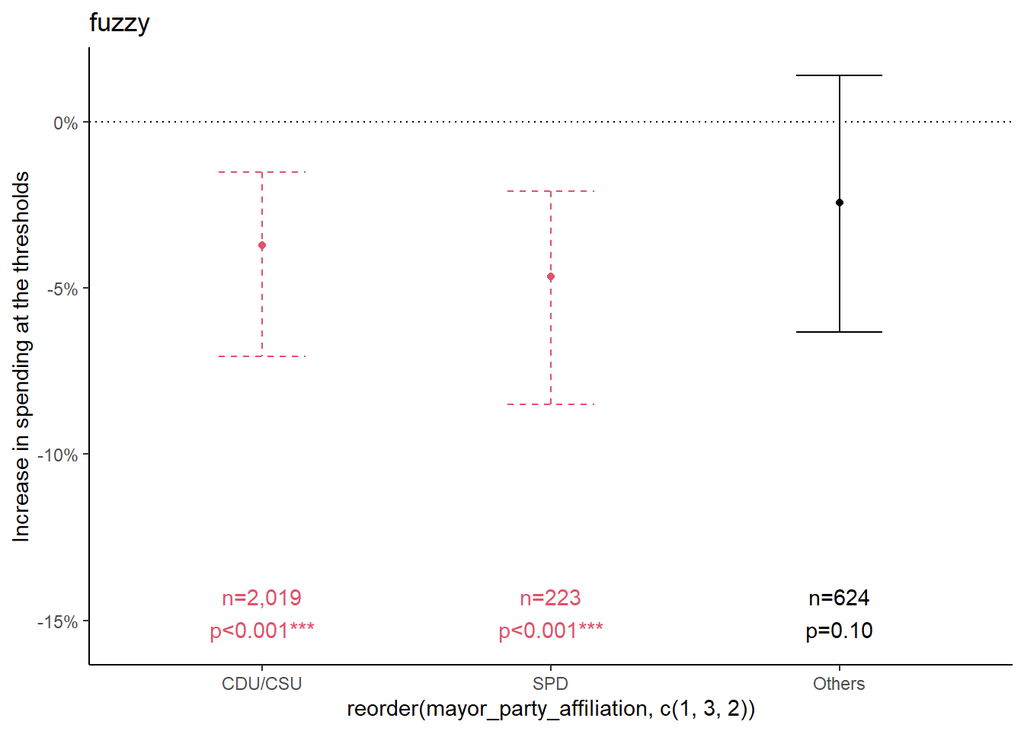

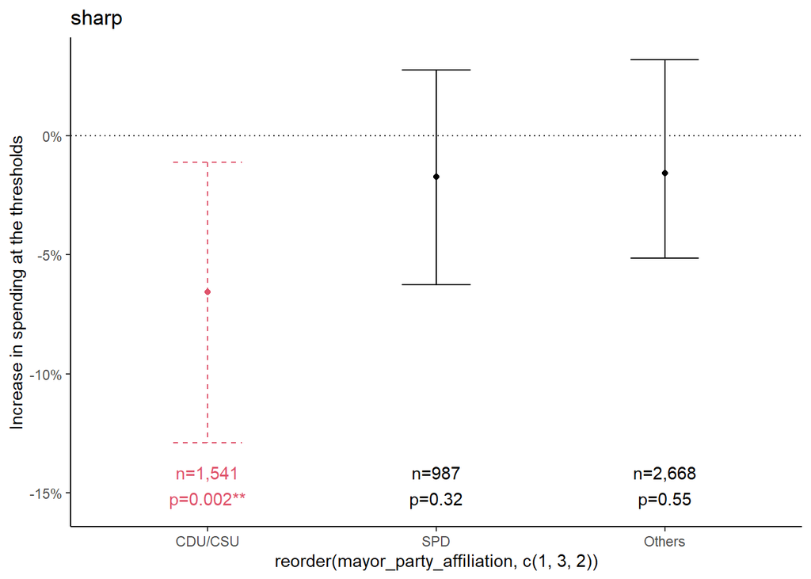

```r
for (i in c("fuzzy", "sharp")) {
  df <- rdd_vary_may_affil %>%
    filter(method == i) %>%
  rowwise() %>%
  mutate(note = paste0(
    "n=",
    trimws(format(sum(obs_below, obs_above), big.mark = ",")),
    "\n",
    p_value(p),
    assign_stars(p)
    )) %>%
  ungroup()
  p <- ggplot2::ggplot(data = df, aes(x = reorder(mayor_party_affiliation, c(1,3,2)),
                                      y = point_estimate)) +
    geom_point(size = 1.5, color = ifelse(df$p <= p_value_cutoff, 2, 1)) +
    geom_errorbar(aes(ymin = ci_lower, ymax = ci_upper),
                  color = ifelse(df$p <= p_value_cutoff, 2, 1),
                  linetype = ifelse(df$p <= p_value_cutoff, 2, 1),
                  width = 0.3) +
    geom_text(aes(y = -0.155, label = note),
            colour = ifelse(df$p <= p_value_cutoff, 2, 1), vjust = 0) +
    geom_hline(aes(yintercept = 0), linetype = "dotted") +
    scale_y_continuous(labels = scales::percent) +
    labs(y = y_lab_RDD, title = i)
  print(p)
}
```

```r
# Make plot "publication-ready":
p <- p +
  labs(x = NULL, title = NULL)
ggsave(filename = "plots/rdd_mayor_affiliation.pdf", plot = p, width = 6, height = 6*9/16)
rm(df, p)
```

Negative “Law of 1/n” effect found for Bavaria mainly driven by both CSU and SPD mayors. Mind the heterogeneity of the others category.

Interaction-term method in sharp approach:

```r
df <- data_subset %>% # Use data set from above
  filter(closest <= 0.1)
rdd <- fixest::feols(ln_gross_expenditure_pc ~
                       inhabs_rel_to_cutoff*above_cutoff*mayor_party_affiliation |
                       inhabitants_treshold_factor + year, # fixed-effect controls
                     vcov = "twoway",
                     data = df)
summary(rdd)
```

```
## OLS estimation, Dep. Var.: ln_gross_expenditure_pc
## Observations: 3,809
## Fixed-effects: inhabitants_treshold_factor: 9,  year: 13
## Standard-errors: Clustered (inhabitants_treshold_factor & year)
##                                                                  Estimate
## inhabs_rel_to_cutoff                                             1.706755
## above_cutoff                                                    -0.063361
## mayor_party_affiliationothers                                   -0.038976
## mayor_party_affiliationspd                                       0.095453
## inhabs_rel_to_cutoff:above_cutoff                               -0.953775
## inhabs_rel_to_cutoff:mayor_party_affiliationothers              -3.552201
## inhabs_rel_to_cutoff:mayor_party_affiliationspd                  3.396739
## above_cutoff:mayor_party_affiliationothers                       0.039946
## above_cutoff:mayor_party_affiliationspd                          0.059913
## inhabs_rel_to_cutoff:above_cutoff:mayor_party_affiliationothers  4.544509
## inhabs_rel_to_cutoff:above_cutoff:mayor_party_affiliationspd    -9.048316
##                                                                 Std. Error
## inhabs_rel_to_cutoff                                              1.810603
## above_cutoff                                                      0.060768
## mayor_party_affiliationothers                                     0.102414
## mayor_party_affiliationspd                                        0.137137
## inhabs_rel_to_cutoff:above_cutoff                                 1.351120
## inhabs_rel_to_cutoff:mayor_party_affiliationothers                3.987957
## inhabs_rel_to_cutoff:mayor_party_affiliationspd                   2.903074
## above_cutoff:mayor_party_affiliationothers                        0.082913
## above_cutoff:mayor_party_affiliationspd                           0.067396
## inhabs_rel_to_cutoff:above_cutoff:mayor_party_affiliationothers   4.447539
## inhabs_rel_to_cutoff:above_cutoff:mayor_party_affiliationspd      6.480151
##                                                                   t value
## inhabs_rel_to_cutoff                                             0.942644
## above_cutoff                                                    -1.042670
## mayor_party_affiliationothers                                   -0.380573
## mayor_party_affiliationspd                                       0.696042
## inhabs_rel_to_cutoff:above_cutoff                               -0.705914
## inhabs_rel_to_cutoff:mayor_party_affiliationothers              -0.890732
## inhabs_rel_to_cutoff:mayor_party_affiliationspd                  1.170049
## above_cutoff:mayor_party_affiliationothers                       0.481781
## above_cutoff:mayor_party_affiliationspd                          0.888978
## inhabs_rel_to_cutoff:above_cutoff:mayor_party_affiliationothers  1.021803
## inhabs_rel_to_cutoff:above_cutoff:mayor_party_affiliationspd    -1.396312
##                                                                 Pr(>|t|)
## inhabs_rel_to_cutoff                                             0.37345
## above_cutoff                                                     0.32758
## mayor_party_affiliationothers                                    0.71343
## mayor_party_affiliationspd                                       0.50612
## inhabs_rel_to_cutoff:above_cutoff                                0.50028
## inhabs_rel_to_cutoff:mayor_party_affiliationothers               0.39907
## inhabs_rel_to_cutoff:mayor_party_affiliationspd                  0.27566
## above_cutoff:mayor_party_affiliationothers                       0.64286
## above_cutoff:mayor_party_affiliationspd                          0.39996
## inhabs_rel_to_cutoff:above_cutoff:mayor_party_affiliationothers  0.33678
## inhabs_rel_to_cutoff:above_cutoff:mayor_party_affiliationspd     0.20015
## ---
## Signif. codes:  0 '***' 0.001 '**' 0.01 '*' 0.05 '.' 0.1 ' ' 1
## RMSE: 0.278547     Adj. R2: 0.231142
##                  Within R2: 0.012272
```

```r
# joint test on interactions
fixest::wald(rdd, "above_cutoff:mayor_party_affiliation")
```

```
## Wald test, H0: joint nullity of above_cutoff:mayor_party_affiliationothers, above_cutoff:mayor_party_affiliationspd, inhabs_rel_to_cutoff:above_cutoff:mayor_party_affiliationothers and inhabs_rel_to_cutoff:above_cutoff:mayor_party_affiliationspd
##  stat = 4.44098, p-value = 0.001395, on 4 and 3,777 DoF, VCOV: Clustered (inhabitants_treshold_factor & year).
```

Interaction-term method using an IV approach (fuzzy):

```r
df <- data_subset %>% # Use data set from above
  filter(closest <= 0.1)
rdd <- fixest::feols(ln_gross_expenditure_pc ~
                       1  | # controls
                       inhabitants_treshold_factor + year | # fixed-effect controls
                       # First stage regression:
                       inhabs_rel_to_cutoff*total_seats*mayor_party_affiliation ~
                       inhabs_rel_to_cutoff*above_cutoff*mayor_party_affiliation,
                     vcov = "twoway",
                     data = df)
summary(rdd)
```

```
## TSLS estimation, Dep. Var.: ln_gross_expenditure_pc, Endo.: inhabs_rel_to_cutoff, total_seats, mayor_party_affiliation, inhabs_rel_to_cutoff:total_seats, inhabs_rel_to_cutoff:mayor_party_affiliation, total_seats:mayor_party_affiliation, inhabs_rel_to_cutoff:total_seats:mayor_party_affiliation, In…
## Second stage: Dep. Var.: ln_gross_expenditure_pc
## Observations: 3,809
## Fixed-effects: inhabitants_treshold_factor: 9,  year: 13
## Standard-errors: Clustered (inhabitants_treshold_factor & year)
##                                                                      Estimate
## fit_inhabs_rel_to_cutoff                                            11.259651
## fit_total_seats                                                     -0.021255
## fit_mayor_party_affiliationothers                                   -0.296362
## fit_mayor_party_affiliationspd                                      -0.772654
## fit_inhabs_rel_to_cutoff:total_seats                                -0.629856
## fit_inhabs_rel_to_cutoff:mayor_party_affiliationothers             -24.419938
## fit_inhabs_rel_to_cutoff:mayor_party_affiliationspd                 19.894298
## fit_total_seats:mayor_party_affiliationothers                        0.017576
## fit_total_seats:mayor_party_affiliationspd                           0.047555
## fit_inhabs_rel_to_cutoff:total_seats:mayor_party_affiliationothers   1.495989
## fit_inhabs_rel_to_cutoff:total_seats:mayor_party_affiliationspd     -1.192536
##                                                                    Std. Error
## fit_inhabs_rel_to_cutoff                                            18.775010
## fit_total_seats                                                      0.028295
## fit_mayor_party_affiliationothers                                    0.875515
## fit_mayor_party_affiliationspd                                       0.324516
## fit_inhabs_rel_to_cutoff:total_seats                                 1.093375
## fit_inhabs_rel_to_cutoff:mayor_party_affiliationothers              24.253786
## fit_inhabs_rel_to_cutoff:mayor_party_affiliationspd                 33.323420
## fit_total_seats:mayor_party_affiliationothers                        0.053175
## fit_total_seats:mayor_party_affiliationspd                           0.022989
## fit_inhabs_rel_to_cutoff:total_seats:mayor_party_affiliationothers   1.422748
## fit_inhabs_rel_to_cutoff:total_seats:mayor_party_affiliationspd      2.168372
##                                                                      t value
## fit_inhabs_rel_to_cutoff                                            0.599715
## fit_total_seats                                                    -0.751172
## fit_mayor_party_affiliationothers                                  -0.338500
## fit_mayor_party_affiliationspd                                     -2.380948
## fit_inhabs_rel_to_cutoff:total_seats                               -0.576066
## fit_inhabs_rel_to_cutoff:mayor_party_affiliationothers             -1.006851
## fit_inhabs_rel_to_cutoff:mayor_party_affiliationspd                 0.597006
## fit_total_seats:mayor_party_affiliationothers                       0.330532
## fit_total_seats:mayor_party_affiliationspd                          2.068551
## fit_inhabs_rel_to_cutoff:total_seats:mayor_party_affiliationothers  1.051478
```

[output cut: 14 more lines]

```
## Signif. codes:  0 '***' 0.001 '**' 0.01 '*' 0.05 '.' 0.1 ' ' 1
## RMSE: 0.319627     Adj. R2: -0.012361
##                  Within R2: -0.300548
## F-test (1st stage), inhabs_rel_to_cutoff                                          : stat =     1.588e+31, p < 2.2e-16, on 11 and 3,797 DoF.
## F-test (1st stage), total_seats                                                   : stat =   595.2      , p < 2.2e-16, on 11 and 3,797 DoF.
## F-test (1st stage), mayor_party_affiliationothers                                 : stat =     3.92e+31 , p < 2.2e-16, on 11 and 3,797 DoF.
## F-test (1st stage), mayor_party_affiliationspd                                    : stat =     5.103e+31, p < 2.2e-16, on 11 and 3,797 DoF.
## F-test (1st stage), inhabs_rel_to_cutoff:total_seats                              : stat = 3,188.6      , p < 2.2e-16, on 11 and 3,797 DoF.
## F-test (1st stage), inhabs_rel_to_cutoff:mayor_party_affiliationothers            : stat =     1.31e+31 , p < 2.2e-16, on 11 and 3,797 DoF.
## F-test (1st stage), inhabs_rel_to_cutoff:mayor_party_affiliationspd               : stat =     5.415e+31, p < 2.2e-16, on 11 and 3,797 DoF.
## F-test (1st stage), total_seats:mayor_party_affiliationothers                     : stat = 4,510.8      , p < 2.2e-16, on 11 and 3,797 DoF.
## F-test (1st stage), total_seats:mayor_party_affiliationspd                        : stat = 3,167.0      , p < 2.2e-16, on 11 and 3,797 DoF.
## F-test (1st stage), inhabs_rel_to_cutoff:total_seats:mayor_party_affiliationothers: stat = 3,702.1      , p < 2.2e-16, on 11 and 3,797 DoF.
## F-test (1st stage), inhabs_rel_to_cutoff:total_seats:mayor_party_affiliationspd   : stat = 3,716.1      , p < 2.2e-16, on 11 and 3,797 DoF.
##                                                                         Wu-Hausman: stat =    NA        , p = NA     , on 11 and 3,766 DoF.
```

```r
# joint test on interactions
fixest::wald(rdd, "fit_total_seats:mayor_party_affiliation")
```

```
## Wald test, H0: joint nullity of fit_total_seats:mayor_party_affiliationothers and fit_total_seats:mayor_party_affiliationspd
##  stat = 4.49308, p-value = 0.011246, on 2 and 3,777 DoF, VCOV: Clustered (inhabitants_treshold_factor & year).
```

```r
rm(df, data_subset)
```

The baseline effect for CSU mayors is -2.1 % (nonsignificant). The “individual” effects for others and SPD are not significantly different from zero either (SPD only at 10 %, others not at all). However, the joint significance test for differences from CSU mayors is significant at p = 0.05. Both SPD and other mayors seem to drive the effect up.

## Parties in parliament

Number of parties in parliament is presumably biased downwards – Number of parties in parliament (biased downwards b/c of aggregates (others, waehlergruppen)!)

More sophisticated analysis is possible by weighting the number of parties in parliament, e. g. Herfindahl index.

### `number_of_parties` in parliament variable

Subsample method:

```r
data_subset <- data %>% # prepare data set used for analysis
  select(ln_gross_expenditure_pc, inhabs_rel_to_cutoff, total_seats, inhabitants_treshold_factor, state, year, no_parties_in_parliament) %>%
  drop_na()
table(data_subset$state)
```

```
##
##     5     8     9    10    13    14
##  2772 13710 26702   364    54  4887
```

```r
all_values <- data_subset %>%
  arrange(no_parties_in_parliament) %>%
  filter(no_parties_in_parliament <= 7) %>%
  distinct(no_parties_in_parliament) %>%
  pull() # vector of values
rdd_vary_no_of_part <- # prepare data set to store the results
  tibble(no_parties_in_parliament = "", point_estimate = "", se = "", se_robust = "",
         ci_lower = "", ci_upper = "", p = "", bw = "", obs_below = "", obs_above = "") %>%
  mutate(across(everything(), as.numeric))
for (i in all_values) {
  print(paste("no_parties_in_parliament:", i))
  df <- data_subset %>%
    filter(no_parties_in_parliament == i)
  rdd <-
    rdrobust_wrapper(
      ccluster = df$inhabitants_treshold_factor,
      ccovs = model.matrix( ~ df$inhabitants_treshold_factor + df$state + df$year) # FE
  )
  #summary(rdd)
  rdd_vary_no_of_part <- rdd_vary_no_of_part %>%
    dplyr::add_row(
      no_parties_in_parliament = i,
      point_estimate = rdd$coef[1],
      se = rdd$se[1],
      se_robust = rdd$se[3],
      ci_lower = rdd$ci[3,1],
      ci_upper = rdd$ci[3,2],
      p = rdd$pv[3],
      bw = rdd$bws[1,1],
      obs_below = rdd$N_h[1],
      obs_above = rdd$N_h[2]
  )
}
```

```
## [1] "no_parties_in_parliament: 1"
## [1] "Mass points detected in the running variable."
## [1] "no_parties_in_parliament: 2"
## [1] "Mass points detected in the running variable."
## [1] "no_parties_in_parliament: 3"
## [1] "Mass points detected in the running variable."
## [1] "no_parties_in_parliament: 4"
## [1] "Mass points detected in the running variable."
## [1] "no_parties_in_parliament: 5"
## [1] "Mass points detected in the running variable."
## [1] "no_parties_in_parliament: 6"
## [1] "Mass points detected in the running variable."
## [1] "no_parties_in_parliament: 7"
## [1] "Mass points detected in the running variable."
```

```r
rdd_vary_no_of_part <- rdd_vary_no_of_part %>% drop_na()
save(rdd_vary_no_of_part, file = "tables_robustness_checks/rdd_vary_no_of_part.Rdata")
rm(all_values, data_subset, df, i, rdd)
```

```r
load(file = "tables_robustness_checks/rdd_vary_no_of_part.Rdata")
rdd_vary_no_of_part
```

| no_parties_in_parliament | point_estimate | se | se_robust | ci_lower | ci_upper | p | bw | obs_below | obs_above |
| --- | --- | --- | --- | --- | --- | --- | --- | --- | --- |
| 1 | 0.022503584 | 0.018223964 | 0.021159217 | -0.02624245 | 0.082762615 | 0.18168261 | 0.06568362 | 823 | 924 |
| 2 | -0.024595140 | 0.011139569 | 0.012698629 | -0.05990089 | 0.005518104 | 0.03225098 | 0.07116059 | 1335 | 1355 |
| 3 | -0.008805305 | 0.009330361 | 0.009789425 | -0.03451292 | 0.015918856 | 0.34226391 | 0.04772917 | 1368 | 1454 |
| 4 | 0.014182312 | 0.014164815 | 0.017525561 | -0.03222947 | 0.058056243 | 0.46122473 | 0.07292571 | 904 | 924 |
| 5 | 0.019514349 | 0.011399980 | 0.014023776 | -0.02311041 | 0.049135301 | 0.35346739 | 0.10915035 | 766 | 759 |
| 6 | -0.016190500 | 0.005744014 | 0.008510843 | -0.04865199 | -0.004807031 | 0.00168578 | 0.03988743 | 50 | 73 |
| 7 | 0.036774784 | 0.026437622 | 0.027934582 | -0.03084035 | 0.113069078 | 0.14107254 | 0.04121297 | 21 | 21 |

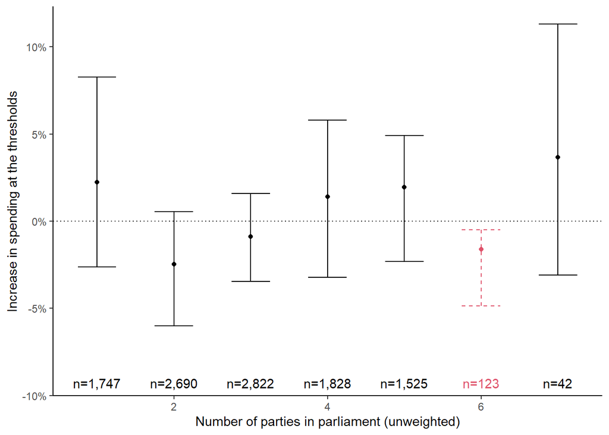

```r
df <- rdd_vary_no_of_part %>%
  rowwise() %>%
  mutate(effective_n = paste0("n=", trimws(format(sum(obs_below, obs_above), big.mark = ",")))) %>%
  ungroup()
ggplot2::ggplot(data = df, aes(x = no_parties_in_parliament, y = point_estimate)) +
  geom_point(size = 1.5, color = ifelse(df$p <= p_value_cutoff, 2, 1)) +
  geom_errorbar(aes(ymin = ci_lower, ymax = ci_upper),
                color = ifelse(df$p <= p_value_cutoff, 2, 1),
                linetype = ifelse(df$p <= p_value_cutoff, 2, 1),
                width = 0.5) +
  geom_text(aes(y = -0.09, label = effective_n),
            colour = ifelse(df$p <= p_value_cutoff, 2, 1), vjust = 1) +
  geom_hline(aes(yintercept = 0), linetype = "dotted") +
  scale_y_continuous(labels = scales::percent) +
  labs(x = "Number of parties in parliament (unweighted)",
       y = y_lab_RDD)
```

```r
rm(df)
```

To me, it does not look like there is much treatment effect variation.

Interaction-term method using an IV approach:

```r
df <- data %>%
  filter(closest <= 0.1) %>%
  mutate(no_parties_in_parliament2 = as.factor(no_parties_in_parliament))
# no_parties_in_parliament categorically
rdd <- fixest::feols(ln_gross_expenditure_pc ~
                       1  | # controls
                       inhabitants_treshold_factor + state + year | # fixed-effect controls
                       # First stage regression:
                       inhabs_rel_to_cutoff*total_seats*no_parties_in_parliament2 ~
                       inhabs_rel_to_cutoff*above_cutoff*no_parties_in_parliament2,
                     vcov = "threeway",
                     data = df)
```

```
## NOTE: 8,521 observations removed because of NA values (LHS: 2,600, IV: 7,160/7,160).
```

[output not shown]

```
## The endogenous regressor 'fit_inhabs_rel_to_cutoff:total_seats:no_parties_in_parliament28' have been removed because of collinearity (see $collin.var).
```

```r
summary(rdd)
```

```
## TSLS estimation, Dep. Var.: ln_gross_expenditure_pc, Endo.: inhabs_rel_to_cutoff, total_seats, no_parties_in_parliament2, inhabs_rel_to_cutoff:total_seats, inhabs_rel_to_cutoff:no_parties_in_parliament2, total_seats:no_parties_in_parliament2, inhabs_rel_to_cutoff:total_seats:no_parties_in_parliam…
## Second stage: Dep. Var.: ln_gross_expenditure_pc
## Observations: 7,043
## Fixed-effects: inhabitants_treshold_factor: 19,  state: 6,  year: 13
## Standard-errors: Clustered (inhabitants_treshold_factor & state & year)
##                                                                    Estimate
## fit_inhabs_rel_to_cutoff                                         -15.939844
## fit_total_seats                                                    0.073090
## fit_no_parties_in_parliament22                                     1.980405
## fit_no_parties_in_parliament23                                     0.974767
## fit_no_parties_in_parliament24                                    -0.125040
## fit_no_parties_in_parliament25                                     0.600473
## fit_no_parties_in_parliament26                                     2.017392
## fit_no_parties_in_parliament27                                    -1.556202
## fit_no_parties_in_parliament28                                  -383.275673
## fit_inhabs_rel_to_cutoff:total_seats                               1.064358
## fit_inhabs_rel_to_cutoff:no_parties_in_parliament22                4.255466
## fit_inhabs_rel_to_cutoff:no_parties_in_parliament23               43.232310
## fit_inhabs_rel_to_cutoff:no_parties_in_parliament24               19.390256
## fit_inhabs_rel_to_cutoff:no_parties_in_parliament25             -147.770446
## fit_inhabs_rel_to_cutoff:no_parties_in_parliament26               -0.066203
## fit_inhabs_rel_to_cutoff:no_parties_in_parliament27               81.769113
## fit_inhabs_rel_to_cutoff:no_parties_in_parliament28              -13.388554
## fit_total_seats:no_parties_in_parliament22                        -0.154634
## fit_total_seats:no_parties_in_parliament23                        -0.078796
## fit_total_seats:no_parties_in_parliament24                        -0.026479
## fit_total_seats:no_parties_in_parliament25                        -0.059255
## fit_total_seats:no_parties_in_parliament26                        -0.113105
## fit_total_seats:no_parties_in_parliament27                         0.007888
## fit_total_seats:no_parties_in_parliament28                        11.220761
## fit_inhabs_rel_to_cutoff:total_seats:no_parties_in_parliament22   -0.020379
## fit_inhabs_rel_to_cutoff:total_seats:no_parties_in_parliament23   -2.698589
## fit_inhabs_rel_to_cutoff:total_seats:no_parties_in_parliament24   -1.265248
## fit_inhabs_rel_to_cutoff:total_seats:no_parties_in_parliament25    4.590697
## fit_inhabs_rel_to_cutoff:total_seats:no_parties_in_parliament26   -0.328227
## fit_inhabs_rel_to_cutoff:total_seats:no_parties_in_parliament27   -3.367166
##                                                                    Std. Error
## fit_inhabs_rel_to_cutoff                                            14.047542
## fit_total_seats                                                      0.104346
## fit_no_parties_in_parliament22                                       2.610717
```

[output cut: 112 more lines]

```
## F-test (1st stage), total_seats:no_parties_in_parliament22                     : stat = 3,001.9      , p < 2.2e-16, on 30 and 7,012 DoF.
## F-test (1st stage), total_seats:no_parties_in_parliament23                     : stat = 2,919.7      , p < 2.2e-16, on 30 and 7,012 DoF.
## F-test (1st stage), total_seats:no_parties_in_parliament24                     : stat = 2,283.4      , p < 2.2e-16, on 30 and 7,012 DoF.
## F-test (1st stage), total_seats:no_parties_in_parliament25                     : stat = 1,777.7      , p < 2.2e-16, on 30 and 7,012 DoF.
## F-test (1st stage), total_seats:no_parties_in_parliament26                     : stat = 1,655.4      , p < 2.2e-16, on 30 and 7,012 DoF.
## F-test (1st stage), total_seats:no_parties_in_parliament27                     : stat = 2,787.2      , p < 2.2e-16, on 30 and 7,012 DoF.
## F-test (1st stage), total_seats:no_parties_in_parliament28                     : stat =     1.669e+16, p < 2.2e-16, on 30 and 7,012 DoF.
## F-test (1st stage), inhabs_rel_to_cutoff:total_seats:no_parties_in_parliament22: stat = 3,045.6      , p < 2.2e-16, on 30 and 7,012 DoF.
## F-test (1st stage), inhabs_rel_to_cutoff:total_seats:no_parties_in_parliament23: stat = 3,842.8      , p < 2.2e-16, on 30 and 7,012 DoF.
## F-test (1st stage), inhabs_rel_to_cutoff:total_seats:no_parties_in_parliament24: stat = 1,992.9      , p < 2.2e-16, on 30 and 7,012 DoF.
## F-test (1st stage), inhabs_rel_to_cutoff:total_seats:no_parties_in_parliament25: stat = 2,112.2      , p < 2.2e-16, on 30 and 7,012 DoF.
## F-test (1st stage), inhabs_rel_to_cutoff:total_seats:no_parties_in_parliament26: stat = 1,794.9      , p < 2.2e-16, on 30 and 7,012 DoF.
## F-test (1st stage), inhabs_rel_to_cutoff:total_seats:no_parties_in_parliament27: stat = 1,809.4      , p < 2.2e-16, on 30 and 7,012 DoF.
## F-test (1st stage), inhabs_rel_to_cutoff:total_seats:no_parties_in_parliament28: stat =     2.792e+13, p < 2.2e-16, on 30 and 7,012 DoF.
##                                                                      Wu-Hausman: stat =    NA        , p = NA     , on 31 and 6,946 DoF.
```

```r
# joint test on interactions
fixest::wald(rdd, "fit_total_seats:no_parties_in_parliament2")
```

```
## Wald test, H0: joint nullity of fit_total_seats:no_parties_in_parliament22, fit_total_seats:no_parties_in_parliament23, fit_total_seats:no_parties_in_parliament24, fit_total_seats:no_parties_in_parliament25, fit_total_seats:no_parties_in_parliament26, fit_total_seats:no_parties_in_parliament27 an…
##  stat = 1.02143, p-value = 0.41354, on 7 and 6,977 DoF, VCOV: Clustered (inhabitants_treshold_factor & state & year).
```

```r
# no_parties_in_parliament continuously
rdd <- fixest::feols(ln_gross_expenditure_pc ~
                       1  | # controls
                       inhabitants_treshold_factor + state + year | # fixed-effect controls
                       # First stage regression:
                       inhabs_rel_to_cutoff*total_seats*no_parties_in_parliament ~
                       inhabs_rel_to_cutoff*above_cutoff*no_parties_in_parliament,
                     vcov = "threeway",
                     data = df)
```

```
## NOTE: 8,521 observations removed because of NA values (LHS: 2,600, IV: 7,160/7,160).
```

```
## Variance contained negative values in the diagonal and was 'fixed' (a la Cameron, Gelbach & Miller 2011).
```

```r
summary(rdd)
```

```
## TSLS estimation, Dep. Var.: ln_gross_expenditure_pc, Endo.: inhabs_rel_to_cutoff, total_seats, no_parties_in_parliament, inhabs_rel_to_cutoff:total_seats, inhabs_rel_to_cutoff:no_parties_in_parliament, total_seats:no_parties_in_parliament, inhabs_rel_to_cutoff:total_seats:no_parties_in_parliament…
## Second stage: Dep. Var.: ln_gross_expenditure_pc
## Observations: 7,043
## Fixed-effects: inhabitants_treshold_factor: 19,  state: 6,  year: 13
## Standard-errors: Clustered (inhabitants_treshold_factor & state & year)
##                                                                 Estimate
## fit_inhabs_rel_to_cutoff                                      -20.821425
## fit_total_seats                                                -0.045827
## fit_no_parties_in_parliament                                   -0.210890
## fit_inhabs_rel_to_cutoff:total_seats                            0.426659
## fit_inhabs_rel_to_cutoff:no_parties_in_parliament              16.363101
## fit_total_seats:no_parties_in_parliament                        0.012408
## fit_inhabs_rel_to_cutoff:total_seats:no_parties_in_parliament  -0.580846
##                                                               Std. Error
## fit_inhabs_rel_to_cutoff                                       12.887200
## fit_total_seats                                                 0.046509
## fit_no_parties_in_parliament                                    0.376670
## fit_inhabs_rel_to_cutoff:total_seats                            1.589655
## fit_inhabs_rel_to_cutoff:no_parties_in_parliament              25.629433
## fit_total_seats:no_parties_in_parliament                        0.019754
## fit_inhabs_rel_to_cutoff:total_seats:no_parties_in_parliament   0.658658
##                                                                 t value
## fit_inhabs_rel_to_cutoff                                      -1.615667
## fit_total_seats                                               -0.985342
## fit_no_parties_in_parliament                                  -0.559881
## fit_inhabs_rel_to_cutoff:total_seats                           0.268397
## fit_inhabs_rel_to_cutoff:no_parties_in_parliament              0.638450
## fit_total_seats:no_parties_in_parliament                       0.628106
## fit_inhabs_rel_to_cutoff:total_seats:no_parties_in_parliament -0.881862
##                                                               Pr(>|t|)
## fit_inhabs_rel_to_cutoff                                       0.16709
## fit_total_seats                                                0.36970
## fit_no_parties_in_parliament                                   0.59971
## fit_inhabs_rel_to_cutoff:total_seats                           0.79912
## fit_inhabs_rel_to_cutoff:no_parties_in_parliament              0.55127
## fit_total_seats:no_parties_in_parliament                       0.55750
## fit_inhabs_rel_to_cutoff:total_seats:no_parties_in_parliament  0.41822
## ---
## Signif. codes:  0 '***' 0.001 '**' 0.01 '*' 0.05 '.' 0.1 ' ' 1
## RMSE: 0.388375     Adj. R2: -0.642983
##                  Within R2: -1.38707
## F-test (1st stage), inhabs_rel_to_cutoff                                     : stat =      3.403e+31, p < 2.2e-16, on 7 and 7,035 DoF.
## F-test (1st stage), total_seats                                              : stat =    224.1      , p < 2.2e-16, on 7 and 7,035 DoF.
## F-test (1st stage), no_parties_in_parliament                                 : stat =      2.885e+32, p < 2.2e-16, on 7 and 7,035 DoF.
## F-test (1st stage), inhabs_rel_to_cutoff:total_seats                         : stat = 10,380.3      , p < 2.2e-16, on 7 and 7,035 DoF.
## F-test (1st stage), inhabs_rel_to_cutoff:no_parties_in_parliament            : stat =      2.481e+30, p < 2.2e-16, on 7 and 7,035 DoF.
## F-test (1st stage), total_seats:no_parties_in_parliament                     : stat =  2,081.7      , p < 2.2e-16, on 7 and 7,035 DoF.
## F-test (1st stage), inhabs_rel_to_cutoff:total_seats:no_parties_in_parliament: stat =  7,225.5      , p < 2.2e-16, on 7 and 7,035 DoF.
##                                                                    Wu-Hausman: stat =     NA        , p = NA     , on 7 and 6,993 DoF.
```

```r
rm(df)
```

Treatment effect (“Law of 1/n”) does not vary in the number of parties in parliament.

### HHI

Subsample method:

```r
data_subset <- data %>% # prepare data set used for analysis
  select(ln_gross_expenditure_pc, inhabs_rel_to_cutoff, total_seats, inhabitants_treshold_factor, state, year, parties_in_parliament_hhi) %>%
  mutate(parties_in_parliament_hhi_quant = cut(
    parties_in_parliament_hhi,
    breaks = c(quantile(parties_in_parliament_hhi, seq(0, 1, 0.25), na.rm = TRUE))
    )) %>%
  drop_na()
all_values <- data_subset %>% distinct(parties_in_parliament_hhi_quant) %>% pull() # vector of values
rdd_vary_no_of_part2 <- # prepare data set to store the results
  tibble(parties_in_parliament_hhi_quant = "", point_estimate = "", se = "", se_robust = "",
         ci_lower = "", ci_upper = "", p = "", bw = "", obs_below = "", obs_above = "") %>%
  mutate(across(2:last_col(), as.numeric))
for (i in all_values) {
  print(paste("parties_in_parliament_hhi_quant:", i))
  df <- data_subset %>%
    filter(parties_in_parliament_hhi_quant == i)
  rdd <-
    rdrobust_wrapper(
      ccluster = df$inhabitants_treshold_factor,
      ccovs = model.matrix( ~ df$inhabitants_treshold_factor + df$state + df$year) # FE
  )
  #summary(rdd)
  rdd_vary_no_of_part2 <- rdd_vary_no_of_part2 %>%
    dplyr::add_row(
      parties_in_parliament_hhi_quant = i,
      point_estimate = rdd$coef[1],
      se = rdd$se[1],
      se_robust = rdd$se[3],
      ci_lower = rdd$ci[3,1],
      ci_upper = rdd$ci[3,2],
      p = rdd$pv[3],
      bw = rdd$bws[1,1],
      obs_below = rdd$N_h[1],
      obs_above = rdd$N_h[2]
  )
}
```

```
## [1] "parties_in_parliament_hhi_quant: (0.352,0.441]"
## [1] "Mass points detected in the running variable."
## [1] "parties_in_parliament_hhi_quant: (0.161,0.352]"
## [1] "Mass points detected in the running variable."
## [1] "parties_in_parliament_hhi_quant: (0.441,0.594]"
## [1] "Mass points detected in the running variable."
## [1] "parties_in_parliament_hhi_quant: (0.594,1]"
## [1] "Mass points detected in the running variable."
```

```r
rdd_vary_no_of_part2 <- rdd_vary_no_of_part2 %>% drop_na()
save(rdd_vary_no_of_part2, file = "tables_robustness_checks/rdd_vary_no_of_part2.Rdata")
rm(all_values, data_subset, df, i, rdd)
```

```r
load(file = "tables_robustness_checks/rdd_vary_no_of_part2.Rdata")
rdd_vary_no_of_part2
```

| parties_in_parliament_hhi_quant | point_estimate | se | se_robust | ci_lower | ci_upper | p | bw | obs_below | obs_above |
| --- | --- | --- | --- | --- | --- | --- | --- | --- | --- |
| (0.352,0.441] | 0.012240857 | 0.006765485 | 0.007750408 | -0.0065305053 | 0.03339695 | 0.08305519 | 0.08773792 | 2008 | 2042 |
| (0.161,0.352] | -0.027011958 | 0.019446316 | 0.023481721 | -0.0956933569 | 0.02527645 | 0.13377032 | 0.06947280 | 1520 | 1331 |
| (0.441,0.594] | 0.017975897 | 0.009124195 | 0.012183245 | -0.0008747378 | 0.06188918 | 0.01227873 | 0.08953844 | 1762 | 1911 |
| (0.594,1] | -0.009258263 | 0.009992080 | 0.011306878 | -0.0365260489 | 0.02172313 | 0.51272658 | 0.07322928 | 1350 | 1468 |

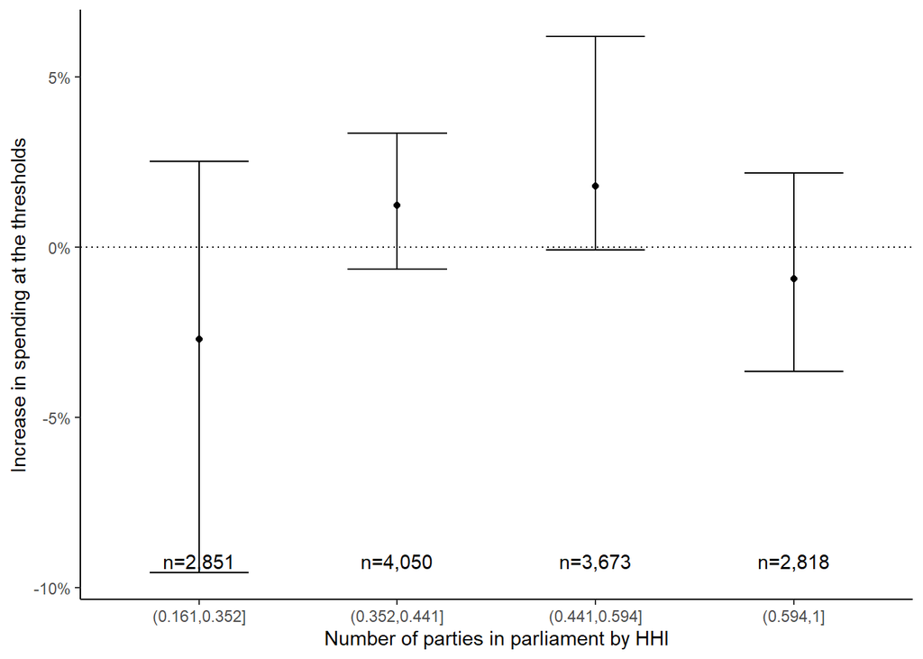

```r
df <- rdd_vary_no_of_part2 %>%
  rowwise() %>%
  mutate(effective_n = paste0("n=", trimws(format(sum(obs_below, obs_above), big.mark = ",")))) %>%
  ungroup()
ggplot2::ggplot(data = df, aes(x = parties_in_parliament_hhi_quant, y = point_estimate)) +
  geom_point(size = 1.5, color = ifelse(df$p <= p_value_cutoff, 2, 1)) +
  geom_errorbar(aes(ymin = ci_lower, ymax = ci_upper),
                color = ifelse(df$p <= p_value_cutoff, 2, 1),
                linetype = ifelse(df$p <= p_value_cutoff, 2, 1),
                width = 0.5) +
  geom_text(aes(y = -0.09, label = effective_n),
            colour = ifelse(df$p <= p_value_cutoff, 2, 1), vjust = 1) +
  geom_hline(aes(yintercept = 0), linetype = "dotted") +
  scale_y_continuous(labels = scales::percent) +
  labs(x = "Number of parties in parliament by HHI",
       y = y_lab_RDD)
```

```r
rm(df)
```

Similar to the previous `no_parties_in_parliament` result: No effect variation here.

Interaction-term method using an IV approach:

```r
df <- data %>%
  filter(closest <= 0.1)
rdd <- fixest::feols(ln_gross_expenditure_pc ~
                       1  | # controls
                       inhabitants_treshold_factor + state + year | # fixed-effect controls
                       # First stage regression:
                       inhabs_rel_to_cutoff*total_seats*parties_in_parliament_hhi ~
                       inhabs_rel_to_cutoff*above_cutoff*parties_in_parliament_hhi,
                     vcov = "threeway",
                     data = df)
```

```
## NOTE: 8,521 observations removed because of NA values (LHS: 2,600, IV: 7,160/7,160).
```

```
## Variance contained negative values in the diagonal and was 'fixed' (a la Cameron, Gelbach & Miller 2011).
## Variance contained negative values in the diagonal and was 'fixed' (a la Cameron, Gelbach & Miller 2011).
## Variance contained negative values in the diagonal and was 'fixed' (a la Cameron, Gelbach & Miller 2011).
```

```r
summary(rdd)
```

```
## TSLS estimation, Dep. Var.: ln_gross_expenditure_pc, Endo.: inhabs_rel_to_cutoff, total_seats, parties_in_parliament_hhi, inhabs_rel_to_cutoff:total_seats, inhabs_rel_to_cutoff:parties_in_parliament_hhi, total_seats:parties_in_parliament_hhi, inhabs_rel_to_cutoff:total_seats:parties_in_parliament…
## Second stage: Dep. Var.: ln_gross_expenditure_pc
## Observations: 7,043
## Fixed-effects: inhabitants_treshold_factor: 19,  state: 6,  year: 13
## Standard-errors: Clustered (inhabitants_treshold_factor & state & year)
##                                                                   Estimate
## fit_inhabs_rel_to_cutoff                                         80.117686
## fit_total_seats                                                   0.032660
## fit_parties_in_parliament_hhi                                     0.847041
## fit_inhabs_rel_to_cutoff:total_seats                             -4.363241
## fit_inhabs_rel_to_cutoff:parties_in_parliament_hhi             -110.761035
## fit_total_seats:parties_in_parliament_hhi                        -0.058826
## fit_inhabs_rel_to_cutoff:total_seats:parties_in_parliament_hhi    6.493558
##                                                                Std. Error
## fit_inhabs_rel_to_cutoff                                       104.279420
## fit_total_seats                                                  0.127065
## fit_parties_in_parliament_hhi                                    2.752259
## fit_inhabs_rel_to_cutoff:total_seats                             5.090634
## fit_inhabs_rel_to_cutoff:parties_in_parliament_hhi             113.098455
## fit_total_seats:parties_in_parliament_hhi                        0.194264
## fit_inhabs_rel_to_cutoff:total_seats:parties_in_parliament_hhi   5.254371
##                                                                  t value
## fit_inhabs_rel_to_cutoff                                        0.768298
## fit_total_seats                                                 0.257031
## fit_parties_in_parliament_hhi                                   0.307762
## fit_inhabs_rel_to_cutoff:total_seats                           -0.857112
## fit_inhabs_rel_to_cutoff:parties_in_parliament_hhi             -0.979333
## fit_total_seats:parties_in_parliament_hhi                      -0.302816
## fit_inhabs_rel_to_cutoff:total_seats:parties_in_parliament_hhi  1.235839
##                                                                Pr(>|t|)
## fit_inhabs_rel_to_cutoff                                        0.47701
## fit_total_seats                                                 0.80740
## fit_parties_in_parliament_hhi                                   0.77067
## fit_inhabs_rel_to_cutoff:total_seats                            0.43054
## fit_inhabs_rel_to_cutoff:parties_in_parliament_hhi              0.37239
## fit_total_seats:parties_in_parliament_hhi                       0.77422
## fit_inhabs_rel_to_cutoff:total_seats:parties_in_parliament_hhi  0.27141
## ---
## Signif. codes:  0 '***' 0.001 '**' 0.01 '*' 0.05 '.' 0.1 ' ' 1
## RMSE: 0.434436     Adj. R2: -1.05581
##                  Within R2: -1.98685
## F-test (1st stage), inhabs_rel_to_cutoff                                      : stat =      2.389e+31, p < 2.2e-16, on 7 and 7,035 DoF.
## F-test (1st stage), total_seats                                               : stat =    220.4      , p < 2.2e-16, on 7 and 7,035 DoF.
## F-test (1st stage), parties_in_parliament_hhi                                 : stat =      6.771e+31, p < 2.2e-16, on 7 and 7,035 DoF.
## F-test (1st stage), inhabs_rel_to_cutoff:total_seats                          : stat =  7,330.6      , p < 2.2e-16, on 7 and 7,035 DoF.
## F-test (1st stage), inhabs_rel_to_cutoff:parties_in_parliament_hhi            : stat =      1.051e+31, p < 2.2e-16, on 7 and 7,035 DoF.
## F-test (1st stage), total_seats:parties_in_parliament_hhi                     : stat =  4,818.9      , p < 2.2e-16, on 7 and 7,035 DoF.
## F-test (1st stage), inhabs_rel_to_cutoff:total_seats:parties_in_parliament_hhi: stat = 11,160.0      , p < 2.2e-16, on 7 and 7,035 DoF.
##                                                                     Wu-Hausman: stat =     NA        , p = NA     , on 7 and 6,993 DoF.
```

```r
rm(df)
```

This completes the picture: No treatment effect variation here.

## Absolute majority in parliament

Data available for the following states: 3,5,8,9,10,12,13,14

Subsample method:

```r
data_subset <- data %>% # prepare data set used for analysis
  select(ln_gross_expenditure_pc, inhabs_rel_to_cutoff, total_seats, inhabitants_treshold_factor, state, year, absolute_majority) %>%
  drop_na()
table(data_subset$state)
```

```
##
##     5     8     9    10    13    14
##  2772 13710 26702   364    54  4887
```

```r
lims <- c(-0.05, 0.04) # ggplot y axis limits
```

```r
all_values <- data_subset %>% distinct(absolute_majority) %>% pull() # vector of values
rdd_vary_abs_majority <- # prepare data set to store the results
  tibble(absolute_majority = "", point_estimate = "", se = "", se_robust = "",
         ci_lower = "", ci_upper = "", p = "", bw = "", obs_below = "", obs_above = "") %>%
  mutate(across(everything(), as.numeric))
for (i in all_values) {
  print(paste("absolute_majority:", i))
  df <- data_subset %>%
    filter(absolute_majority == i)
  rdd <-
    rdrobust_wrapper(
      ccluster = df$inhabitants_treshold_factor,
      ccovs = model.matrix( ~ df$inhabitants_treshold_factor + df$state + df$year) # FE
  )
  #summary(rdd)
  rdd_vary_abs_majority <- rdd_vary_abs_majority %>%
    dplyr::add_row(
      absolute_majority = i,
      point_estimate = rdd$coef[1],
      se = rdd$se[1],
      se_robust = rdd$se[3],
      ci_lower = rdd$ci[3,1],
      ci_upper = rdd$ci[3,2],
      p = rdd$pv[3],
      bw = rdd$bws[1,1],
      obs_below = rdd$N_h[1],
      obs_above = rdd$N_h[2]
  )
}
```

```
## [1] "absolute_majority: 0"
## [1] "Mass points detected in the running variable."
## [1] "absolute_majority: 1"
## [1] "Mass points detected in the running variable."
```

```r
rdd_vary_abs_majority <- rdd_vary_abs_majority %>% drop_na()
save(rdd_vary_abs_majority, file = "tables_robustness_checks/rdd_vary_abs_majority1.Rdata")
rm(all_values, data_subset, df, i, rdd)
```

```r
load(file = "tables_robustness_checks/rdd_vary_abs_majority1.Rdata")
rdd_vary_abs_majority
```

| absolute_majority | point_estimate | se | se_robust | ci_lower | ci_upper | p | bw | obs_below | obs_above |
| --- | --- | --- | --- | --- | --- | --- | --- | --- | --- |
| 0 | 0.016404246 | 0.007113260 | 0.009006062 | -0.006644193 | 0.03975196 | 0.06605024 | 0.07717930 | 3270 | 3058 |
| 1 | -0.001184145 | 0.005597727 | 0.007297943 | -0.021835556 | 0.01576096 | 0.67727403 | 0.08002136 | 3197 | 3621 |

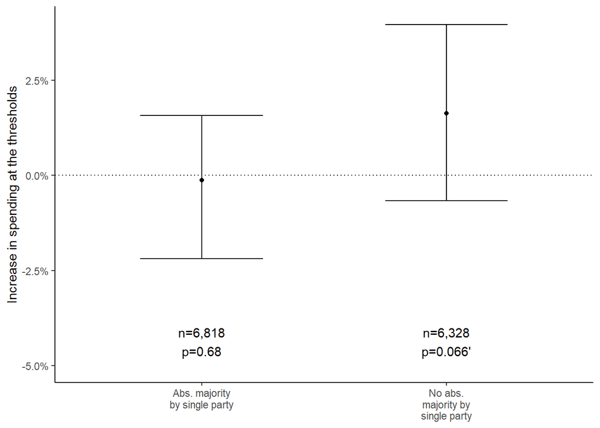

```r
df <- rdd_vary_abs_majority %>%
  mutate(absolute_majority = as.factor(absolute_majority),
         absolute_majority = case_when(
           absolute_majority == 1 ~ "Abs. majority by single party",
           absolute_majority == 0 ~ "No abs. majority by single party"
         )) %>%
  rowwise() %>%
  mutate(note = paste0(
    "n=",
    trimws(format(sum(obs_below, obs_above), big.mark = ",")),
    "\n",
    p_value(p),
    assign_stars(p)
    )) %>%
  ungroup()
p_maj1 <-
  ggplot2::ggplot(data = df, aes(x = absolute_majority, y = point_estimate)) +
  geom_point(size = 1.5, color = ifelse(df$p <= p_value_cutoff, 2, 1)) +
  geom_errorbar(aes(ymin = ci_lower, ymax = ci_upper),
                color = ifelse(df$p <= p_value_cutoff, 2, 1),
                linetype = ifelse(df$p <= p_value_cutoff, 2, 1),
                width = 0.5) +
  geom_hline(aes(yintercept = 0), linetype = "dotted") +
  geom_text(aes(y = -0.0475, label = note),
            colour = ifelse(df$p <= p_value_cutoff, 2, 1), vjust = 0) +
  scale_y_continuous(limits = lims, labels = scales::percent) +
  aes(stringr::str_wrap(absolute_majority, 15)) +
  labs(x = NULL, y = y_lab_RDD)
p_maj1
```

```r
# Adjustments for "publication"
p_maj1 <- p_maj1 + labs(title = "Absolute majority", y = NULL)
rm(df)
```

No differences.

Interaction-term method using an IV approach:

```r
df <- data %>%
  filter(closest <= 0.1)
rdd <- fixest::feols(ln_gross_expenditure_pc ~
                       1  | # controls
                       inhabitants_treshold_factor + state + year | # fixed-effect controls
                       # First stage regression:
                       inhabs_rel_to_cutoff*total_seats*absolute_majority ~
                       inhabs_rel_to_cutoff*above_cutoff*absolute_majority,
                     vcov = "threeway",
                     data = df)
```

```
## NOTE: 8,521 observations removed because of NA values (LHS: 2,600, IV: 7,160/7,160).
```

```
## Variance contained negative values in the diagonal and was 'fixed' (a la Cameron, Gelbach & Miller 2011).
```

```r
summary(rdd)
```

```
## TSLS estimation, Dep. Var.: ln_gross_expenditure_pc, Endo.: inhabs_rel_to_cutoff, total_seats, absolute_majority, inhabs_rel_to_cutoff:total_seats, inhabs_rel_to_cutoff:absolute_majority, total_seats:absolute_majority, inhabs_rel_to_cutoff:total_seats:absolute_majority, Instr.: inhabs_rel_to_cuto…
## Second stage: Dep. Var.: ln_gross_expenditure_pc
## Observations: 7,043
## Fixed-effects: inhabitants_treshold_factor: 19,  state: 6,  year: 13
## Standard-errors: Clustered (inhabitants_treshold_factor & state & year)
##                                                          Estimate Std. Error
## fit_inhabs_rel_to_cutoff                                62.086913  94.491876
## fit_total_seats                                          0.018147   0.070022
## fit_absolute_majority                                    0.435951   1.210782
## fit_inhabs_rel_to_cutoff:total_seats                    -3.116804   4.564051
## fit_inhabs_rel_to_cutoff:absolute_majority             -74.748311  87.116189
## fit_total_seats:absolute_majority                       -0.028347   0.068482
## fit_inhabs_rel_to_cutoff:total_seats:absolute_majority   3.999446   4.048003
##                                                          t value Pr(>|t|)
## fit_inhabs_rel_to_cutoff                                0.657061  0.54018
## fit_total_seats                                         0.259159  0.80584
## fit_absolute_majority                                   0.360057  0.73351
## fit_inhabs_rel_to_cutoff:total_seats                   -0.682903  0.52502
## fit_inhabs_rel_to_cutoff:absolute_majority             -0.858030  0.43008
## fit_total_seats:absolute_majority                      -0.413933  0.69608
## fit_inhabs_rel_to_cutoff:total_seats:absolute_majority  0.988005  0.36852
## ---
## Signif. codes:  0 '***' 0.001 '**' 0.01 '*' 0.05 '.' 0.1 ' ' 1
## RMSE: 0.506317     Adj. R2: -1.79239
##                  Within R2: -3.05703
## F-test (1st stage), inhabs_rel_to_cutoff                              : stat =     4.032e+32, p < 2.2e-16, on 7 and 7,035 DoF.
## F-test (1st stage), total_seats                                       : stat =   222.1      , p < 2.2e-16, on 7 and 7,035 DoF.
## F-test (1st stage), absolute_majority                                 : stat =     3.491e+32, p < 2.2e-16, on 7 and 7,035 DoF.
## F-test (1st stage), inhabs_rel_to_cutoff:total_seats                  : stat = 6,477.9      , p < 2.2e-16, on 7 and 7,035 DoF.
## F-test (1st stage), inhabs_rel_to_cutoff:absolute_majority            : stat =     8.399e+31, p < 2.2e-16, on 7 and 7,035 DoF.
## F-test (1st stage), total_seats:absolute_majority                     : stat = 6,320.1      , p < 2.2e-16, on 7 and 7,035 DoF.
## F-test (1st stage), inhabs_rel_to_cutoff:total_seats:absolute_majority: stat = 7,604.2      , p < 2.2e-16, on 7 and 7,035 DoF.
##                                                             Wu-Hausman: stat =    NA        , p = NA     , on 7 and 6,993 DoF.
```

```r
#rm(df)
```

This squares nicely with the `rdrobust` results: No differences.

## Party affiliation of (absolute) majority party

Why only looking at *absolute* majorities? Easier to identify effect, e. g. `cdu_csu` might sit at 40 % of council seats but `spd` and greens might jointly be at 60 %. Hence, the left-wing party would have a majority over the conservatives but the data set might lead us to think that `cdu_csu` “dictates” policies.

### Overall data set

Subsample method:

```r
data_subset <- data %>% # prepare data set used for analysis
  select(ln_gross_expenditure_pc, inhabs_rel_to_cutoff, total_seats, inhabitants_treshold_factor, state, year, absolute_majority, cdu_csu_majority, spd_majority, waehlergruppen_majority, closest, above_cutoff) %>%
  mutate(abs_majority_party = case_when(
    cdu_csu_majority == 1 ~ "CDU/CSU abs. majority",
    spd_majority == 1 ~ "Non CDU/CSU abs. majority", # spd only yields error in rdrobust...
    #waehlergruppen_majority == 1 ~ "waehlergruppen",
    waehlergruppen_majority == 1 ~ "Non CDU/CSU abs. majority",
    absolute_majority == 0 ~ "No abs. majority"
  )) %>%
  select(-c(cdu_csu_majority, spd_majority, waehlergruppen_majority, absolute_majority)) %>%
  drop_na()
table(data_subset$state)
```

```
##
##     5     8     9    10    13    14
##  2772  7840 23854   364    54  3444
```

```r
all_values <- data_subset %>% distinct(abs_majority_party) %>% pull() # vector of values
rdd_vary_abs_majority2 <- # prepare data set to store the results
  tibble(abs_majority_party = "", point_estimate = "", se = "", se_robust = "",
         ci_lower = "", ci_upper = "", p = "", bw = "", obs_below = "", obs_above = "") %>%
  mutate(across(2:last_col(), as.numeric))
for (i in all_values) {
  print(paste("abs_majority_party:", i))
  df <- data_subset %>%
    filter(abs_majority_party == i)
  rdd <-
    rdrobust_wrapper(
      ccluster = df$inhabitants_treshold_factor,
      ccovs = model.matrix( ~ df$inhabitants_treshold_factor + df$state + df$year) # FE
  )
  #summary(rdd)
  rdd_vary_abs_majority2 <- rdd_vary_abs_majority2 %>%
    dplyr::add_row(
      abs_majority_party = i,
      point_estimate = rdd$coef[1],
      se = rdd$se[1],
      se_robust = rdd$se[3],
      ci_lower = rdd$ci[3,1],
      ci_upper = rdd$ci[3,2],
      p = rdd$pv[3],
      bw = rdd$bws[1,1],
      obs_below = rdd$N_h[1],
      obs_above = rdd$N_h[2]
  )
}
```

```
## [1] "abs_majority_party: No abs. majority"
## [1] "Mass points detected in the running variable."
## [1] "abs_majority_party: CDU/CSU abs. majority"
## [1] "Mass points detected in the running variable."
## [1] "abs_majority_party: Non CDU/CSU abs. majority"
## [1] "Mass points detected in the running variable."
```

```r
rdd_vary_abs_majority2 <- rdd_vary_abs_majority2 %>% drop_na()
save(rdd_vary_abs_majority2, file = "tables_robustness_checks/rdd_vary_abs_majority2.Rdata")
rm(all_values, df, i, rdd)
```

```r
load(file = "tables_robustness_checks/rdd_vary_abs_majority2.Rdata")
rdd_vary_abs_majority2
```

| abs_majority_party | point_estimate | se | se_robust | ci_lower | ci_upper | p | bw | obs_below | obs_above |
| --- | --- | --- | --- | --- | --- | --- | --- | --- | --- |
| No abs. majority | 0.016404246 | 0.00711326 | 0.009006062 | -0.006644193 | 0.03975196 | 0.06605024 | 0.07717930 | 3270 | 3058 |
| CDU/CSU abs. majority | 0.009259565 | 0.00704254 | 0.008224797 | -0.014902657 | 0.02746869 | 0.44492009 | 0.08652195 | 828 | 764 |
| Non CDU/CSU abs. majority | -0.007244410 | 0.01053585 | 0.011686327 | -0.032725721 | 0.02747824 | 0.82235778 | 0.02362386 | 334 | 363 |

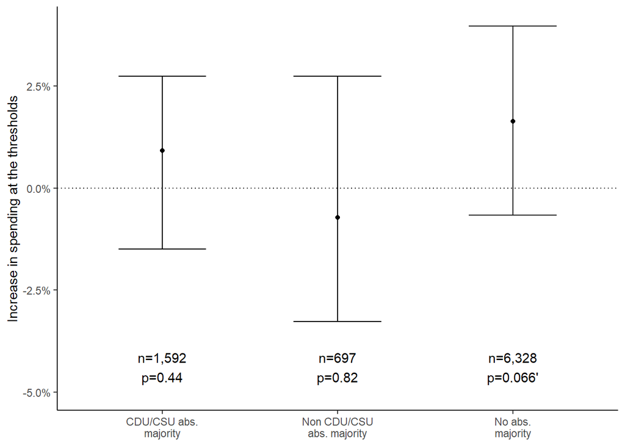

```r
df <- rdd_vary_abs_majority2 %>%
  mutate(
    abs_majority_party = stringr::str_wrap(abs_majority_party, 15),
    abs_majority_party = fct_reorder(abs_majority_party, c(3, 1, 2))
    ) %>%
  rowwise() %>%
  mutate(note = paste0(
    "n=",
    trimws(format(sum(obs_below, obs_above), big.mark = ",")),
    "\n",
    p_value(p),
    assign_stars(p)
    )) %>%
  ungroup()
p_maj2 <-
  ggplot2::ggplot(data = df, aes(x = abs_majority_party, y = point_estimate)) +
  geom_point(size = 1.5, color = ifelse(df$p <= p_value_cutoff, 2, 1)) +
  geom_errorbar(aes(ymin = ci_lower, ymax = ci_upper),
                color = ifelse(df$p <= p_value_cutoff, 2, 1),
                linetype = ifelse(df$p <= p_value_cutoff, 2, 1),
                width = 0.5) +
  geom_text(aes(y = -0.0475, label = note),
            colour = ifelse(df$p <= p_value_cutoff, 2, 1), vjust = 0) +
  geom_hline(aes(yintercept = 0), linetype = "dotted") +
  scale_y_continuous(limits = lims, labels = scales::percent) +
  #aes(stringr::str_wrap(abs_majority_party, 15)) +
  labs(x = NULL, y = y_lab_RDD)
p_maj2
```

```r
p_maj2 <- p_maj2 + labs(title = "Absolute majority by party", y = NULL)
#rm(df)
```

No effect visible here. `spd` is not a separate category as it would yield an error, potentially owing to too few observations.

Interaction-term method using an IV approach:

```r
df <- data_subset %>%
  filter(closest <= 0.1) #%>%
  # mutate(abs_majority_party = case_when(
  #   cdu_csu_majority == 1 ~ "cdu_csu",
  #   spd_majority == 1 ~ , # spd only yields error in rdrobust...
  #   #waehlergruppen_majority == 1 ~ "waehlergruppen",
  #   TRUE ~ "neither cdu_csu nor spd"
  # ))
rdd <- fixest::feols(ln_gross_expenditure_pc ~
                       1  | # controls
                       inhabitants_treshold_factor + state + year | # fixed-effect controls
                       # First stage regression:
                       inhabs_rel_to_cutoff*total_seats*abs_majority_party ~
                       inhabs_rel_to_cutoff*above_cutoff*abs_majority_party,
                     vcov = "threeway",
                     data = df)
```

```
## Variance contained negative values in the diagonal and was 'fixed' (a la Cameron, Gelbach & Miller 2011).
## Variance contained negative values in the diagonal and was 'fixed' (a la Cameron, Gelbach & Miller 2011).
```

```r
summary(rdd)
```

```
## TSLS estimation, Dep. Var.: ln_gross_expenditure_pc, Endo.: inhabs_rel_to_cutoff, total_seats, abs_majority_party, inhabs_rel_to_cutoff:total_seats, inhabs_rel_to_cutoff:abs_majority_party, total_seats:abs_majority_party, inhabs_rel_to_cutoff:total_seats:abs_majority_party, Instr.: inhabs_rel_to_…
## Second stage: Dep. Var.: ln_gross_expenditure_pc
## Observations: 5,410
## Fixed-effects: inhabitants_treshold_factor: 19,  state: 6,  year: 13
## Standard-errors: Clustered (inhabitants_treshold_factor & state & year)
##                                                                                    Estimate
## fit_inhabs_rel_to_cutoff                                                          -0.201529
## fit_total_seats                                                                    0.015079
## fit_abs_majority_partyNo abs. majority                                             0.178788
## fit_abs_majority_partyNon CDU/CSU abs. majority                                    0.364314
## fit_inhabs_rel_to_cutoff:total_seats                                               0.020325
## fit_inhabs_rel_to_cutoff:abs_majority_partyNo abs. majority                       60.681641
## fit_inhabs_rel_to_cutoff:abs_majority_partyNon CDU/CSU abs. majority             -36.833540
## fit_total_seats:abs_majority_partyNo abs. majority                                -0.006060
## fit_total_seats:abs_majority_partyNon CDU/CSU abs. majority                       -0.026460
## fit_inhabs_rel_to_cutoff:total_seats:abs_majority_partyNo abs. majority           -3.044040
## fit_inhabs_rel_to_cutoff:total_seats:abs_majority_partyNon CDU/CSU abs. majority   2.557269
##                                                                                  Std. Error
## fit_inhabs_rel_to_cutoff                                                          17.450555
## fit_total_seats                                                                    0.028967
## fit_abs_majority_partyNo abs. majority                                             1.316313
## fit_abs_majority_partyNon CDU/CSU abs. majority                                    0.541820
## fit_inhabs_rel_to_cutoff:total_seats                                               0.925252
## fit_inhabs_rel_to_cutoff:abs_majority_partyNo abs. majority                       89.321257
## fit_inhabs_rel_to_cutoff:abs_majority_partyNon CDU/CSU abs. majority              18.188487
## fit_total_seats:abs_majority_partyNo abs. majority                                 0.069021
## fit_total_seats:abs_majority_partyNon CDU/CSU abs. majority                        0.021369
## fit_inhabs_rel_to_cutoff:total_seats:abs_majority_partyNo abs. majority            4.335661
## fit_inhabs_rel_to_cutoff:total_seats:abs_majority_partyNon CDU/CSU abs. majority   1.043381
##                                                                                    t value
## fit_inhabs_rel_to_cutoff                                                         -0.011549
## fit_total_seats                                                                   0.520547
## fit_abs_majority_partyNo abs. majority                                            0.135825
## fit_abs_majority_partyNon CDU/CSU abs. majority                                   0.672389
## fit_inhabs_rel_to_cutoff:total_seats                                              0.021967
## fit_inhabs_rel_to_cutoff:abs_majority_partyNo abs. majority                       0.679364
## fit_inhabs_rel_to_cutoff:abs_majority_partyNon CDU/CSU abs. majority             -2.025102
## fit_total_seats:abs_majority_partyNo abs. majority                               -0.087802
## fit_total_seats:abs_majority_partyNon CDU/CSU abs. majority                      -1.238261
## fit_inhabs_rel_to_cutoff:total_seats:abs_majority_partyNo abs. majority          -0.702094
```

[output cut: 26 more lines]

```
## Signif. codes:  0 '***' 0.001 '**' 0.01 '*' 0.05 '.' 0.1 ' ' 1
## RMSE: 0.546456     Adj. R2: -2.14596
##                  Within R2: -3.47193
## F-test (1st stage), inhabs_rel_to_cutoff                                                        : stat =     6.441e+30, p < 2.2e-16, on 11 and 5,398 DoF.
## F-test (1st stage), total_seats                                                                 : stat =   146.5      , p < 2.2e-16, on 11 and 5,398 DoF.
## F-test (1st stage), abs_majority_partyNo abs. majority                                          : stat =     3.844e+31, p < 2.2e-16, on 11 and 5,398 DoF.
## F-test (1st stage), abs_majority_partyNon CDU/CSU abs. majority                                 : stat =     3.285e+31, p < 2.2e-16, on 11 and 5,398 DoF.
## F-test (1st stage), inhabs_rel_to_cutoff:total_seats                                            : stat = 3,064.8      , p < 2.2e-16, on 11 and 5,398 DoF.
## F-test (1st stage), inhabs_rel_to_cutoff:abs_majority_partyNo abs. majority                     : stat =     1.041e+31, p < 2.2e-16, on 11 and 5,398 DoF.
## F-test (1st stage), inhabs_rel_to_cutoff:abs_majority_partyNon CDU/CSU abs. majority            : stat =     1.156e+31, p < 2.2e-16, on 11 and 5,398 DoF.
## F-test (1st stage), total_seats:abs_majority_partyNo abs. majority                              : stat = 2,503.3      , p < 2.2e-16, on 11 and 5,398 DoF.
## F-test (1st stage), total_seats:abs_majority_partyNon CDU/CSU abs. majority                     : stat = 7,312.3      , p < 2.2e-16, on 11 and 5,398 DoF.
## F-test (1st stage), inhabs_rel_to_cutoff:total_seats:abs_majority_partyNo abs. majority         : stat = 2,846.7      , p < 2.2e-16, on 11 and 5,398 DoF.
## F-test (1st stage), inhabs_rel_to_cutoff:total_seats:abs_majority_partyNon CDU/CSU abs. majority: stat = 7,673.3      , p < 2.2e-16, on 11 and 5,398 DoF.
##                                                                                       Wu-Hausman: stat =    NA        , p = NA     , on 11 and 5,352 DoF.
```

```r
# joint test on interactions
fixest::wald(rdd, "fit_total_seats:abs_majority_party")
```

```
## Wald test, H0: joint nullity of fit_total_seats:abs_majority_partyNo abs. majority and fit_total_seats:abs_majority_partyNon CDU/CSU abs. majority
##  stat = 0.961143, p-value = 0.382521, on 2 and 5,363 DoF, VCOV: Clustered (inhabitants_treshold_factor & state & year).
```

```r
rm(df)
```

Yup, no effect visible here, as indicated by the `rdrobust` results.

### Bavaria

```r
data_subset <- data_by %>% # prepare data set used for analysis
  select(ln_gross_expenditure_pc, inhabs_rel_to_cutoff, total_seats, inhabitants_treshold_factor, state, year, cdu_csu_majority, spd_majority, waehlergruppen_majority, closest, above_cutoff) %>%
  mutate(abs_majority_party = case_when(
    cdu_csu_majority == 1 ~ "cdu_csu",
    spd_majority == 1 ~ "neither cdu_csu nor waehlergruppen", # spd only yields error in rdrobust...
    waehlergruppen_majority == 1 ~ "waehlergruppen",
    TRUE ~ "neither cdu_csu nor waehlergruppen"
  )) %>%
  drop_na()
table(data_subset$state)
```

```
##
##     9
## 26702
```

```r
all_values <- data_subset %>% distinct(abs_majority_party) %>% pull() # vector of values
rdd_vary_abs_majority <- # prepare data set to store the results
  tibble(abs_majority_party = "", point_estimate = "", se = "", se_robust = "",
         ci_lower = "", ci_upper = "", p = "", bw = "", obs_below = "", obs_above = "") %>%
  mutate(across(2:last_col(), as.numeric))
for (i in all_values) {
  print(paste("abs_majority_party:", i))
  df <- data_subset %>%
    filter(abs_majority_party == i)
  rdd <-
    rdrobust_wrapper(
      ccluster = df$inhabitants_treshold_factor,
      ccovs = model.matrix( ~ df$inhabitants_treshold_factor + df$year) # FE
  )
  #summary(rdd)
  rdd_vary_abs_majority <- rdd_vary_abs_majority %>%
    dplyr::add_row(
      abs_majority_party = i,
      point_estimate = rdd$coef[1],
      se = rdd$se[1],
      se_robust = rdd$se[3],
      ci_lower = rdd$ci[3,1],
      ci_upper = rdd$ci[3,2],
      p = rdd$pv[3],
      bw = rdd$bws[1,1],
      obs_below = rdd$N_h[1],
      obs_above = rdd$N_h[2]
  )
}
```

```
## [1] "abs_majority_party: cdu_csu"
## [1] "Mass points detected in the running variable."
## [1] "abs_majority_party: neither cdu_csu nor waehlergruppen"
## [1] "Mass points detected in the running variable."
## [1] "abs_majority_party: waehlergruppen"
## [1] "Mass points detected in the running variable."
```

```r
rdd_vary_abs_majority <- rdd_vary_abs_majority %>% drop_na()
save(rdd_vary_abs_majority, file = "tables_robustness_checks/rdd_vary_abs_majority_by.Rdata")
rm(all_values, df, i, rdd)
```

```r
load(file = "tables_robustness_checks/rdd_vary_abs_majority_by.Rdata")
rdd_vary_abs_majority
```

| abs_majority_party | point_estimate | se | se_robust | ci_lower | ci_upper | p | bw | obs_below | obs_above |
| --- | --- | --- | --- | --- | --- | --- | --- | --- | --- |
| cdu_csu | 0.07562192 | 0.032664104 | 0.041023825 | 0.008043879 | 0.219384618 | 0.0055728866 | 0.01383983 | 85 | 54 |
| neither cdu_csu nor waehlergruppen | -0.03734804 | 0.010535954 | 0.012462068 | -0.080373788 | -0.016173470 | 0.0001072195 | 0.03557695 | 880 | 990 |
| waehlergruppen | -0.02249294 | 0.006560561 | 0.007156018 | -0.040338305 | -0.003472941 | 0.0022049093 | 0.10972188 | 1557 | 1637 |

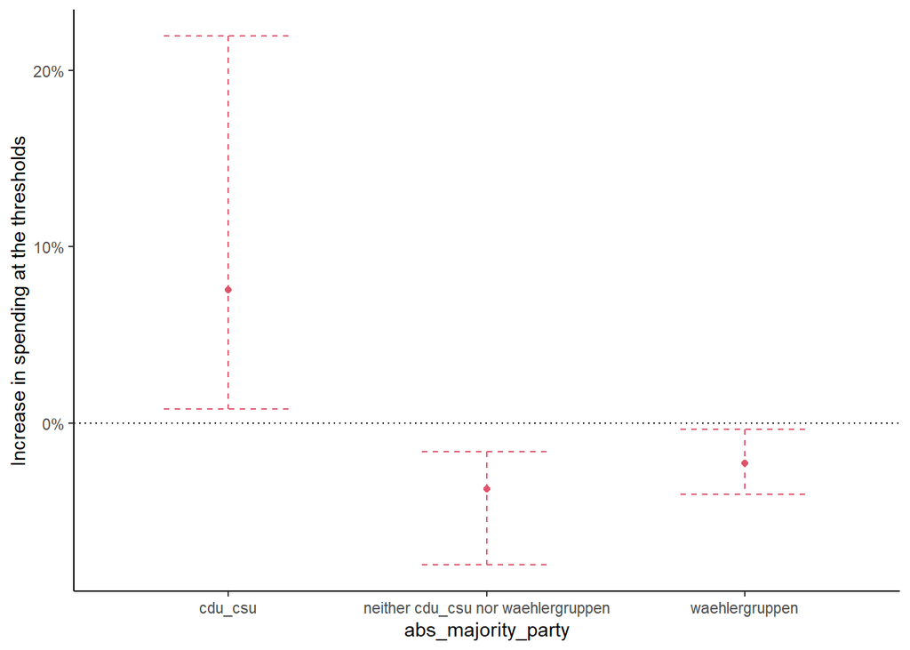

```r
ggplot2::ggplot(data = rdd_vary_abs_majority, aes(x = abs_majority_party, y = point_estimate)) +
  geom_point(size = 1.5, color = ifelse(rdd_vary_abs_majority$p <= p_value_cutoff, 2, 1)) +
  geom_errorbar(aes(ymin = ci_lower, ymax = ci_upper),
                color = ifelse(rdd_vary_abs_majority$p <= p_value_cutoff, 2, 1),
                linetype = ifelse(rdd_vary_abs_majority$p <= p_value_cutoff, 2, 1),
                width = 0.5) +
  geom_hline(aes(yintercept = 0), linetype = "dotted") +
  scale_y_continuous(labels = scales::percent) +
  labs(y = y_lab_RDD)
```

Interesting results for Bavaria: `cdu_csu` absolute majority drives up the treatment effect, whereas `waehlergruppen` as well as other majorities (including `spd` absolute majority and no single majority party) produce a contrary “Law of 1/n”.

Interaction-term method using an IV approach:

```r
df <- data_subset %>%
  filter(closest <= 0.1)
rdd <- fixest::feols(ln_gross_expenditure_pc ~
                       1  | # controls
                       inhabitants_treshold_factor + year | # fixed-effect controls
                       # First stage regression:
                       inhabs_rel_to_cutoff*total_seats*abs_majority_party ~
                       inhabs_rel_to_cutoff*above_cutoff*abs_majority_party,
                     vcov = "threeway",
                     data = df)
summary(rdd)
```

```
## TSLS estimation, Dep. Var.: ln_gross_expenditure_pc, Endo.: inhabs_rel_to_cutoff, total_seats, abs_majority_party, inhabs_rel_to_cutoff:total_seats, inhabs_rel_to_cutoff:abs_majority_party, total_seats:abs_majority_party, inhabs_rel_to_cutoff:total_seats:abs_majority_party, Instr.: inhabs_rel_to_…
## Second stage: Dep. Var.: ln_gross_expenditure_pc
## Observations: 2,672
## Fixed-effects: inhabitants_treshold_factor: 9,  year: 13
## Standard-errors: Clustered (inhabitants_treshold_factor & year)
##                                                                                              Estimate
## fit_inhabs_rel_to_cutoff                                                                   117.008154
## fit_total_seats                                                                              0.001948
## fit_abs_majority_partyneither cdu_csu nor waehlergruppen                                     0.648461
## fit_abs_majority_partywaehlergruppen                                                        -0.595715
## fit_inhabs_rel_to_cutoff:total_seats                                                        -7.532207
## fit_inhabs_rel_to_cutoff:abs_majority_partyneither cdu_csu nor waehlergruppen              -42.520380
## fit_inhabs_rel_to_cutoff:abs_majority_partywaehlergruppen                                 -276.875521
## fit_total_seats:abs_majority_partyneither cdu_csu nor waehlergruppen                        -0.039004
## fit_total_seats:abs_majority_partywaehlergruppen                                             0.036558
## fit_inhabs_rel_to_cutoff:total_seats:abs_majority_partyneither cdu_csu nor waehlergruppen    3.235547
## fit_inhabs_rel_to_cutoff:total_seats:abs_majority_partywaehlergruppen                       18.855421
##                                                                                           Std. Error
## fit_inhabs_rel_to_cutoff                                                                  122.846739
## fit_total_seats                                                                             0.028466
## fit_abs_majority_partyneither cdu_csu nor waehlergruppen                                    0.618944
## fit_abs_majority_partywaehlergruppen                                                        2.454360
## fit_inhabs_rel_to_cutoff:total_seats                                                        7.773422
## fit_inhabs_rel_to_cutoff:abs_majority_partyneither cdu_csu nor waehlergruppen             147.936979
## fit_inhabs_rel_to_cutoff:abs_majority_partywaehlergruppen                                 390.749624
## fit_total_seats:abs_majority_partyneither cdu_csu nor waehlergruppen                        0.041792
## fit_total_seats:abs_majority_partywaehlergruppen                                            0.158202
## fit_inhabs_rel_to_cutoff:total_seats:abs_majority_partyneither cdu_csu nor waehlergruppen   9.314744
## fit_inhabs_rel_to_cutoff:total_seats:abs_majority_partywaehlergruppen                      26.552116
##                                                                                             t value
## fit_inhabs_rel_to_cutoff                                                                   0.952473
## fit_total_seats                                                                            0.068443
## fit_abs_majority_partyneither cdu_csu nor waehlergruppen                                   1.047690
## fit_abs_majority_partywaehlergruppen                                                      -0.242717
## fit_inhabs_rel_to_cutoff:total_seats                                                      -0.968969
## fit_inhabs_rel_to_cutoff:abs_majority_partyneither cdu_csu nor waehlergruppen             -0.287422
## fit_inhabs_rel_to_cutoff:abs_majority_partywaehlergruppen                                 -0.708575
## fit_total_seats:abs_majority_partyneither cdu_csu nor waehlergruppen                      -0.933291
## fit_total_seats:abs_majority_partywaehlergruppen                                           0.231088
## fit_inhabs_rel_to_cutoff:total_seats:abs_majority_partyneither cdu_csu nor waehlergruppen  0.347358
```

[output cut: 26 more lines]

```
## Signif. codes:  0 '***' 0.001 '**' 0.01 '*' 0.05 '.' 0.1 ' ' 1
## RMSE: 0.534002     Adj. R2: -1.91322
##                  Within R2: -2.82533
## F-test (1st stage), inhabs_rel_to_cutoff                                                                 : stat =     2.802e+29, p < 2.2e-16, on 11 and 2,660 DoF.
## F-test (1st stage), total_seats                                                                          : stat =   364.4      , p < 2.2e-16, on 11 and 2,660 DoF.
## F-test (1st stage), abs_majority_partyneither cdu_csu nor waehlergruppen                                 : stat =     2.168e+30, p < 2.2e-16, on 11 and 2,660 DoF.
## F-test (1st stage), abs_majority_partywaehlergruppen                                                     : stat =     3.557e+30, p < 2.2e-16, on 11 and 2,660 DoF.
## F-test (1st stage), inhabs_rel_to_cutoff:total_seats                                                     : stat = 3,217.1      , p < 2.2e-16, on 11 and 2,660 DoF.
## F-test (1st stage), inhabs_rel_to_cutoff:abs_majority_partyneither cdu_csu nor waehlergruppen            : stat =     5.445e+29, p < 2.2e-16, on 11 and 2,660 DoF.
## F-test (1st stage), inhabs_rel_to_cutoff:abs_majority_partywaehlergruppen                                : stat =     6.692e+29, p < 2.2e-16, on 11 and 2,660 DoF.
## F-test (1st stage), total_seats:abs_majority_partyneither cdu_csu nor waehlergruppen                     : stat = 4,036.8      , p < 2.2e-16, on 11 and 2,660 DoF.
## F-test (1st stage), total_seats:abs_majority_partywaehlergruppen                                         : stat = 4,926.9      , p < 2.2e-16, on 11 and 2,660 DoF.
## F-test (1st stage), inhabs_rel_to_cutoff:total_seats:abs_majority_partyneither cdu_csu nor waehlergruppen: stat = 2,568.8      , p < 2.2e-16, on 11 and 2,660 DoF.
## F-test (1st stage), inhabs_rel_to_cutoff:total_seats:abs_majority_partywaehlergruppen                    : stat = 6,113.1      , p < 2.2e-16, on 11 and 2,660 DoF.
##                                                                                                Wu-Hausman: stat =    NA        , p = NA     , on 11 and 2,629 DoF.
```

```r
rm(df)
```

Results from the `rdrobust` function cannot be reproduced: No significant differences from `cdu_csu` treatment effect in Bavaria.

### Export plot

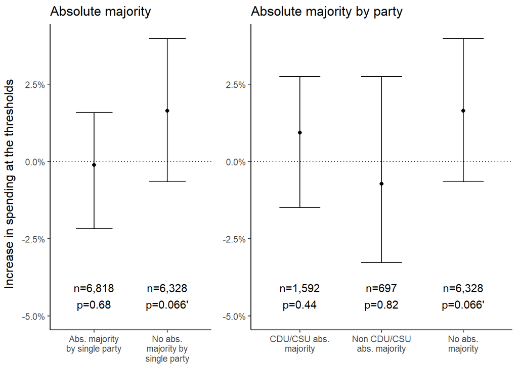

```r
plot_council_majorities <- ggpubr::ggarrange(
  p_maj1,
  p_maj2,
  #labels = c("Absolute majority", "Absolute majority by party"),
  widths = c(2, 3),
  align = "h",
  ncol = 2,
  nrow = 1
) %>%
  annotate_figure(
    # See https://github.com/kassambara/ggpubr/issues/78
    left = text_grob(y_lab_RDD, rot = 90)
    )
plot_council_majorities
```

```r
ggsave(filename = "plots/rdd_absolute_majority_council.pdf", width = 6, height = 6*9/16)
```

```r
rm(p_maj1, p_maj2, lims)
```

## Digression: All expenditure categories

Run regressions over all expenditure categories

```r
exp_category <- data %>%
  select(starts_with("ln_expenditure")) %>% # select expenditure categories
  names() # pull their names
rdd_vary_exp_category <- # prepare data set to store the results
  tibble(exp_category = "", point_estimate = "", se = "", se_robust = "",
         ci_lower = "", ci_upper = "", p = "", bw = "", obs_below = "", obs_above = "") %>%
  mutate(across(2:last_col(), as.numeric))
for (i in exp_category) {
  df <- data %>%
    select((!!rlang::sym(i)), inhabs_rel_to_cutoff, total_seats,
           inhabitants_treshold_factor, year, state) %>%
    drop_na()
  print(table(df$state))
  rdd <-
    rdrobust::rdrobust(
      y = df %>% pull(i),
      x = df$inhabs_rel_to_cutoff,
      fuzzy = df$total_seats,
      cluster = df$inhabitants_treshold_factor,
      covs = model.matrix(~ df$inhabitants_treshold_factor + df$year + df$state),
      level = (1-p_value_cutoff)*100
    )
  #summary(rdd)
  rdd_vary_exp_category <- rdd_vary_exp_category %>%
    dplyr::add_row(
      exp_category = i,
      point_estimate = rdd$coef[1],
      se = rdd$se[1],
      se_robust = rdd$se[3],
      ci_lower = rdd$ci[3,1],
      ci_upper = rdd$ci[3,2],
      p = rdd$pv[3],
      bw = rdd$bws[1,1],
      obs_below = rdd$N_h[1],
      obs_above = rdd$N_h[2]
  )
}
```

```
##
##     1     5     6     7     8     9    10    13    14    15    16
## 11274  2772  5536 29819 14305 26702   364    54  4887    28  7875
## [1] "Mass points detected in the running variable."
##
##     1     5     6     7     8     9    10    13    14    15    16
## 11267  2772  5536 29800 14305 26702   364    54  4887    28  7875
## [1] "Mass points detected in the running variable."
##
##     1     5     6     7     8     9    10    13    14    15    16
## 11273  2772  5534 29811 14305 26701   364    54  4885    28  7875
## [1] "Mass points detected in the running variable."
##
##     1     5     6     7     8     9    10    13    14    15    16
## 11108  2772  5533 29141 14304 26694   364    54  4887    28  7870
## [1] "Mass points detected in the running variable."
##
##     1     5     6     7     8     9    10    13    14    15    16
##  7903  2713  5486 20676 12549 25028   364    54  4724    28  6993
## [1] "Mass points detected in the running variable."
##
##     1     5     6     7     8     9    10    13    14    15    16
## 10425  2772  5530 27277 14297 26691   364    54  4886    28  7738
## [1] "Mass points detected in the running variable."
```

```r
rdd_vary_exp_category <- rdd_vary_exp_category %>%
  drop_na() %>%
  mutate(exp_category2 = c("Administrative", "Administrative: personnel", "Administrative: operating",
                           "Capital", "Capital: loans", "Capital: property investment"))
save(rdd_vary_exp_category, file = "tables_robustness_checks/rdd_vary_exp_category.Rdata")
rm(df)
```

```r
load(file = "tables_robustness_checks/rdd_vary_exp_category.Rdata")
rdd_vary_exp_category
```

| exp_category | point_estimate | se | se_robust | ci_lower | ci_upper | p | bw | obs_below | obs_above | exp_category2 |
| --- | --- | --- | --- | --- | --- | --- | --- | --- | --- | --- |
| ln_expenditure_administrative_pc | 0.016756642 | 0.009971653 | 0.01041194 | -0.008771587 | 0.04486715 | 0.08302916 | 0.05668673 | 8356 | 8976 | Administrative |
| ln_expenditure_admin_personel_pc | -0.004983356 | 0.027402607 | 0.02859609 | -0.081329960 | 0.06598734 | 0.78849582 | 0.04901169 | 7078 | 7835 | Administrative: personnel |
| ln_expenditure_adminoperating_pc | -0.015269430 | 0.016209046 | 0.01699863 | -0.060102551 | 0.02746858 | 0.33710546 | 0.04477090 | 6460 | 7166 | Administrative: operating |
| ln_expenditure_capital_pc | 0.017450367 | 0.026218609 | 0.02723739 | -0.049212948 | 0.09110478 | 0.44188536 | 0.05301230 | 7822 | 8426 | Capital |
| ln_expenditure_capital_loans_pc | 0.064762935 | 0.039596651 | 0.04224157 | -0.038555179 | 0.17905899 | 0.09629269 | 0.06816695 | 8701 | 9465 | Capital: loans |
| ln_expenditure_capital_prop_inv_pc | 0.004117307 | 0.027541122 | 0.02806637 | -0.065960366 | 0.07862800 | 0.82145593 | 0.05457156 | 7922 | 8571 | Capital: property investment |

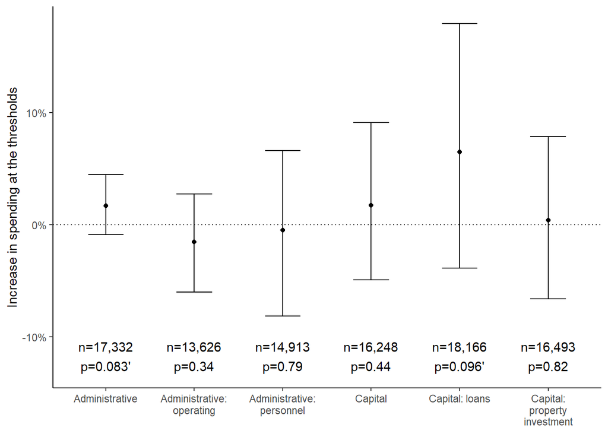

```r
df <- rdd_vary_exp_category %>%
  rowwise() %>%
  mutate(note = paste0(
    "n=",
    trimws(format(sum(obs_below, obs_above), big.mark = ",")),
    "\n",
    p_value(p),
    assign_stars(p)
    )) %>%
  ungroup()
ggplot2::ggplot(data = df, aes(x = exp_category2, y = point_estimate)) +
  geom_point(size = 1.5, color = ifelse(df$p <= p_value_cutoff, 2, 1)) +
  geom_errorbar(aes(ymin = ci_lower, ymax = ci_upper),
                color = ifelse(df$p <= p_value_cutoff, 2, 1),
                linetype = ifelse(df$p <= p_value_cutoff, 2, 1),
                width = 0.4) +
  geom_hline(aes(yintercept = 0), linetype = "dotted") +
  scale_y_continuous(labels = scales::percent) +
  aes(stringr::str_wrap(exp_category2, 15)) +
  labs(x = NULL, y = y_lab_RDD) +
  geom_text(aes(y = -0.13, label = note),
            colour = ifelse(df$p <= p_value_cutoff, 2, 1), vjust = 0) #+
```

```r
  #coord_flip()
ggsave(filename = "plots/rdd_exp_categories.pdf", width = 6, height = 6*9/16)
rm(df)
```

Not much variation in ATE across all spending categories.

IV approach:

```r
df <- data %>%
  filter(closest <= 0.1)
rdd <- fixest::feols(c(ln_expenditure_administrative_pc, ln_expenditure_admin_personel_pc,
                       ln_expenditure_adminoperating_pc, ln_expenditure_capital_pc,
                       ln_expenditure_capital_loans_pc, ln_expenditure_capital_prop_inv_pc) ~
                       1  | # controls
                       inhabitants_treshold_factor + state + year | # fixed-effect controls
                       # First stage regression:
                       inhabs_rel_to_cutoff*total_seats ~ # Instrument our standard RDD...
                       inhabs_rel_to_cutoff*above_cutoff, # ... with being above the cutoff
                     vcov = "threeway",
                     data = df)
```

```
## Variance contained negative values in the diagonal and was 'fixed' (a la Cameron, Gelbach & Miller 2011).
```

```r
summary(rdd)
```

```
## Variance contained negative values in the diagonal and was 'fixed' (a la Cameron, Gelbach & Miller 2011).
```

```
## Standard-errors: Clustered (inhabitants_treshold_factor & state & year)
## Dep. var.: ln_expenditure_administrative_pc
##                                       Estimate Std. Error  t value Pr(>|t|)
## fit_inhabs_rel_to_cutoff              4.067425   2.781548  1.46229  0.17768
## fit_total_seats                       0.009759   0.009330  1.04604  0.32282
## fit_inhabs_rel_to_cutoff:total_seats -0.260691   0.186599 -1.39707  0.19588
## ---
## Dep. var.: ln_expenditure_admin_personel_pc
##                                       Estimate Std. Error   t value Pr(>|t|)
## fit_inhabs_rel_to_cutoff             19.014409   8.537078  2.227274 0.052932
## fit_total_seats                      -0.009982   0.030062 -0.332056 0.747449
## fit_inhabs_rel_to_cutoff:total_seats -1.097793   0.507464 -2.163293 0.058752
##
## fit_inhabs_rel_to_cutoff             .
## fit_total_seats
## fit_inhabs_rel_to_cutoff:total_seats .
## ---
## Dep. var.: ln_expenditure_adminoperating_pc
##                                       Estimate Std. Error     t value  Pr(>|t|)
## fit_inhabs_rel_to_cutoff              3.772690   0.001326 2844.170230 < 2.2e-16
## fit_total_seats                      -0.006921   0.025191   -0.274742 0.7897169
## fit_inhabs_rel_to_cutoff:total_seats -0.213490   0.050846   -4.198782 0.0023109
##
## fit_inhabs_rel_to_cutoff             ***
## fit_total_seats
## fit_inhabs_rel_to_cutoff:total_seats **
## ---
## Dep. var.: ln_expenditure_capital_pc
##                                       Estimate Std. Error   t value Pr(>|t|)
## fit_inhabs_rel_to_cutoff             -0.264950   8.737094 -0.030325  0.97647
## fit_total_seats                       0.035588   0.039501  0.900963  0.39108
## fit_inhabs_rel_to_cutoff:total_seats -0.061505   0.549350 -0.111960  0.91331
## ---
## Dep. var.: ln_expenditure_capital_loans_pc
##                                        Estimate Std. Error   t value Pr(>|t|)
## fit_inhabs_rel_to_cutoff             -18.849046  19.003712 -0.991861  0.34718
## fit_total_seats                        0.112975   0.083726  1.349345  0.21019
## fit_inhabs_rel_to_cutoff:total_seats   0.828706   1.203132  0.688791  0.50832
## ---
## Dep. var.: ln_expenditure_capital_prop_inv_pc
##                                       Estimate Std. Error   t value Pr(>|t|)
## fit_inhabs_rel_to_cutoff              1.215861  10.704259  0.113587  0.91206
## fit_total_seats                       0.001333   0.029599  0.045024  0.96507
## fit_inhabs_rel_to_cutoff:total_seats -0.061704   0.686343 -0.089902  0.93033
```

```r
rm(df, exp_category)
```

## More visible projects favored?

## Social expenditures favored?

# Council characteristics

## Female representation

### Overall data

Overall means 08 (BW) and 09 (BY)…

```r
data_fem_rep1 <- data %>% # prepare data set used for analysis
  select(ln_gross_expenditure_pc, inhabs_rel_to_cutoff, total_seats, inhabitants_treshold_factor,
         state, year, female_share_council) %>%
  mutate(
    # female_share_council = ifelse(female_share_council > mean(data_by$female_share_council),
    #                               1,
    #                               0),
    female_share_council = cut(
      female_share_council,
      breaks = c(quantile(female_share_council, seq(0, 1, 0.25), na.rm = TRUE)),
      labels = FALSE
      )
  ) %>%
  drop_na()
table(data_fem_rep1$state)
```

```
##
##     1     8     9    14    15
## 10108 13721 24526  4642    27
```

```r
data_fem_rep2 <- data %>% # prepare data set used for analysis
  select(ln_gross_expenditure_pc, inhabs_rel_to_cutoff, total_seats, inhabitants_treshold_factor,
         state, year, female_share_largest_party) %>%
  mutate(
    # female_share_largest_party = ifelse(female_share_largest_party >
    #                                       mean(data_by$female_share_largest_party),
    #                                     1,
    #                                     0),
    female_share_largest_party = cut(
      female_share_largest_party,
      breaks = c(quantile(female_share_largest_party, seq(0, 1, 0.25), na.rm = TRUE)),
      labels = FALSE
      )
  ) %>%
  drop_na()
table(data_fem_rep2$state)
```

```
##
##     8     9
## 12641 21929
```

```r
data_fem_rep <-
  bind_rows(data_fem_rep1, data_fem_rep2)
all_values <- data_fem_rep %>% distinct(female_share_council) %>% drop_na() %>% pull() # vector of values
rdd_vary_fem_rep <- # prepare data set to store the results
  tibble(var = "", value = "", point_estimate = "", se = "", se_robust = "",
         ci_lower = "", ci_upper = "", p = "", bw = "", obs_below = "", obs_above = "") %>%
  mutate(across(2:last_col(), as.numeric))
for (i in c("female_share_council", "female_share_largest_party")) {
  for (j in all_values) {
    print(paste("variable:", i, ", value:", j))
    df <- data_fem_rep %>%
      filter(!!rlang::sym(i) == j)
    rdd <-
      rdrobust::rdrobust(
        y = df$ln_gross_expenditure_pc,
        x = df$inhabs_rel_to_cutoff,
        fuzzy = df$total_seats,
        cluster = df$inhabitants_treshold_factor,
        covs = model.matrix(~ df$inhabitants_treshold_factor + df$year + df$state),
        level = (1-p_value_cutoff)*100
      )
    #summary(rdd)
    rdd_vary_fem_rep <- rdd_vary_fem_rep %>%
      dplyr::add_row(
        var = i,
        value = j,
        point_estimate = rdd$coef[1],
        se = rdd$se[1],
        se_robust = rdd$se[3],
        ci_lower = rdd$ci[3, 1],
        ci_upper = rdd$ci[3, 2],
        p = rdd$pv[3],
        bw = rdd$bws[1, 1],
        obs_below = rdd$N_h[1],
        obs_above = rdd$N_h[2]
      )
  }
}
```

```
## [1] "variable: female_share_council , value: 4"
## [1] "Mass points detected in the running variable."
## [1] "variable: female_share_council , value: 3"
## [1] "Mass points detected in the running variable."
## [1] "variable: female_share_council , value: 2"
## [1] "Mass points detected in the running variable."
## [1] "variable: female_share_council , value: 1"
## [1] "Mass points detected in the running variable."
## [1] "variable: female_share_largest_party , value: 4"
## [1] "Mass points detected in the running variable."
## [1] "variable: female_share_largest_party , value: 3"
## [1] "Mass points detected in the running variable."
## [1] "variable: female_share_largest_party , value: 2"
## [1] "Mass points detected in the running variable."
## [1] "variable: female_share_largest_party , value: 1"
## [1] "Mass points detected in the running variable."
```

```r
rdd_vary_fem_rep <- rdd_vary_fem_rep %>% drop_na()
save(rdd_vary_fem_rep, file = "tables_robustness_checks/rdrobust_vary_fem_rep.Rdata")
rm(df, i, rdd)
```

```r
load(file = "tables_robustness_checks/rdrobust_vary_fem_rep.Rdata")
rdd_vary_fem_rep
```

| var | value | point_estimate | se | se_robust | ci_lower | ci_upper | p | bw | obs_below | obs_above |
| --- | --- | --- | --- | --- | --- | --- | --- | --- | --- | --- |
| female_share_council | 4 | -0.016586091 | 0.009408078 | 0.010166140 | -0.045005268 | 0.007367213 | 0.0641482896769533 | 0.06318322 | 1057 | 1146 |
| female_share_council | 3 | 0.004087509 | 0.007852531 | 0.008571309 | -0.018280573 | 0.025875887 | 0.6577179032375409 | 0.05882576 | 1515 | 1654 |
| female_share_council | 2 | -0.040526480 | 0.008561830 | 0.009225890 | -0.065785290 | -0.018256656 | 0.0000052465435965 | 0.08030046 | 1852 | 1992 |
| female_share_council | 1 | 0.086769369 | 0.013306218 | 0.015987124 | 0.058145677 | 0.140505882 | 0.0000000005202847 | 0.08109215 | 1289 | 1550 |
| female_share_largest_party | 4 | -0.060092390 | 0.013155207 | 0.013811830 | -0.101511669 | -0.030357837 | 0.0000018079236571 | 0.04571687 | 680 | 722 |
| female_share_largest_party | 3 | -0.013936842 | 0.012790213 | 0.016176953 | -0.078307076 | 0.005031061 | 0.0235232649729892 | 0.06993206 | 1014 | 1290 |
| female_share_largest_party | 2 | 0.014745239 | 0.007517657 | 0.008921862 | -0.004005542 | 0.041956846 | 0.0334307840884497 | 0.08500883 | 1959 | 1878 |
| female_share_largest_party | 1 | -0.003420272 | 0.011686904 | 0.013658226 | -0.043095578 | 0.027266940 | 0.5622826169155294 | 0.07537608 | 343 | 550 |

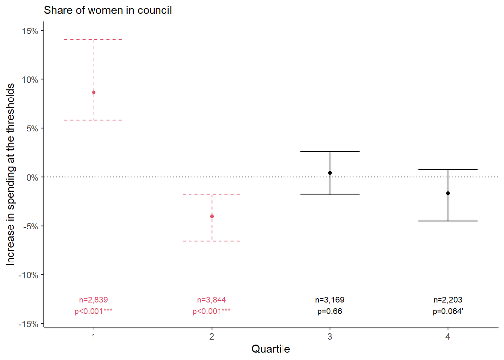

```r
lims <- c(-0.14, 0.145)
rdd_vary_fem_rep <- rdd_vary_fem_rep %>%
  rowwise() %>%
  mutate(note = paste0(
    "n=",
    trimws(format(sum(obs_below, obs_above), big.mark = ",")),
    "\n",
    p_value(p),
    assign_stars(p)
    )) %>%
  ungroup()
df1 <- rdd_vary_fem_rep %>% filter(var == "female_share_council")
df2 <- rdd_vary_fem_rep %>% filter(var == "female_share_largest_party")
p1 <- ggplot2::ggplot(data = df1, aes(x = value, y = point_estimate)) +
  geom_point(size = 1.5, color = ifelse(df1$p <= p_value_cutoff, 2, 1)) +
  geom_errorbar(aes(ymin = ci_lower, ymax = ci_upper),
                color = ifelse(df1$p <= p_value_cutoff, 2, 1),
                linetype = ifelse(df1$p <= p_value_cutoff, 2, 1),
                width = 0.5) +
  geom_hline(aes(yintercept = 0), linetype = "dotted") +
  scale_y_continuous(limits = lims, labels = scales::percent) +
  geom_text(aes(y = -0.14, label = note),
            colour = ifelse(df1$p <= p_value_cutoff, 2, 1), vjust = 0, size = 2.75) +
  labs(subtitle = "Share of women in council",
       x = "Quartile", y = y_lab_RDD)
p1
```

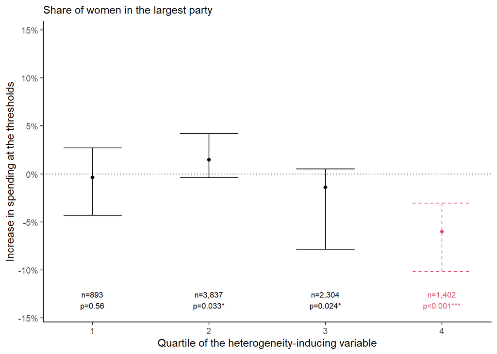

```r
p1 <- p1 + labs(x = NULL, y = NULL)
p2 <- ggplot2::ggplot(data = df2, aes(x = value, y = point_estimate)) +
  geom_point(size = 1.5, color = ifelse(df2$p <= p_value_cutoff, 2, 1)) +
  geom_errorbar(aes(ymin = ci_lower, ymax = ci_upper),
                color = ifelse(df2$p <= p_value_cutoff, 2, 1),
                linetype = ifelse(df2$p <= p_value_cutoff, 2, 1),
                width = 0.5) +
  geom_hline(aes(yintercept = 0), linetype = "dotted") +
  scale_y_continuous(limits = lims, labels = scales::percent) +
  geom_text(aes(y = -0.14, label = note),
            colour = ifelse(df2$p <= p_value_cutoff, 2, 1), vjust = 0, size = 2.75) +
  labs(subtitle = "Share of women in the largest party",
       x = "Quartile of the heterogeneity-inducing variable", y = y_lab_RDD)
p2
```

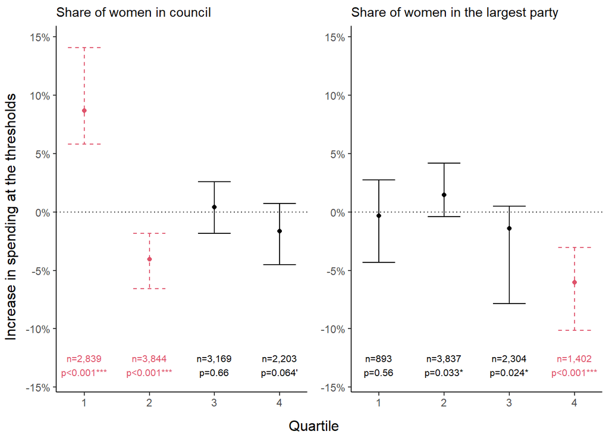

```r
p2 <- p2 + labs(x = NULL, y = NULL)
ggpubr::ggarrange(
  p1,
  p2,
  align = "h",
  ncol = 2,
  nrow = 1
  ) %>%
  annotate_figure(
    left = text_grob(y_lab_RDD, rot = 90),
    bottom = text_grob("Quartile")
    )
```

```r
ggsave(filename = "plots/rdd_council_women.pdf", width = 6, height = 6*9/16)
rm(df1, df2, lims, p1, p2)
```

Hence, run IV interaction:

```r
df <- data %>%
  filter(closest <= 0.1) %>%
  mutate(state = as.factor(state))
rdd <- fixest::feols(ln_gross_expenditure_pc ~
                       1  | # controls
                       inhabitants_treshold_factor + year + state | # fixed-effect controls
                       # First stage regression:
                       inhabs_rel_to_cutoff*total_seats*female_share_council ~
                       inhabs_rel_to_cutoff*above_cutoff*female_share_council,
                     vcov = "threeway",
                     data = df)
```

```
## NOTE: 7,787 observations removed because of NA values (LHS: 2,600, IV: 6,961/6,961).
```

```
## Variance contained negative values in the diagonal and was 'fixed' (a la Cameron, Gelbach & Miller 2011).
```

```r
summary(rdd)
```

```
## TSLS estimation, Dep. Var.: ln_gross_expenditure_pc, Endo.: inhabs_rel_to_cutoff, total_seats, female_share_council, inhabs_rel_to_cutoff:total_seats, inhabs_rel_to_cutoff:female_share_council, total_seats:female_share_council, inhabs_rel_to_cutoff:total_seats:female_share_council, Instr.: inhabs…
## Second stage: Dep. Var.: ln_gross_expenditure_pc
## Observations: 7,777
## Fixed-effects: inhabitants_treshold_factor: 20,  year: 13,  state: 4
## Standard-errors: Clustered (inhabitants_treshold_factor & year & state)
##                                                             Estimate Std. Error
## fit_inhabs_rel_to_cutoff                                  -18.603959  18.367290
## fit_total_seats                                             0.025074   0.021090
## fit_female_share_council                                    2.306924   2.193741
## fit_inhabs_rel_to_cutoff:total_seats                        1.182101   1.191458
## fit_inhabs_rel_to_cutoff:female_share_council             148.748202 129.894714
## fit_total_seats:female_share_council                       -0.156728   0.148119
## fit_inhabs_rel_to_cutoff:total_seats:female_share_council  -8.995784   7.898860
##                                                             t value Pr(>|t|)
## fit_inhabs_rel_to_cutoff                                  -1.012885  0.38571
## fit_total_seats                                            1.188923  0.32000
## fit_female_share_council                                   1.051594  0.37021
## fit_inhabs_rel_to_cutoff:total_seats                       0.992147  0.39426
## fit_inhabs_rel_to_cutoff:female_share_council              1.145144  0.33523
## fit_total_seats:female_share_council                      -1.058122  0.36766
## fit_inhabs_rel_to_cutoff:total_seats:female_share_council -1.138871  0.33747
## ---
## Signif. codes:  0 '***' 0.001 '**' 0.01 '*' 0.05 '.' 0.1 ' ' 1
## RMSE: 0.318695     Adj. R2:  0.112062
##                  Within R2: -0.407567
## F-test (1st stage), inhabs_rel_to_cutoff                                 : stat =     8.007e+31, p < 2.2e-16, on 7 and 7,769 DoF.
## F-test (1st stage), total_seats                                          : stat =   281.1      , p < 2.2e-16, on 7 and 7,769 DoF.
## F-test (1st stage), female_share_council                                 : stat =     5.368e+31, p < 2.2e-16, on 7 and 7,769 DoF.
## F-test (1st stage), inhabs_rel_to_cutoff:total_seats                     : stat = 8,360.6      , p < 2.2e-16, on 7 and 7,769 DoF.
## F-test (1st stage), inhabs_rel_to_cutoff:female_share_council            : stat =     2.248e+31, p < 2.2e-16, on 7 and 7,769 DoF.
## F-test (1st stage), total_seats:female_share_council                     : stat = 5,821.6      , p < 2.2e-16, on 7 and 7,769 DoF.
## F-test (1st stage), inhabs_rel_to_cutoff:total_seats:female_share_council: stat = 6,898.6      , p < 2.2e-16, on 7 and 7,769 DoF.
##                                                                Wu-Hausman: stat =    NA        , p = NA     , on 7 and 7,728 DoF.
```

```r
rdd <- fixest::feols(ln_gross_expenditure_pc ~
                       1  | # controls
                       inhabitants_treshold_factor + year + state | # fixed-effect controls
                       # First stage regression:
                       inhabs_rel_to_cutoff*total_seats*female_share_largest_party ~
                       inhabs_rel_to_cutoff*above_cutoff*female_share_largest_party,
                     vcov = "threeway",
                     data = df)
```

```
## NOTE: 9,663 observations removed because of NA values (LHS: 2,600, IV: 9,662/9,662).
## Variance contained negative values in the diagonal and was 'fixed' (a la Cameron, Gelbach & Miller 2011).
## Variance contained negative values in the diagonal and was 'fixed' (a la Cameron, Gelbach & Miller 2011).
## Variance contained negative values in the diagonal and was 'fixed' (a la Cameron, Gelbach & Miller 2011).
## Variance contained negative values in the diagonal and was 'fixed' (a la Cameron, Gelbach & Miller 2011).
```

```r
summary(rdd)
```

```
## TSLS estimation, Dep. Var.: ln_gross_expenditure_pc, Endo.: inhabs_rel_to_cutoff, total_seats, female_share_largest_party, inhabs_rel_to_cutoff:total_seats, inhabs_rel_to_cutoff:female_share_largest_party, total_seats:female_share_largest_party, inhabs_rel_to_cutoff:total_seats:female_share_large…
## Second stage: Dep. Var.: ln_gross_expenditure_pc
## Observations: 5,901
## Fixed-effects: inhabitants_treshold_factor: 10,  year: 13,  state: 2
## Standard-errors: Clustered (inhabitants_treshold_factor & year & state)
##                                                                  Estimate
## fit_inhabs_rel_to_cutoff                                        -1.076332
## fit_total_seats                                                  0.003945
## fit_female_share_largest_party                                   1.608076
## fit_inhabs_rel_to_cutoff:total_seats                             0.081102
## fit_inhabs_rel_to_cutoff:female_share_largest_party              8.437802
## fit_total_seats:female_share_largest_party                      -0.102148
## fit_inhabs_rel_to_cutoff:total_seats:female_share_largest_party -0.353546
##                                                                 Std. Error
## fit_inhabs_rel_to_cutoff                                         11.173078
## fit_total_seats                                                   0.029240
## fit_female_share_largest_party                                    2.159031
## fit_inhabs_rel_to_cutoff:total_seats                              0.678448
## fit_inhabs_rel_to_cutoff:female_share_largest_party              87.055513
## fit_total_seats:female_share_largest_party                        0.128972
## fit_inhabs_rel_to_cutoff:total_seats:female_share_largest_party   5.003950
##                                                                   t value
## fit_inhabs_rel_to_cutoff                                        -0.096333
## fit_total_seats                                                  0.134906
## fit_female_share_largest_party                                   0.744814
## fit_inhabs_rel_to_cutoff:total_seats                             0.119540
## fit_inhabs_rel_to_cutoff:female_share_largest_party              0.096924
## fit_total_seats:female_share_largest_party                      -0.792021
## fit_inhabs_rel_to_cutoff:total_seats:female_share_largest_party -0.070653
##                                                                 Pr(>|t|)
## fit_inhabs_rel_to_cutoff                                         0.93886
## fit_total_seats                                                  0.91463
## fit_female_share_largest_party                                   0.59245
## fit_inhabs_rel_to_cutoff:total_seats                             0.92426
## fit_inhabs_rel_to_cutoff:female_share_largest_party              0.93849
## fit_total_seats:female_share_largest_party                       0.57356
## fit_inhabs_rel_to_cutoff:total_seats:female_share_largest_party  0.95510
## ---
## Signif. codes:  0 '***' 0.001 '**' 0.01 '*' 0.05 '.' 0.1 ' ' 1
## RMSE: 0.260498     Adj. R2:  0.199251
##                  Within R2: -0.050847
## F-test (1st stage), inhabs_rel_to_cutoff                                       : stat =     2.551e+31, p < 2.2e-16, on 7 and 5,893 DoF.
## F-test (1st stage), total_seats                                                : stat =   268.6      , p < 2.2e-16, on 7 and 5,893 DoF.
## F-test (1st stage), female_share_largest_party                                 : stat =     6.965e+32, p < 2.2e-16, on 7 and 5,893 DoF.
## F-test (1st stage), inhabs_rel_to_cutoff:total_seats                           : stat = 6,350.2      , p < 2.2e-16, on 7 and 5,893 DoF.
## F-test (1st stage), inhabs_rel_to_cutoff:female_share_largest_party            : stat =     2.028e+31, p < 2.2e-16, on 7 and 5,893 DoF.
## F-test (1st stage), total_seats:female_share_largest_party                     : stat = 6,639.3      , p < 2.2e-16, on 7 and 5,893 DoF.
## F-test (1st stage), inhabs_rel_to_cutoff:total_seats:female_share_largest_party: stat = 5,575.8      , p < 2.2e-16, on 7 and 5,893 DoF.
##                                                                      Wu-Hausman: stat =    NA        , p = NA     , on 7 and 5,864 DoF.
```

```r
rm(df, rdd)
```

No effect visible using interaction-term method.

Given the results from the subsample approach, I will also run models nonlinear in the female-representation variables:

```r
df <- data %>%
  filter(closest <= 0.1) %>%
  mutate(state = as.factor(state))
rdd <- fixest::feols(ln_gross_expenditure_pc ~
                       1  | # controls
                       inhabitants_treshold_factor + year + state | # fixed-effect controls
                       # First stage regression:
                       inhabs_rel_to_cutoff*total_seats*poly(female_share_council, 2) ~
                       inhabs_rel_to_cutoff*above_cutoff*poly(female_share_council, 2),
                     vcov = "threeway",
                     data = df)
summary(rdd)
rdd <- fixest::feols(ln_gross_expenditure_pc ~
                       1  | # controls
                       inhabitants_treshold_factor + year + state | # fixed-effect controls
                       # First stage regression:
                       inhabs_rel_to_cutoff*total_seats*poly(female_share_largest_party, 2) ~
                       inhabs_rel_to_cutoff*above_cutoff*poly(female_share_largest_party, 2),
                     vcov = "threeway",
                     data = df)
summary(rdd)
rm(df, rdd)
```

Unfortunately, this does not work because “missing values are not allowed in poly”.

### Bavarian data

```r
data_fem_rep_by <- data_by %>% # prepare data set used for analysis
  select(ln_gross_expenditure_pc, inhabs_rel_to_cutoff, total_seats, inhabitants_treshold_factor,
         state, year, female_share_council, female_share_largest_party) %>%
  mutate(
    # female_share_council = ifelse(female_share_council > mean(data_by$female_share_council),
    #                               1,
    #                               0),
    female_share_council = cut(
      female_share_council,
      breaks = c(quantile(female_share_council, seq(0, 1, 0.25), na.rm = TRUE)),
      labels = FALSE
      ),
    # female_share_largest_party = ifelse(female_share_largest_party >
    #                                       mean(data_by$female_share_largest_party),
    #                                     1,
    #                                     0),
    female_share_largest_party = cut(
      female_share_largest_party,
      breaks = c(quantile(female_share_largest_party, seq(0, 1, 0.25), na.rm = TRUE)),
      labels = FALSE
      )
  ) %>%
  drop_na()
table(data_fem_rep_by$state)
```

```
##
##     9
## 21929
```

```r
all_values <- data_fem_rep %>% distinct(female_share_council) %>% drop_na() %>% pull() # vector of values
rdd_vary_fem_rep_by <- # prepare data set to store the results
  tibble(var = "", value = "", point_estimate = "", se = "", se_robust = "",
         ci_lower = "", ci_upper = "", p = "", bw = "", obs_below = "", obs_above = "") %>%
  mutate(across(2:last_col(), as.numeric))
for (i in c("female_share_council", "female_share_largest_party")) {
  for (j in all_values) {
    print(paste("variable:", i, ", value:", j))
    df <- data_fem_rep_by %>%
      filter(!!rlang::sym(i) == j)
    rdd <-
      rdrobust::rdrobust(
        y = df$ln_gross_expenditure_pc,
        x = df$inhabs_rel_to_cutoff,
        #fuzzy = df$total_seats,
        cluster = df$inhabitants_treshold_factor,
        covs = model.matrix(~ df$inhabitants_treshold_factor + df$year + df$state)
      )
    #summary(rdd)
    rdd_vary_fem_rep_by <- rdd_vary_fem_rep_by %>%
      dplyr::add_row(
        var = i,
        value = j,
        point_estimate = rdd$coef[1],
        se = rdd$se[1],
        se_robust = rdd$se[3],
        ci_lower = rdd$ci[3, 1],
        ci_upper = rdd$ci[3, 2],
        p = rdd$pv[3],
        bw = rdd$bws[1, 1],
        obs_below = rdd$N_h[1],
        obs_above = rdd$N_h[2]
      )
  }
}
```

```
## [1] "variable: female_share_council , value: 4"
## [1] "Mass points detected in the running variable."
## [1] "variable: female_share_council , value: 3"
## [1] "Mass points detected in the running variable."
## [1] "variable: female_share_council , value: 2"
## [1] "Mass points detected in the running variable."
## [1] "variable: female_share_council , value: 1"
## [1] "Mass points detected in the running variable."
## [1] "variable: female_share_largest_party , value: 4"
## [1] "Mass points detected in the running variable."
## [1] "variable: female_share_largest_party , value: 3"
## [1] "Mass points detected in the running variable."
## [1] "variable: female_share_largest_party , value: 2"
## [1] "Mass points detected in the running variable."
## [1] "variable: female_share_largest_party , value: 1"
## [1] "Mass points detected in the running variable."
```

```r
rdd_vary_fem_rep_by <- rdd_vary_fem_rep_by %>% drop_na()
save(rdd_vary_fem_rep_by, file = "tables_robustness_checks/rdrobust_vary_fem_rep_by.Rdata")
rm(df, i, rdd)
```

```r
load(file = "tables_robustness_checks/rdrobust_vary_fem_rep_by.Rdata")
rdd_vary_fem_rep_by
```

| var | value | point_estimate | se | se_robust | ci_lower | ci_upper | p | bw | obs_below | obs_above |
| --- | --- | --- | --- | --- | --- | --- | --- | --- | --- | --- |
| female_share_council | 4 | -0.11287283 | 0.015746083 | 0.017941409 | -0.15689453 | -0.086565497 | 1.161962e-11 | 0.03260188 | 215 | 193 |
| female_share_council | 3 | -0.02869540 | 0.015592470 | 0.019310007 | -0.06586416 | 0.009829678 | 1.468026e-01 | 0.06656763 | 736 | 934 |
| female_share_council | 2 | -0.19341470 | 0.019320358 | 0.019604866 | -0.24748521 | -0.170635542 | 1.504919e-26 | 0.04771454 | 568 | 626 |
| female_share_council | 1 | 0.14372473 | 0.014644311 | 0.016225487 | 0.11144322 | 0.175045961 | 1.062126e-18 | 0.04858018 | 238 | 302 |
| female_share_largest_party | 4 | -0.21098364 | 0.008068117 | 0.009470183 | -0.24107249 | -0.203950052 | 4.483063e-122 | 0.03638570 | 432 | 493 |
| female_share_largest_party | 3 | -0.14371508 | 0.035124203 | 0.036684239 | -0.22544737 | -0.081647798 | 2.843444e-05 | 0.02396040 | 153 | 225 |
| female_share_largest_party | 2 | 0.02040903 | 0.023762505 | 0.021506044 | -0.03332623 | 0.050975909 | 6.815549e-01 | 0.04498833 | 539 | 553 |
| female_share_largest_party | 1 | 0.06602759 | 0.037542431 | 0.040439331 | -0.08723391 | 0.071285359 | 8.436780e-01 | 0.04160461 | 98 | 215 |

[figure not shown]

```r
df <- rdd_vary_fem_rep_by %>% mutate(x = paste(var, value))
ggplot2::ggplot(data = df, aes(x = x, y = point_estimate)) +
  geom_point(size = 1.5, color = ifelse(df$p <= p_value_cutoff, 2, 1)) +
  geom_errorbar(aes(ymin = ci_lower, ymax = ci_upper),
                color = ifelse(df$p <= p_value_cutoff, 2, 1),
                linetype = ifelse(df$p <= p_value_cutoff, 2, 1),
                width = 0.5) +
  geom_hline(aes(yintercept = 0), linetype = "dotted") +
  scale_y_continuous(labels = scales::percent) +
  labs(x = "Year", y = y_lab_RDD)
```

```r
rm(df)
```

Hence, run IV interaction:

```r
df <- data_by %>%
  filter(closest <= 0.1) %>%
  mutate(state = as.factor(state))
rdd <- fixest::feols(ln_gross_expenditure_pc ~
                       1  | # controls
                       inhabitants_treshold_factor + year | # fixed-effect controls
                       # First stage regression:
                       inhabs_rel_to_cutoff*total_seats*female_share_council ~
                       inhabs_rel_to_cutoff*above_cutoff*female_share_council,
                     vcov = "twoway",
                     data = df)
summary(rdd)
```

```
## TSLS estimation, Dep. Var.: ln_gross_expenditure_pc, Endo.: inhabs_rel_to_cutoff, total_seats, female_share_council, inhabs_rel_to_cutoff:total_seats, inhabs_rel_to_cutoff:female_share_council, total_seats:female_share_council, inhabs_rel_to_cutoff:total_seats:female_share_council, Instr.: inhabs…
## Second stage: Dep. Var.: ln_gross_expenditure_pc
## Observations: 2,672
## Fixed-effects: inhabitants_treshold_factor: 9,  year: 13
## Standard-errors: Clustered (inhabitants_treshold_factor & year)
##                                                              Estimate
## fit_inhabs_rel_to_cutoff                                    44.564868
## fit_total_seats                                             -0.010610
## fit_female_share_council                                     1.641816
## fit_inhabs_rel_to_cutoff:total_seats                        -2.732008
## fit_inhabs_rel_to_cutoff:female_share_council             -273.506521
## fit_total_seats:female_share_council                        -0.116157
## fit_inhabs_rel_to_cutoff:total_seats:female_share_council   16.435806
##                                                           Std. Error   t value
## fit_inhabs_rel_to_cutoff                                   43.568104  1.022878
## fit_total_seats                                             0.013242 -0.801259
## fit_female_share_council                                    0.952188  1.724256
## fit_inhabs_rel_to_cutoff:total_seats                        2.530224 -1.079750
## fit_inhabs_rel_to_cutoff:female_share_council             355.044703 -0.770344
## fit_total_seats:female_share_council                        0.069519 -1.670864
## fit_inhabs_rel_to_cutoff:total_seats:female_share_council  19.860006  0.827583
##                                                           Pr(>|t|)
## fit_inhabs_rel_to_cutoff                                   0.33630
## fit_total_seats                                            0.44612
## fit_female_share_council                                   0.12295
## fit_inhabs_rel_to_cutoff:total_seats                       0.31173
## fit_inhabs_rel_to_cutoff:female_share_council              0.46324
## fit_total_seats:female_share_council                       0.13329
## fit_inhabs_rel_to_cutoff:total_seats:female_share_council  0.43190
## ---
## Signif. codes:  0 '***' 0.001 '**' 0.01 '*' 0.05 '.' 0.1 ' ' 1
## RMSE: 0.310061     Adj. R2:  0.019328
##                  Within R2: -0.289667
## F-test (1st stage), inhabs_rel_to_cutoff                                 : stat =     8.691e+30, p < 2.2e-16, on 7 and 2,664 DoF.
## F-test (1st stage), total_seats                                          : stat =   579.8      , p < 2.2e-16, on 7 and 2,664 DoF.
## F-test (1st stage), female_share_council                                 : stat =     7.223e+31, p < 2.2e-16, on 7 and 2,664 DoF.
## F-test (1st stage), inhabs_rel_to_cutoff:total_seats                     : stat = 5,724.2      , p < 2.2e-16, on 7 and 2,664 DoF.
## F-test (1st stage), inhabs_rel_to_cutoff:female_share_council            : stat =     3.038e+30, p < 2.2e-16, on 7 and 2,664 DoF.
## F-test (1st stage), total_seats:female_share_council                     : stat = 3,951.2      , p < 2.2e-16, on 7 and 2,664 DoF.
## F-test (1st stage), inhabs_rel_to_cutoff:total_seats:female_share_council: stat = 4,105.4      , p < 2.2e-16, on 7 and 2,664 DoF.
##                                                                Wu-Hausman: stat =    NA        , p = NA     , on 7 and 2,637 DoF.
```

```r
rm(df, rdd)
```

Here, there is no pattern.

[figure not shown]

```r
quants <- quantile(data_by$female_share_council, c(0.1, 0.9))
ggplot(data = data.frame(x = 0), mapping = aes(x = x)) +
  stat_function(fun = function(x) rdd_fem_rep1$coefficients[2] + rdd_fem_rep1$coefficients[3] + rdd_fem_rep1$coefficients[6] * x) +
  labs(x = "Share of female representatives in council") +
  xlim(quants)
```

```r
rm(quants)
```

To be honest, the interpretation of the y axis is not really clear to me – maybe leave out `fit_female_share_council` (that is `rdd_fem_rep1$coefficients[3]`) of the equation…?

Run the same setting for `female_share_largest_party`:

```r
df <- data_by %>%
  filter(closest <= 0.1) %>%
  mutate(state = as.factor(state))
rdd <- fixest::feols(ln_gross_expenditure_pc ~
                       1  | # controls
                       inhabitants_treshold_factor + year | # fixed-effect controls
                       # First stage regression:
                       inhabs_rel_to_cutoff*total_seats*female_share_largest_party ~
                       inhabs_rel_to_cutoff*above_cutoff*female_share_largest_party,
                     vcov = "twoway",
                     data = df)
summary(rdd)
```

```
## TSLS estimation, Dep. Var.: ln_gross_expenditure_pc, Endo.: inhabs_rel_to_cutoff, total_seats, female_share_largest_party, inhabs_rel_to_cutoff:total_seats, inhabs_rel_to_cutoff:female_share_largest_party, total_seats:female_share_largest_party, inhabs_rel_to_cutoff:total_seats:female_share_large…
## Second stage: Dep. Var.: ln_gross_expenditure_pc
## Observations: 2,672
## Fixed-effects: inhabitants_treshold_factor: 9,  year: 13
## Standard-errors: Clustered (inhabitants_treshold_factor & year)
##                                                                    Estimate
## fit_inhabs_rel_to_cutoff                                          33.231812
## fit_total_seats                                                   -0.000780
## fit_female_share_largest_party                                     1.939730
## fit_inhabs_rel_to_cutoff:total_seats                              -2.191398
## fit_inhabs_rel_to_cutoff:female_share_largest_party             -118.926094
## fit_total_seats:female_share_largest_party                        -0.126554
## fit_inhabs_rel_to_cutoff:total_seats:female_share_largest_party    7.911607
##                                                                 Std. Error
## fit_inhabs_rel_to_cutoff                                         21.202193
## fit_total_seats                                                   0.013523
## fit_female_share_largest_party                                    1.054296
## fit_inhabs_rel_to_cutoff:total_seats                              1.245197
## fit_inhabs_rel_to_cutoff:female_share_largest_party             149.298509
## fit_total_seats:female_share_largest_party                        0.060092
## fit_inhabs_rel_to_cutoff:total_seats:female_share_largest_party   8.136996
##                                                                   t value
## fit_inhabs_rel_to_cutoff                                         1.567376
## fit_total_seats                                                 -0.057683
## fit_female_share_largest_party                                   1.839835
## fit_inhabs_rel_to_cutoff:total_seats                            -1.759881
## fit_inhabs_rel_to_cutoff:female_share_largest_party             -0.796566
## fit_total_seats:female_share_largest_party                      -2.106006
## fit_inhabs_rel_to_cutoff:total_seats:female_share_largest_party  0.972301
##                                                                 Pr(>|t|)
## fit_inhabs_rel_to_cutoff                                        0.155662
## fit_total_seats                                                 0.955416
## fit_female_share_largest_party                                  0.103071
## fit_inhabs_rel_to_cutoff:total_seats                            0.116468
## fit_inhabs_rel_to_cutoff:female_share_largest_party             0.448695
## fit_total_seats:female_share_largest_party                      0.068296 .
## fit_inhabs_rel_to_cutoff:total_seats:female_share_largest_party 0.359378
## ---
## Signif. codes:  0 '***' 0.001 '**' 0.01 '*' 0.05 '.' 0.1 ' ' 1
## RMSE: 0.28901     Adj. R2:  0.147969
##                 Within R2: -0.120495
## F-test (1st stage), inhabs_rel_to_cutoff                                       : stat =     9.368e+30, p < 2.2e-16, on 7 and 2,664 DoF.
## F-test (1st stage), total_seats                                                : stat =   577.1      , p < 2.2e-16, on 7 and 2,664 DoF.
## F-test (1st stage), female_share_largest_party                                 : stat =     2.359e+32, p < 2.2e-16, on 7 and 2,664 DoF.
## F-test (1st stage), inhabs_rel_to_cutoff:total_seats                           : stat = 5,676.5      , p < 2.2e-16, on 7 and 2,664 DoF.
## F-test (1st stage), inhabs_rel_to_cutoff:female_share_largest_party            : stat =     1.953e+31, p < 2.2e-16, on 7 and 2,664 DoF.
## F-test (1st stage), total_seats:female_share_largest_party                     : stat = 4,699.6      , p < 2.2e-16, on 7 and 2,664 DoF.
## F-test (1st stage), inhabs_rel_to_cutoff:total_seats:female_share_largest_party: stat = 3,909.5      , p < 2.2e-16, on 7 and 2,664 DoF.
##                                                                      Wu-Hausman: stat =    NA        , p = NA     , on 7 and 2,637 DoF.
```

```r
rm(df, rdd)
```

Only significant at $\alpha$ = 0.1

# Municipality characteristics

## Size of the municipalities

```r
data_th <- data %>% # prepare data set used for analysis
  select(ln_gross_expenditure_pc, inhabs_rel_to_cutoff, total_seats, inhabitants_treshold_factor, state, year) %>%
  drop_na()
all_th <- data_th %>%
  distinct(inhabitants_treshold_factor) %>%
  filter(!(inhabitants_treshold_factor %in% c("45000", "35000", "60000", "75000", "80000", "150000", "2e+05", "250000", "3e+05", "4e+05", "5e+05", "550000", "7e+05"))) %>%
  pull() # vector of thresholds
rdd_vary_th <- # prepare data set to store the results
  tibble(threshold = "", states = "", point_estimate = "", se = "", se_robust = "",
         ci_lower = "", ci_upper = "", p = "", bw = "", obs_below = "", obs_above = "") %>%
  mutate(across(c(1, 3:last_col()), as.numeric))
for (i in all_th) {
  print(paste("thresholds:", i))
  df <- data_th %>%
    filter(inhabitants_treshold_factor == i)
  states_in_df <- df %>%
    distinct(state) %>%
    mutate(state = case_when(
      state == 1 ~ "SH",
      state == 5 ~ "NW",
      state == 6 ~ "HE",
      state == 7 ~ "RP",
      state == 8 ~ "BW",
      state == 9 ~ "BY",
      state == 10 ~ "SL",
      state == 13 ~ "MV",
      state == 14 ~ "SN",
      state == 15 ~ "ST",
      state == 16 ~ "TH"
    )) %>%
    pull()
  rdd <-
    rdrobust_wrapper(
      ccluster = NULL,
      ccovs = model.matrix( ~ df$year + df$state) # Dropping threshold FE
  )
  #summary(rdd)
  rdd_vary_th <- rdd_vary_th %>%
    dplyr::add_row(
      threshold = as.numeric(i),
      states = paste(states_in_df, collapse = ", "),
      point_estimate = rdd$coef[1],
      se = rdd$se[1],
      se_robust = rdd$se[3],
      ci_lower = rdd$ci[3,1],
      ci_upper = rdd$ci[3,2],
      p = rdd$pv[3],
      bw = rdd$bws[1,1],
      obs_below = rdd$N_h[1],
      obs_above = rdd$N_h[2]
  )
}
```

```
## [1] "thresholds: 5000"
## [1] "Mass points detected in the running variable."
## [1] "thresholds: 200"
## [1] "Mass points detected in the running variable."
## [1] "thresholds: 750"
## [1] "Mass points detected in the running variable."
## [1] "thresholds: 70"
## [1] "Mass points detected in the running variable."
## [1] "thresholds: 15000"
## [1] "Mass points detected in the running variable."
## [1] "thresholds: 1250"
## [1] "Mass points detected in the running variable."
## [1] "thresholds: 2000"
## [1] "Mass points detected in the running variable."
## [1] "thresholds: 25000"
```

[output cut: 27 more lines]

```r
rdd_vary_th <- rdd_vary_th %>% drop_na() %>% arrange(threshold)
save(rdd_vary_th, file = "tables_robustness_checks/rdd_vary_th.Rdata")
rm(all_th, data_th, df, i, rdd, states_in_df)
```

```r
load(file = "tables_robustness_checks/rdd_vary_th.Rdata")
rdd_vary_th
```

| threshold | states | point_estimate | se | se_robust | ci_lower | ci_upper | p | bw | obs_below | obs_above |
| --- | --- | --- | --- | --- | --- | --- | --- | --- | --- | --- |
| 70 | SH | 0.09376540296 | 0.037872732 | 0.043811041 | -0.035382712 | 0.190316814 | 0.077026068393 | 0.09808363 | 30 | 45 |
| 200 | SH | -0.16787783479 | 0.052822024 | 0.060173560 | -0.352604712 | -0.042611074 | 0.001023574647 | 0.07912323 | 165 | 186 |
| 300 | RP | 0.37661200846 | 0.313471656 | 0.322009215 | -0.574449749 | 1.084431798 | 0.428433606989 | 0.06276578 | 464 | 561 |
| 500 | RP, SN, TH | 0.04392356407 | 0.025839039 | 0.026502328 | -0.022548603 | 0.113982341 | 0.084525069204 | 0.07539156 | 1110 | 1113 |
| 750 | SH | 0.02650860989 | 0.022473456 | 0.025007716 | -0.034356742 | 0.094474474 | 0.229369856543 | 0.06571979 | 280 | 270 |
| 1000 | RP, BW, BY, SN, TH | 0.02244019841 | 0.023090658 | 0.024034967 | -0.033507741 | 0.090312205 | 0.237322915854 | 0.06140187 | 1263 | 1289 |
| 1250 | SH | 0.05396131299 | 0.045094517 | 0.060501967 | -0.084415995 | 0.227269486 | 0.237773994168 | 0.05340899 | 75 | 170 |
| 2000 | SH, BW, BY, SN, TH | -0.02442223463 | 0.018668692 | 0.021027663 | -0.080731034 | 0.027596309 | 0.206428164283 | 0.05618338 | 995 | 1205 |
| 2500 | RP | -0.18645371030 | 0.112882691 | 0.115246366 | -0.457913982 | 0.135795953 | 0.162257483702 | 0.03011213 | 102 | 107 |
| 3000 | HE, BW, BY, SN, TH | 0.02218845734 | 0.016028005 | 0.018532334 | -0.030231820 | 0.065240436 | 0.344899908112 | 0.06542172 | 1441 | 1400 |

[output cut: 11 more lines]

Several thresholds, many of them rather large ones, have been dropped as they yield error messages from the `rdrobust` package, potentially owing to too few observations (close to the cutoff).

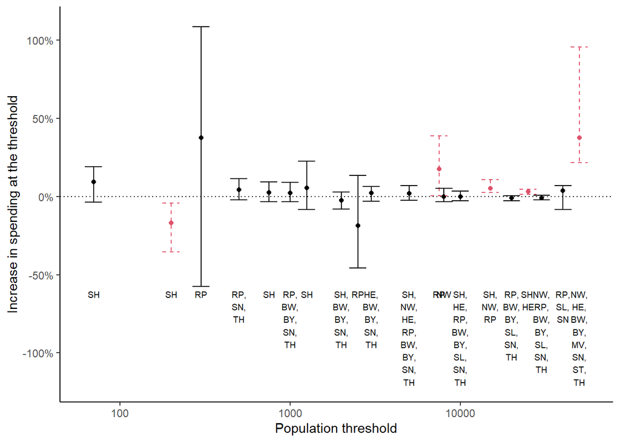

```r
df <- rdd_vary_th %>%
  filter(threshold != 100000) %>%
  mutate(states = gsub(", ", ",\n", states))
ggplot2::ggplot(data = df, aes(x = threshold, y = point_estimate)) +
  geom_point(size = 1.5, color = ifelse(df$p <= p_value_cutoff, 2, 1)) +
  geom_errorbar(aes(ymin = ci_lower, ymax = ci_upper),
                color = ifelse(df$p <= p_value_cutoff, 2, 1),
                linetype = ifelse(df$p <= p_value_cutoff, 2, 1),
                width = 0.1) +
  geom_text(aes(y = -0.6, label = states), size = 2.5, vjust = 1) +
  geom_hline(aes(yintercept = 0), linetype = "dotted") +
  scale_x_log10() +
  scale_y_continuous(limits = c(-1.2, 1.1), labels = scales::percent) +
  labs(x = "Population threshold", y = "Increase in spending at the threshold")
```

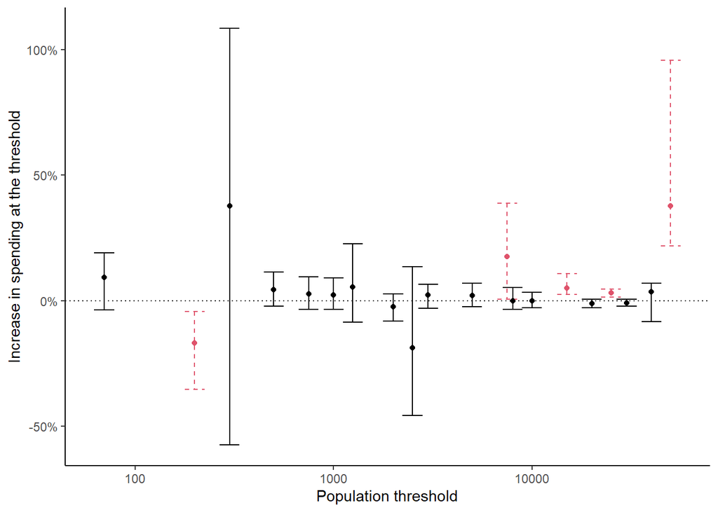

```r
ggplot2::ggplot(data = df, aes(x = threshold, y = point_estimate)) +
  geom_point(size = 1.5, color = ifelse(df$p <= p_value_cutoff, 2, 1)) +
  geom_errorbar(aes(ymin = ci_lower, ymax = ci_upper),
                color = ifelse(df$p <= p_value_cutoff, 2, 1),
                linetype = ifelse(df$p <= p_value_cutoff, 2, 1),
                width = 0.1) +
  geom_hline(aes(yintercept = 0), linetype = "dotted") +
  scale_x_log10() +
  scale_y_continuous(labels = scales::percent) +
  labs(x = "Population threshold", y = "Increase in spending at the threshold")
```

```r
ggsave(filename = "plots/rdd_pop_size.pdf", width = 6, height = 6*9/16)
```

There are not many CI deviating from zero in a statistically significant way. This might also result from pooling several states in many of the cutoffs displayed above.

Run these regressions for each state separately:

```r
# code still needs some work, not ready yet
# to do: remove eval=FALSE
for (j in c(1, 5)) {
  data_th <- data %>% # prepare data set used for analysis
    filter(state == j) %>%
    select(ln_gross_expenditure_pc, inhabs_rel_to_cutoff, total_seats, inhabitants_treshold_factor, state, year) %>%
  drop_na()
all_th <- data_th %>%
  distinct(inhabitants_treshold_factor) %>%
  filter(!(inhabitants_treshold_factor %in% c("45000", "35000", "60000", "75000", "80000", "150000", "2e+05", "250000", "3e+05", "4e+05", "5e+05", "550000", "7e+05"))) %>%
  pull() # vector of thresholds
rdd_vary_th_by_state <- # prepare data set to store the results
  tibble(state = j, threshold = "", point_estimate = "", se = "", se_robust = "",
         ci_lower = "", ci_upper = "", p = "", bw = "", obs_below = "", obs_above = "") %>%
  mutate(across(c(2:last_col()), as.numeric))
for (i in all_th) {
  print(paste("state", j, "thresholds:", i))
  df <- data_th %>%
    filter(inhabitants_treshold_factor == i)
  states_in_df <- df %>% distinct(state) %>% pull()
  rdd <-
    rdrobust_wrapper(
      ccluster = NULL,
      ccovs = model.matrix( ~ df$year + df$state) # Dropping threshold FE
  )
  #summary(rdd)
  rdd_vary_th_by_state <- rdd_vary_th_by_state %>%
    dplyr::add_row(
      state = j,
      threshold = as.numeric(i),
      point_estimate = rdd$coef[1],
      se = rdd$se[1],
      se_robust = rdd$se[3],
      ci_lower = rdd$ci[3,1],
      ci_upper = rdd$ci[3,2],
      p = rdd$pv[3],
      bw = rdd$bws[1,1],
      obs_below = rdd$N_h[1],
      obs_above = rdd$N_h[2]
  )
}
rdd_vary_th_by_state <- rdd_vary_th_by_state %>% drop_na() %>% arrange(threshold)
save(rdd_vary_th_by_state, file = "tables_robustness_checks/rdd_vary_th_by_state.Rdata")
rm(all_th, data_th, df, i, rdd, states_in_df)
}
```

```r
load(file = "tables_robustness_checks/rdd_vary_th_by_state.Rdata")
rdd_vary_th_by_state
```

Interaction-term method using an IV approach with `inhabitants_threshold` included as a factor, not as a numerical variable:

```r
df <- data %>%
  filter(closest <= 0.1)
rdd <- fixest::feols(ln_gross_expenditure_pc ~
                       1  | # controls
                       year + state | # fixed-effect controls
                       # First stage regression:
                       inhabs_rel_to_cutoff*total_seats*inhabitants_treshold_factor ~
                       inhabs_rel_to_cutoff*above_cutoff*inhabitants_treshold_factor,
                     vcov = "twoway",
                     data = df)
```

```
## NOTE: 2,600 observations removed because of NA values (LHS: 2,600).
```

[output not shown]

[output cut: 24 more lines]

[output not shown]

```
## The endogenous regressors 'fit_inhabitants_treshold_factor100', 'fit_inhabitants_treshold_factor700' and 51 others have been removed because of collinearity (see $collin.var).
```

```r
summary(rdd)
```

```
## TSLS estimation, Dep. Var.: ln_gross_expenditure_pc, Endo.: inhabs_rel_to_cutoff, total_seats, inhabitants_treshold_factor, inhabs_rel_to_cutoff:total_seats, inhabs_rel_to_cutoff:inhabitants_treshold_factor, total_seats:inhabitants_treshold_factor, inhabs_rel_to_cutoff:total_seats:inhabitants_tre…
## Second stage: Dep. Var.: ln_gross_expenditure_pc
## Observations: 12,964
## Fixed-effects: year: 13,  state: 10
## Standard-errors: Clustered (year & state)
##                                                                          Estimate
## fit_inhabs_rel_to_cutoff                                                23.112366
## fit_total_seats                                                         -0.090889
## fit_inhabitants_treshold_factor200                                      -0.165342
## fit_inhabitants_treshold_factor300                                      -5.749660
## fit_inhabitants_treshold_factor500                                      -1.150118
## fit_inhabitants_treshold_factor750                                      -0.561874
## fit_inhabitants_treshold_factor1000                                      0.277924
## fit_inhabitants_treshold_factor1250                                     -0.552651
## fit_inhabitants_treshold_factor2000                                      0.551369
## fit_inhabitants_treshold_factor2500                                     -0.419640
## fit_inhabitants_treshold_factor3000                                      0.412934
## fit_inhabitants_treshold_factor5000                                      0.195161
## fit_inhabitants_treshold_factor7500                                     -1.180579
## fit_inhabitants_treshold_factor8000                                     -0.422549
## fit_inhabitants_treshold_factor10000                                     0.720925
## fit_inhabitants_treshold_factor15000                                    -0.846051
## fit_inhabitants_treshold_factor20000                                     0.783108
## fit_inhabitants_treshold_factor25000                                   -10.784745
## fit_inhabitants_treshold_factor30000                                     4.070109
## fit_inhabitants_treshold_factor35000                                     0.428467
## fit_inhabitants_treshold_factor40000                                     0.325033
## fit_inhabitants_treshold_factor50000                                    -9.507528
## fit_inhabitants_treshold_factor60000                                     4.270348
## fit_inhabitants_treshold_factor75000                                     6.018865
## fit_inhabitants_treshold_factor80000                                     2.735307
## fit_inhabitants_treshold_factor1e+05                                     9.145653
## fit_inhabitants_treshold_factor150000                                    2.745928
## fit_inhabitants_treshold_factor2e+05                                     2.434451
## fit_inhabitants_treshold_factor250000                                    1.737983
## fit_inhabitants_treshold_factor4e+05                                     5.087239
## fit_inhabitants_treshold_factor550000                                    5.667795
## fit_inhabs_rel_to_cutoff:total_seats                                    -1.013635
## fit_inhabs_rel_to_cutoff:inhabitants_treshold_factor200                -40.046986
## fit_inhabs_rel_to_cutoff:inhabitants_treshold_factor300                -76.633177
```

[output cut: 651 more lines]

```
## F-test (1st stage), inhabs_rel_to_cutoff:total_seats:inhabitants_treshold_factor50000 : stat =    13,620.1      , p < 2.2e-16, on 100 and 12,863 DoF.
## F-test (1st stage), inhabs_rel_to_cutoff:total_seats:inhabitants_treshold_factor60000 : stat =         4.887e+14, p < 2.2e-16, on 100 and 12,863 DoF.
## F-test (1st stage), inhabs_rel_to_cutoff:total_seats:inhabitants_treshold_factor75000 : stat =         3.198e+28, p < 2.2e-16, on 100 and 12,863 DoF.
## F-test (1st stage), inhabs_rel_to_cutoff:total_seats:inhabitants_treshold_factor80000 : stat =         2.624e+27, p < 2.2e-16, on 100 and 12,863 DoF.
## F-test (1st stage), inhabs_rel_to_cutoff:total_seats:inhabitants_treshold_factor1e+05 : stat =    14,085.0      , p < 2.2e-16, on 100 and 12,863 DoF.
## F-test (1st stage), inhabs_rel_to_cutoff:total_seats:inhabitants_treshold_factor150000: stat =         7.317e+14, p < 2.2e-16, on 100 and 12,863 DoF.
## F-test (1st stage), inhabs_rel_to_cutoff:total_seats:inhabitants_treshold_factor2e+05 : stat =         6.851e+14, p < 2.2e-16, on 100 and 12,863 DoF.
## F-test (1st stage), inhabs_rel_to_cutoff:total_seats:inhabitants_treshold_factor250000: stat =         1.762e+26, p < 2.2e-16, on 100 and 12,863 DoF.
## F-test (1st stage), inhabs_rel_to_cutoff:total_seats:inhabitants_treshold_factor3e+05 : stat =        NA        , p = NA     , on 100 and 12,863 DoF.
## F-test (1st stage), inhabs_rel_to_cutoff:total_seats:inhabitants_treshold_factor4e+05 : stat =         1.919e+27, p < 2.2e-16, on 100 and 12,863 DoF.
## F-test (1st stage), inhabs_rel_to_cutoff:total_seats:inhabitants_treshold_factor5e+05 : stat =        NA        , p = NA     , on 100 and 12,863 DoF.
## F-test (1st stage), inhabs_rel_to_cutoff:total_seats:inhabitants_treshold_factor550000: stat =         6.774e+24, p < 2.2e-16, on 100 and 12,863 DoF.
## F-test (1st stage), inhabs_rel_to_cutoff:total_seats:inhabitants_treshold_factor7e+05 : stat =        NA        , p = NA     , on 100 and 12,863 DoF.
## F-test (1st stage), inhabs_rel_to_cutoff:total_seats:inhabitants_treshold_factor1e+06 : stat =        NA        , p = NA     , on 100 and 12,863 DoF.
##                                                                             Wu-Hausman: stat =        NA        , p = NA     , on 159 and 12,677 DoF.
```

```r
# joint test on interactions
#fixest::wald(rdd, "fit_inhabs_rel_to_cutoff:inhabitants_treshold_factor")
# joint test fails: system is computationally singular
rm(df)
```

`inhabitants_threshold` numerical:

```r
df <- data %>%
  filter(closest <= 0.1)
# With threshold-FE
rdd <- fixest::feols(ln_gross_expenditure_pc ~
                       1  | # controls
                       inhabitants_treshold_factor + year + state | # fixed-effect controls
                       # First stage regression:
                       inhabs_rel_to_cutoff*total_seats*inhabitants_treshold ~
                       inhabs_rel_to_cutoff*above_cutoff*inhabitants_treshold,
                     vcov = "twoway",
                     data = df)
```

```
## NOTE: 2,600 observations removed because of NA values (LHS: 2,600).
```

```r
summary(rdd)
```

```
## TSLS estimation, Dep. Var.: ln_gross_expenditure_pc, Endo.: inhabs_rel_to_cutoff, total_seats, inhabitants_treshold, inhabs_rel_to_cutoff:total_seats, inhabs_rel_to_cutoff:inhabitants_treshold, total_seats:inhabitants_treshold, inhabs_rel_to_cutoff:total_seats:inhabitants_treshold, Instr.: inhabs…
## Second stage: Dep. Var.: ln_gross_expenditure_pc
## Observations: 12,964
## Fixed-effects: inhabitants_treshold_factor: 30,  year: 13,  state: 10
## Standard-errors: Clustered (inhabitants_treshold_factor & year)
##                                                               Estimate
## fit_inhabs_rel_to_cutoff                                  -0.087194219
## fit_total_seats                                            0.014112226
## fit_inhabitants_treshold                                  -0.010373846
## fit_inhabs_rel_to_cutoff:total_seats                      -0.052567054
## fit_inhabs_rel_to_cutoff:inhabitants_treshold              0.000249856
## fit_total_seats:inhabitants_treshold                      -0.000000202
## fit_inhabs_rel_to_cutoff:total_seats:inhabitants_treshold -0.000004628
##                                                               Std. Error
## fit_inhabs_rel_to_cutoff                                    3.8864718249
## fit_total_seats                                             0.0108454790
## fit_inhabitants_treshold                                  217.3296387149
## fit_inhabs_rel_to_cutoff:total_seats                        0.3292978723
## fit_inhabs_rel_to_cutoff:inhabitants_treshold               0.0004560149
## fit_total_seats:inhabitants_treshold                        0.0000000773
## fit_inhabs_rel_to_cutoff:total_seats:inhabitants_treshold   0.0000061360
##                                                             t value Pr(>|t|)
## fit_inhabs_rel_to_cutoff                                  -0.022435 0.982469
## fit_total_seats                                            1.301208 0.217617
## fit_inhabitants_treshold                                  -0.000048 0.999963
## fit_inhabs_rel_to_cutoff:total_seats                      -0.159634 0.875825
## fit_inhabs_rel_to_cutoff:inhabitants_treshold              0.547913 0.593798
## fit_total_seats:inhabitants_treshold                      -2.619309 0.022413
## fit_inhabs_rel_to_cutoff:total_seats:inhabitants_treshold -0.754300 0.465214
##
## fit_inhabs_rel_to_cutoff
## fit_total_seats
## fit_inhabitants_treshold
## fit_inhabs_rel_to_cutoff:total_seats
## fit_inhabs_rel_to_cutoff:inhabitants_treshold
## fit_total_seats:inhabitants_treshold                      *
## fit_inhabs_rel_to_cutoff:total_seats:inhabitants_treshold
## ---
## Signif. codes:  0 '***' 0.001 '**' 0.01 '*' 0.05 '.' 0.1 ' ' 1
## RMSE: 0.294007     Adj. R2:  0.435969
##                  Within R2: -0.004404
## F-test (1st stage), inhabs_rel_to_cutoff                                 : stat =      2.404e+33, p < 2.2e-16, on 7 and 12,947 DoF.
## F-test (1st stage), total_seats                                          : stat =    616.1      , p < 2.2e-16, on 7 and 12,947 DoF.
## F-test (1st stage), inhabitants_treshold                                 : stat =      3.037e+34, p < 2.2e-16, on 7 and 12,947 DoF.
## F-test (1st stage), inhabs_rel_to_cutoff:total_seats                     : stat = 25,676.1      , p < 2.2e-16, on 7 and 12,947 DoF.
## F-test (1st stage), inhabs_rel_to_cutoff:inhabitants_treshold            : stat =      1.235e+33, p < 2.2e-16, on 7 and 12,947 DoF.
## F-test (1st stage), total_seats:inhabitants_treshold                     : stat =    361.6      , p < 2.2e-16, on 7 and 12,947 DoF.
## F-test (1st stage), inhabs_rel_to_cutoff:total_seats:inhabitants_treshold: stat = 22,291.0      , p < 2.2e-16, on 7 and 12,947 DoF.
##                                                                Wu-Hausman: stat =     NA        , p = NA     , on 7 and 12,899 DoF.
```

```r
# Without threshold-FE
rdd <- fixest::feols(ln_gross_expenditure_pc ~
                       1  | # controls
                       year + state | # fixed-effect controls
                       # First stage regression:
                       inhabs_rel_to_cutoff*total_seats*inhabitants_treshold ~
                       inhabs_rel_to_cutoff*above_cutoff*inhabitants_treshold,
                     vcov = "twoway",
                     data = df)
```

```
## NOTE: 2,600 observations removed because of NA values (LHS: 2,600).
```

```r
summary(rdd)
```

```
## TSLS estimation, Dep. Var.: ln_gross_expenditure_pc, Endo.: inhabs_rel_to_cutoff, total_seats, inhabitants_treshold, inhabs_rel_to_cutoff:total_seats, inhabs_rel_to_cutoff:inhabitants_treshold, total_seats:inhabitants_treshold, inhabs_rel_to_cutoff:total_seats:inhabitants_treshold, Instr.: inhabs…
## Second stage: Dep. Var.: ln_gross_expenditure_pc
## Observations: 12,964
## Fixed-effects: year: 13,  state: 10
## Standard-errors: Clustered (year & state)
##                                                               Estimate
## fit_inhabs_rel_to_cutoff                                  -4.972692134
## fit_total_seats                                            0.007612572
## fit_inhabitants_treshold                                  -0.000019382
## fit_inhabs_rel_to_cutoff:total_seats                       0.008775604
## fit_inhabs_rel_to_cutoff:inhabitants_treshold              0.001469715
## fit_total_seats:inhabitants_treshold                       0.000000386
## fit_inhabs_rel_to_cutoff:total_seats:inhabitants_treshold -0.000022149
##                                                            Std. Error   t value
## fit_inhabs_rel_to_cutoff                                  72.08392680 -0.068985
## fit_total_seats                                            0.05388067  0.141286
## fit_inhabitants_treshold                                   0.00032265 -0.060071
## fit_inhabs_rel_to_cutoff:total_seats                       0.91380624  0.009603
## fit_inhabs_rel_to_cutoff:inhabitants_treshold              0.01883259  0.078041
## fit_total_seats:inhabitants_treshold                       0.00000584  0.066060
## fit_inhabs_rel_to_cutoff:total_seats:inhabitants_treshold  0.00028791 -0.076930
##                                                           Pr(>|t|)
## fit_inhabs_rel_to_cutoff                                   0.94651
## fit_total_seats                                            0.89076
## fit_inhabitants_treshold                                   0.95341
## fit_inhabs_rel_to_cutoff:total_seats                       0.99255
## fit_inhabs_rel_to_cutoff:inhabitants_treshold              0.93950
## fit_total_seats:inhabitants_treshold                       0.94877
## fit_inhabs_rel_to_cutoff:total_seats:inhabitants_treshold  0.94036
## ---
## Signif. codes:  0 '***' 0.001 '**' 0.01 '*' 0.05 '.' 0.1 ' ' 1
## RMSE: 0.367068     Adj. R2:  0.122783
##                  Within R2: -0.38226
## F-test (1st stage), inhabs_rel_to_cutoff                                 : stat =      3.18e+32 , p < 2.2e-16, on 7 and 12,956 DoF.
## F-test (1st stage), total_seats                                          : stat =  1,577.6      , p < 2.2e-16, on 7 and 12,956 DoF.
## F-test (1st stage), inhabitants_treshold                                 : stat =      9.551e+31, p < 2.2e-16, on 7 and 12,956 DoF.
## F-test (1st stage), inhabs_rel_to_cutoff:total_seats                     : stat = 13,495.8      , p < 2.2e-16, on 7 and 12,956 DoF.
## F-test (1st stage), inhabs_rel_to_cutoff:inhabitants_treshold            : stat =      7.151e+30, p < 2.2e-16, on 7 and 12,956 DoF.
## F-test (1st stage), total_seats:inhabitants_treshold                     : stat = 47,279.1      , p < 2.2e-16, on 7 and 12,956 DoF.
## F-test (1st stage), inhabs_rel_to_cutoff:total_seats:inhabitants_treshold: stat = 50,929.1      , p < 2.2e-16, on 7 and 12,956 DoF.
##                                                                Wu-Hausman: stat =     NA        , p = NA     , on 7 and 12,928 DoF.
```

```r
rm(df)
```

## “Kreisfreie Städte” vs. not

General remark: The two variables `kreisfreie_stadt` and `stadt` are mutually exclusive. If a city is categorized as an independent large city (`kreisfreie_stadt == 1`), `stadt == 1`. So each town belongs to one of three categories:

- `kreisfreie_stadt = 0` & `stadt = 0` -> “Gemeinde”/municiapality
- `kreisfreie_stadt = 0` & `stadt = 1` -> “kreisangehörige Stadt”/town within a county
- `kreisfreie_stadt = 1` & `stadt = 1` -> “kreisfreie Stadt”/independent large city

```r
data_subset <- data %>% # prepare data set used for analysis
  select(ln_gross_expenditure_pc, inhabs_rel_to_cutoff, total_seats, inhabitants_treshold_factor, state, year, kreisfreie_stadt, stadt, closest, above_cutoff) %>%
  drop_na() %>%
  mutate(
    status = case_when(
      as.numeric(kreisfreie_stadt) == 1 & as.numeric(stadt) == 1 ~ "Municipality",
      as.numeric(kreisfreie_stadt) == 1 & as.numeric(stadt) == 2 ~ "Town",
      as.numeric(kreisfreie_stadt) == 2 & as.numeric(stadt) == 1 ~ "Independent large city"
    )
  )
table(data_subset$state)
```

```
##
##     1     5     6     7     8     9    10    13    14    15    16
## 11274  2772  5536 29821 14305 26702   364    54  4887    28  7875
```

```r
all_values <- data_subset %>% distinct(status) %>% pull() # vector of values
rdd_vary_city <- # prepare data set to store the results
  tibble(status = "", point_estimate = "", se = "", se_robust = "",
         ci_lower = "", ci_upper = "", p = "", bw = "", obs_below = "", obs_above = "") %>%
  mutate(across(2:last_col(), as.numeric))
for (i in all_values) {
  print(paste("status:", i))
  df <- data_subset %>%
    filter(status == i)
  rdd <-
    rdrobust_wrapper(
      ccluster = df$inhabitants_treshold_factor,
      ccovs = model.matrix( ~ df$inhabitants_treshold_factor + df$state) # Dropping year FE
  )
  #summary(rdd)
  rdd_vary_city <- rdd_vary_city %>%
    dplyr::add_row(
      status = i,
      point_estimate = rdd$coef[1],
      se = rdd$se[1],
      se_robust = rdd$se[3],
      ci_lower = rdd$ci[3,1],
      ci_upper = rdd$ci[3,2],
      p = rdd$pv[3],
      bw = rdd$bws[1,1],
      obs_below = rdd$N_h[1],
      obs_above = rdd$N_h[2]
  )
}
rdd_vary_city <- rdd_vary_city %>% drop_na()
save(rdd_vary_city, file = "tables_robustness_checks/rdd_vary_city.Rdata")
rm(all_values, df, i, rdd)
```

```r
load(file = "tables_robustness_checks/rdd_vary_city.Rdata")
rdd_vary_city
```

| status | point_estimate | se | se_robust | ci_lower | ci_upper | p | bw | obs_below | obs_above |
| --- | --- | --- | --- | --- | --- | --- | --- | --- | --- |
| Independent large city | -0.066461142 | 0.04558126 | 0.07928470 | -0.24870487 | 0.15974281 | 0.5747776 | 0.08966112 | 96 | 205 |
| Municipality | -0.001762315 | 0.01115938 | 0.01156912 | -0.03111333 | 0.02848681 | 0.9096229 | 0.05732214 | 6841 | 7380 |
| Town | 0.033987344 | 0.02216137 | 0.02430751 | -0.02410052 | 0.10112349 | 0.1131152 | 0.05963384 | 1518 | 1638 |

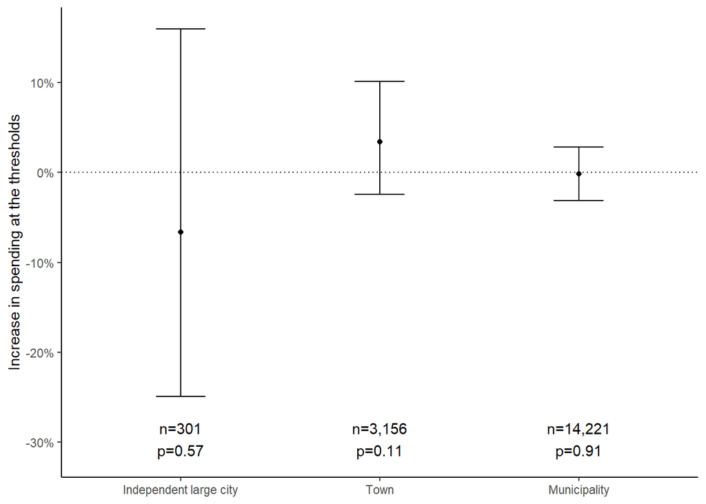

```r
 df <- rdd_vary_city %>%
  rowwise() %>%
  mutate(note = paste0(
    "n=",
    trimws(format(sum(obs_below, obs_above), big.mark = ",")),
    "\n",
    p_value(p),
    assign_stars(p)
    )) %>%
  ungroup()
ggplot2::ggplot(data = df, aes(x = reorder(status, c(1, 3, 2)), y = point_estimate)) +
  geom_point(size = 1.5, color = ifelse(df$p <= p_value_cutoff, 2, 1)) +
  geom_errorbar(aes(ymin = ci_lower, ymax = ci_upper),
                color = ifelse(df$p <= p_value_cutoff, 2, 1),
                linetype = ifelse(df$p <= p_value_cutoff, 2, 1),
                width = 0.25) +
  geom_hline(aes(yintercept = 0), linetype = "dotted") +
  scale_y_continuous(labels = scales::percent) +
  geom_text(aes(y = -0.315, label = note),
            colour = ifelse(df$p <= p_value_cutoff, 2, 1), vjust = 0) +
  labs(x= NULL, y = y_lab_RDD)
```

```r
ggsave(filename = "plots/rdd_cities.pdf", width = 6, height = 6*9/16)
```

No significant effect visible.

```r
df <- data_subset %>% # Use data set from above
  filter(closest <= 0.1)
rdd <- fixest::feols(ln_gross_expenditure_pc ~
                       1  | # controls
                       inhabitants_treshold_factor + state + year | # fixed-effect controls
                       # First stage regression:
                       inhabs_rel_to_cutoff*total_seats*status ~ # Instrument our standard RDD...
                       inhabs_rel_to_cutoff*above_cutoff*status, # ... with being above the cutoff
                     vcov = "threeway",
                     data = df)
```

```
## Variance contained negative values in the diagonal and was 'fixed' (a la Cameron, Gelbach & Miller 2011).
## Variance contained negative values in the diagonal and was 'fixed' (a la Cameron, Gelbach & Miller 2011).
## Variance contained negative values in the diagonal and was 'fixed' (a la Cameron, Gelbach & Miller 2011).
## Variance contained negative values in the diagonal and was 'fixed' (a la Cameron, Gelbach & Miller 2011).
```

```r
summary(rdd)
```

```
## TSLS estimation, Dep. Var.: ln_gross_expenditure_pc, Endo.: inhabs_rel_to_cutoff, total_seats, status, inhabs_rel_to_cutoff:total_seats, inhabs_rel_to_cutoff:status, total_seats:status, inhabs_rel_to_cutoff:total_seats:status, Instr.: inhabs_rel_to_cutoff, above_cutoff, status, inhabs_rel_to_cuto…
## Second stage: Dep. Var.: ln_gross_expenditure_pc
## Observations: 12,964
## Fixed-effects: inhabitants_treshold_factor: 30,  state: 10,  year: 13
## Standard-errors: Clustered (inhabitants_treshold_factor & state & year)
##                                                            Estimate  Std. Error
## fit_inhabs_rel_to_cutoff                                 213.057939  713.537091
## fit_total_seats                                            0.149037    0.421303
## fit_statusMunicipality                                     6.400366   20.548754
## fit_statusTown                                             7.714881   26.023724
## fit_inhabs_rel_to_cutoff:total_seats                      -4.501835   15.019069
## fit_inhabs_rel_to_cutoff:statusMunicipality             -214.006152  712.937073
## fit_inhabs_rel_to_cutoff:statusTown                     -275.206070 1360.257180
## fit_total_seats:statusMunicipality                        -0.135723    0.422681
## fit_total_seats:statusTown                                -0.194531    0.683699
## fit_inhabs_rel_to_cutoff:total_seats:statusMunicipality    4.533552   14.939835
## fit_inhabs_rel_to_cutoff:total_seats:statusTown            7.029197   40.958157
##                                                           t value Pr(>|t|)
## fit_inhabs_rel_to_cutoff                                 0.298594  0.77203
## fit_total_seats                                          0.353754  0.73167
## fit_statusMunicipality                                   0.311472  0.76254
## fit_statusTown                                           0.296456  0.77361
## fit_inhabs_rel_to_cutoff:total_seats                    -0.299741  0.77118
## fit_inhabs_rel_to_cutoff:statusMunicipality             -0.300175  0.77086
## fit_inhabs_rel_to_cutoff:statusTown                     -0.202319  0.84417
## fit_total_seats:statusMunicipality                      -0.321099  0.75547
## fit_total_seats:statusTown                              -0.284527  0.78244
## fit_inhabs_rel_to_cutoff:total_seats:statusMunicipality  0.303454  0.76844
## fit_inhabs_rel_to_cutoff:total_seats:statusTown          0.171619  0.86753
## ---
## Signif. codes:  0 '***' 0.001 '**' 0.01 '*' 0.05 '.' 0.1 ' ' 1
## RMSE: 0.380064     Adj. R2:  0.057165
##                  Within R2: -0.678443
## F-test (1st stage), inhabs_rel_to_cutoff                               : stat =     1.038e+28, p < 2.2e-16, on 11 and 12,952 DoF.
## F-test (1st stage), total_seats                                        : stat =   390.6      , p < 2.2e-16, on 11 and 12,952 DoF.
## F-test (1st stage), statusMunicipality                                 : stat =     2.036e+28, p < 2.2e-16, on 11 and 12,952 DoF.
## F-test (1st stage), statusTown                                         : stat =     3.126e+28, p < 2.2e-16, on 11 and 12,952 DoF.
## F-test (1st stage), inhabs_rel_to_cutoff:total_seats                   : stat = 8,662.1      , p < 2.2e-16, on 11 and 12,952 DoF.
## F-test (1st stage), inhabs_rel_to_cutoff:statusMunicipality            : stat =     1.603e+28, p < 2.2e-16, on 11 and 12,952 DoF.
## F-test (1st stage), inhabs_rel_to_cutoff:statusTown                    : stat =     3.367e+28, p < 2.2e-16, on 11 and 12,952 DoF.
## F-test (1st stage), total_seats:statusMunicipality                     : stat = 7,575.6      , p < 2.2e-16, on 11 and 12,952 DoF.
## F-test (1st stage), total_seats:statusTown                             : stat = 9,257.2      , p < 2.2e-16, on 11 and 12,952 DoF.
## F-test (1st stage), inhabs_rel_to_cutoff:total_seats:statusMunicipality: stat = 7,986.6      , p < 2.2e-16, on 11 and 12,952 DoF.
## F-test (1st stage), inhabs_rel_to_cutoff:total_seats:statusTown        : stat = 8,531.4      , p < 2.2e-16, on 11 and 12,952 DoF.
##                                                              Wu-Hausman: stat =    NA        , p = NA     , on 11 and 12,891 DoF.
```

```r
# joint test on interactions
fixest::wald(rdd, "fit_total_seats:status")
```

```
## Wald test, H0: joint nullity of fit_total_seats:statusMunicipality and fit_total_seats:statusTown
##  stat = 0.061818, p-value = 0.940054, on 2 and 12,902 DoF, VCOV: Clustered (inhabitants_treshold_factor & state & year).
```

```r
rm(data_subset, df, rdd)
```

Extremely high p value for the joint test: No significant differences from baseline (independent large cities).

# Concluding Remarks

For references, see the paper.

```r
Sys.time() - time
```

```
## Time difference of 19.98017 mins
```